# 公开心电图数据库诊断标签的准确性验证与标签噪声对 AI 诊断模型训练的传导效应

基于 MIMIC、宁波与 PTB-XL 共 2196 例专家审阅的跨库再分析（v1.0）

Published

September 10, 2026

**展开代码**

```r
set.seed(20260910)
knitr::opts_chunk$set(
  warning = FALSE, message = FALSE,
  dev = "ragg_png", dpi = 300, fig.align = "center", out.width = "100%"
)
suppressPackageStartupMessages({
  library(tidyverse); library(openxlsx); library(jsonlite)
  library(ggplot2); library(patchwork); library(scales)
  library(flextable); library(gt)
})

FONT <- "PingFang SC"
theme_set(
  theme_minimal(base_family = FONT) +
    theme(
      plot.title    = element_text(face = "bold", size = 14, family = FONT),
      plot.subtitle = element_text(size = 10.5, color = "#555555", family = FONT),
      plot.caption  = element_text(size = 8.5, color = "#777777", family = FONT,
                                  hjust = 0, margin = margin(t = 6)),
      strip.text    = element_text(face = "bold", family = FONT),
      axis.text     = element_text(family = FONT),
      legend.text   = element_text(family = FONT),
      legend.title  = element_text(family = FONT),
      panel.grid.minor = element_blank()
    )
)
C_ACC  <- "#0072B2"; C_INA <- "#D55E00"; C_OK <- "#009E73"
C_WARN <- "#E69F00"; C_PNK <- "#CC79A7"; C_GRY <- "#999999"; C_SKY <- "#56B4E9"

wilson_ci <- function(x, n, conf = 0.95) {
  if (is.na(n) || n <= 0) return(c(NA_real_, NA_real_))
  z <- qnorm(1 - (1 - conf) / 2); p <- x / n
  den <- 1 + z^2 / n; cen <- p + z^2 / (2 * n)
  half <- z * sqrt(p * (1 - p) / n + z^2 / (4 * n^2))
  c(max(0, (cen - half) / den), min(1, (cen + half) / den))
}
beta_mom <- function(x, n) {
  keep <- n > 0; x <- x[keep]; n <- n[keep]
  r <- x / n; w <- n
  m  <- weighted.mean(r, w)
  v  <- weighted.mean((r - m)^2, w)
  sv <- weighted.mean(r * (1 - r) / n, w)
  v2 <- max(v - sv, 1e-4)
  k  <- max(m * (1 - m) / v2 - 1, 0.1)
  c(alpha = unname(m * k), beta = unname((1 - m) * k))
}
fpct <- function(x, d = 1) ifelse(is.na(x), "不适用", percent(x, accuracy = 10^(-d)))
fci  <- function(lo, hi, d = 1) ifelse(is.na(lo), "不适用",
                                       paste0(fpct(lo, d), " 至 ", fpct(hi, d)))
fmt3 <- function(x) sprintf("%.3f", x)

qfp_of <- function(pi, qfn, fdr) {
  if ((1 - pi) < 1e-9) return(0)
  fdr * pi * (1 - qfn) / ((1 - pi) * (1 - fdr))
}
auc_binormal <- function(se, sp) pnorm((qnorm(se) + qnorm(sp)) / sqrt(2))
ppv_of <- function(se, sp, pi) se * pi / (se * pi + (1 - sp) * (1 - pi))
npv_of <- function(se, sp, pi) sp * (1 - pi) / (sp * (1 - pi) + (1 - se) * pi)
f1_of  <- function(se, sp, pi) { p <- ppv_of(se, sp, pi); 2 * p * se / (p + se) }
all_metrics <- function(se, sp, pi) {
  tibble(Se = se, Sp = sp, PPV = ppv_of(se, sp, pi), NPV = npv_of(se, sp, pi),
         F1 = f1_of(se, sp, pi), AUC = auc_binormal(se, sp))
}
attenuation_of <- function(se_app, sp_app, pi, qfn, fdr) {
  qfp <- qfp_of(pi, qfn, fdr)
  se_true <- se_app * (1 - qfn) + (1 - sp_app) * qfn
  sp_true <- sp_app * (1 - qfp) + (1 - se_app) * qfp
  pi_app  <- pi * (1 - qfn) + (1 - pi) * qfp
  app <- all_metrics(se_app, sp_app, pi_app)
  tru <- all_metrics(se_true, sp_true, pi)
  att <- tibble(
    Se = se_app - se_true, Sp = sp_app - sp_true,
    PPV = app$PPV - tru$PPV, NPV = app$NPV - tru$NPV,
    F1  = app$F1  - tru$F1,  AUC = app$AUC - tru$AUC)
  list(app = app, tru = tru, att = att,
       se_true = se_true, sp_true = sp_true, pi_app = pi_app, qfp = qfp)
}
ceil_true <- function(pi, qfn, fdr) {
  qfp <- qfp_of(pi, qfn, fdr)
  c(se = 1 - qfn, sp = 1 - qfp, auc = auc_binormal(1 - qfn, 1 - qfp))
}
ft <- function(x, fs = 9) {
  flextable(x) |> fontsize(size = fs, part = "all") |>
    font(fontname = "PingFang SC", part = "all") |>
    bold(bold = TRUE, part = "header") |>
    align(align = "center", part = "header") |>
    theme_booktabs() |>
    bg(bg = "#F2F2F2", part = "header") |>
    autofit()
}

# 表格题注：加阴影、加粗、深色，便于在三线表上方形成明显视觉锚点
cap <- function(text) {
  sprintf(
    '<p style="margin: 1.2em 0 0.5em 0; font-weight: 700; font-size: 1.02em; color: #1A1A1A; text-shadow: 1.5px 1.5px 3px rgba(0,0,0,0.25);"><strong>%s</strong></p>\n\n',
    text)
}

# ---- 抽样代表性表（表 A1–A3）通用构建器 ----
rep_ft <- function(d, tint, lw = 3.5) {
  Ns <- attr(d, "Ns"); Na <- attr(d, "Na"); n <- nrow(d)
  tt <- tibble::tibble(
    排名        = c(as.character(d$排名), ""),
    诊断标签    = c(d$labc, "记录总数（分母）"),
    抽样例数    = c(fmt_int(d$n_sample),  fmt_int(Ns)),
    抽样构成比  = c(fmt_p1(d$p_s),        "100.0%"),
    整体例数    = c(fmt_int(d$n_overall), fmt_int(Na)),
    整体构成比  = c(fmt_p1(d$p_a),        "100.0%"),
    差值        = c(fmt_pp(d$dpp),        "—"),
    标准化差值  = c(fmt_sd(abs(d$sdd)),   "—"))
  b <- ft(tt, fs = 8) |>
    add_header_row(
      values = c("", "", sprintf("抽样样本 (n=%s)", fmt_int(Ns)),
                 sprintf("整体数据库 (N=%s)", fmt_int(Na)), "差值 (百分点)", "标准化差值"),
      colwidths = c(1, 1, 2, 2, 1, 1), top = TRUE) |>
    width(j = 1, width = 0.45) |> width(j = 2, width = lw) |>
    width(j = 3, width = 0.85) |> width(j = 4, width = 0.90) |>
    width(j = 5, width = 0.95) |> width(j = 6, width = 0.95) |>
    width(j = 7, width = 0.85) |> width(j = 8, width = 0.80) |>
    bg(j = 3:4, bg = tint, part = "body") |>
    bg(j = 5:6, bg = "#F2F5F7", part = "body") |>
    bg(part = "header", bg = "#DCE6F1") |>
    bold(part = "header") |>
    align(align = "center", part = "header") |>
    align(j = 1, align = "center", part = "body") |>
    align(j = 2, align = "left",   part = "body") |>
    align(j = 3:8, align = "right", part = "body") |>
    valign(valign = "center", part = "all") |>
    fontsize(size = 8, part = "all") |>
    bold(i = n + 1, part = "body") |>
    border(i = n + 1, border.top = officer::fp_border(color = "#333333", width = 1.2), part = "body")
  for (k in seq_len(n)) {
    b <- color(b, i = k, j = 7,
      color = if (abs(d$dpp[k]) < 1) "#1A1A1A" else if (abs(d$dpp[k]) < 3) "#B26B00" else "#B02020")
  }
  b
}
```

**展开代码**

```r
# ============ 数据载入（最新 2026-08-28 三库） ============
BASE <- "../../01_数据/专家审阅/2026-08整理后数据"
NB <- read.xlsx(file.path(BASE, "宁波完整心电图2026-08-28.xlsx"), sheet = 1)
PT <- read.xlsx(file.path(BASE, "PTBXL 合并2026-08-28_去annotator8.xlsx"), sheet = 1)
MC <- read.xlsx(file.path(BASE, "MIMIC 合并2026-08-28.xlsx"), sheet = 1)
pt_json <- fromJSON("./PTB-XL分析/ptbxl_data.json")
mc_json <- fromJSON("./MIMIC分析/mimic_analysis.json")
# MIMIC 逐诊断概念四格表（方案 A：39 项受控词表关键词命中 + 否定语境过滤，
# 由 MIMIC分析/mimic_per_dx.py 预计算，与宁波/PTB-XL 落在同一概念集上）
mc_dx <- fromJSON("./MIMIC分析/mimic_per_dx.json")

# ---- 抽样代表性：抽样样本 vs 整体数据库 逐标签构成（由 prep_sampling_composition.py 预计算） ----
rep_json <- fromJSON("./sampling_composition.json")
fmt_int <- function(x) formatC(as.numeric(x), format = "d", big.mark = ",")
fmt_p1  <- function(x) sprintf("%.1f%%", as.numeric(x) * 100)
fmt_pp  <- function(x) sprintf("%+.1f", as.numeric(x))
fmt_sd  <- function(x) sprintf("%.3f", as.numeric(x))
# 两比例标准化差值（Table-1 均衡性判据，|d|<0.10 视为均衡）
sd_pair <- function(p1, p2) {
  den <- sqrt((p1 * (1 - p1) + p2 * (1 - p2)) / 2)
  ifelse(is.na(den) | den < 1e-12, 0, (p1 - p2) / den)
}
rep_data <- function(db) {
  v <- rep_json[[db]]; Ns <- as.numeric(v$N_sample); Na <- as.numeric(v$N_overall)
  d <- as_tibble(v$rows) |>
    mutate(n_sample = as.numeric(n_sample), n_overall = as.numeric(n_overall),
           label = as.character(label), en = as.character(en), ab = as.character(ab)) |>
    arrange(desc(n_sample), desc(n_overall)) |>
    mutate(排名 = row_number(), p_s = n_sample / Ns, p_a = n_overall / Na,
           dpp = (p_s - p_a) * 100, sdd = sd_pair(p_s, p_a))
  zh <- if (db == "ningbo") d$label else d$en
  d$labc <- ifelse(is.na(zh) | zh == "" | zh == d$ab, d$ab, paste0(d$ab, " (", zh, ")"))
  attr(d, "Ns") <- Ns; attr(d, "Na") <- Na
  d
}
rep_nb <- rep_data("ningbo"); rep_pt <- rep_data("ptbxl"); rep_mc <- rep_data("mimic")
rep_sum <- function(d) {
  Ns <- attr(d, "Ns"); Na <- attr(d, "Na")
  c(n_lab = nrow(d), Ns = Ns, Na = Na,
    max_pp = max(abs(d$dpp)), med_sd = median(abs(d$sdd)), max_sd = max(abs(d$sdd)),
    pct_bal = mean(abs(d$sdd) < 0.10) * 100)
}
rep_nb_s <- rep_sum(rep_nb); rep_pt_s <- rep_sum(rep_pt); rep_mc_s <- rep_sum(rep_mc)

# ---- 库级计数 ----
nb_cc <- NB$conclusionChoice
nb_acc <- sum(nb_cc == "准确", na.rm = TRUE); nb_ina <- sum(nb_cc == "不准确", na.rm = TRUE)
nb_und <- sum(is.na(nb_cc)); nb_n <- nrow(NB)
pt_cc <- PT$conclusionChoice
pt_acc <- sum(pt_cc == "准确", na.rm = TRUE); pt_ina <- sum(pt_cc == "不准确", na.rm = TRUE)
pt_und <- sum(is.na(pt_cc)); pt_n <- nrow(PT)
mc_cc <- MC$conclusionChoice
mc_acc <- sum(mc_cc == "准确", na.rm = TRUE); mc_ina <- sum(mc_cc == "不准确", na.rm = TRUE)
mc_und <- sum(is.na(mc_cc)); mc_n <- nrow(MC)

lib_sum <- tibble(
  数据库 = c("MIMIC", "宁波单中心", "PTB-XL"),
  总例数 = c(mc_n, nb_n, pt_n),
  准确 = c(mc_acc, nb_acc, pt_acc),
  不准确 = c(mc_ina, nb_ina, pt_ina),
  未判定 = c(mc_und, nb_und, pt_und),
  有效例数 = c(mc_n - mc_und, nb_n - nb_und, pt_n - pt_und)
) |> mutate(
    准确率 = 准确 / 有效例数, 不准确率 = 不准确 / 有效例数,
    ci_lo = map2_dbl(准确, 有效例数, ~ wilson_ci(.x, .y)[1]),
    ci_hi = map2_dbl(准确, 有效例数, ~ wilson_ci(.x, .y)[2]),
    ci_lo_ina = map2_dbl(不准确, 有效例数, ~ wilson_ci(.x, .y)[1]),
    ci_hi_ina = map2_dbl(不准确, 有效例数, ~ wilson_ci(.x, .y)[2])
  )
ov <- lib_sum |> mutate(数据库 = factor(数据库, levels = c("MIMIC","宁波单中心","PTB-XL")), 不准确率_p = 不准确率)

# ============ 宁波逐诊断单元 四格表（最新 623 例，全判） ============
vocab_raw <- read.xlsx(
  "../../01_数据/专家审阅/宁波518份心电图/宁波合并_v3_三字段468例_AFL口径_20260721.xlsx",
  sheet = "词汇映射表")
abbr_ref_col <- grep("对应缩写", names(vocab_raw), value = TRUE)[1]
stopifnot(nrow(vocab_raw) == 39, !anyDuplicated(vocab_raw$中文标签))
lab_all  <- vocab_raw$中文标签
lab2cat  <- setNames(vocab_raw$所属分类, vocab_raw$中文标签)
lab2en   <- setNames(vocab_raw$英文标签, vocab_raw$中文标签)

split_cn <- function(s) map(str_split(s, ","), ~ .x[!is.na(.x) & .x != "NA" & .x != ""])
df_nb <- NB |> mutate(db_set = split_cn(diagnose_chinese_names),
  accurate = case_when(conclusionChoice == "准确" ~ 1L, conclusionChoice == "不准确" ~ 0L, TRUE ~ NA_integer_))

fw2hw <- function(s) {
  vapply(s, function(x) {
    i <- utf8ToInt(x)
    i <- ifelse(i >= 0xFF01 & i <= 0xFF5E, i - 0xFEE0, i)
    i <- ifelse(i == 0x3000, 0x20, i); intToUtf8(i)
  }, character(1))
}
normalize_phrase <- function(x) {
  x <- fw2hw(x); x <- str_replace_all(x, "[\\s，。、；：]", "")
  x <- str_replace_all(x, "ptfV1", "PtfV1")
  rec <- c("胸导联R波递增不良" = "胸导联R波上升不良", "胸导R波上升不良" = "胸导联R波上升不良",
           "胸导R波递增不良" = "胸导联R波上升不良", "肢体导联低电压" = "肢导联低电压", "ST改变" = "ST段改变")
  ifelse(x %in% names(rec), unname(rec[x]), x)
}
syn_dict <- tribble(
  ~phrase, ~target,
  "心电轴左偏", "轴向左移", "心电轴右偏", "轴向右移", "房性期前收缩", "房性早搏", "室性期前收缩", "室性早搏",
  "完全性右束支传导阻滞", "右束支阻滞", "不完全性右束支传导阻滞", "右束支阻滞", "非典型右束支传导阻滞", "右束支阻滞",
  "ST段改变", "ST-T改变", "P波异常", "P波改变", "二度I型房室传导阻滞", "二度房室传导阻滞（一型）",
  "短阵房性心动过速", "房性心动过速", "左后分支阻滞", "左后束支传导阻滞", "交界性逸搏心律", "交接区逸搏",
  "全导联低电压", "全导联低电压QRS", "窦性心动过缓伴不齐", "窦性心动过缓+窦性心律不齐",
  "房性心动过速偶伴室内差异性传导", "房性心动过速+室内差异传导", "房性期前收缩伴室内差异性传导", "房性早搏+室内差异传导")
map_one <- function(p) {
  if (p %in% lab_all) return(list(type = "词汇表直配", targets = p))
  if (p %in% syn_dict$phrase) {
    v <- syn_dict$target[match(p, syn_dict$phrase)]
    return(list(type = "同义词典", targets = str_split(v, "\\+")[[1]]))
  }
  if (p == "正常心电图") return(list(type = "特殊标签NORM", targets = "NORM"))
  list(type = "OOV", targets = character(0))
}
phrases_long <- df_nb |> filter(conclusionChoice == "不准确") |> select(id, correctLabel) |>
  mutate(raw = str_split(correctLabel, "\r\n|\n")) |> unnest(raw) |>
  mutate(raw = str_trim(raw)) |> filter(raw != "") |> mutate(norm = normalize_phrase(raw))
phrase_map <- tibble(norm = unique(phrases_long$norm)) |> mutate(
  res = map(norm, map_one), map_type = map_chr(res, "type"), targets = map(res, "targets")) |> select(-res)
phrases_long <- phrases_long |> left_join(phrase_map, by = "norm") |>
  mutate(exp_label = pmap(list(map_type, norm, targets),
        function(tp, nm, tg) if (tp == "OOV") nm else tg))
expert_by_case <- phrases_long |> group_by(id) |> summarise(
  expert_full = list(unique(unlist(exp_label))),
  expert_lab  = list(unique(intersect(unlist(targets), lab_all))), .groups = "drop")
df_nb <- df_nb |> left_join(expert_by_case, by = "id")
for (i in seq_len(nrow(df_nb))) {
  if (is.na(df_nb$accurate[i])) { df_nb$expert_full[i] <- list(NULL); df_nb$expert_lab[i] <- list(NULL) }
  else if (df_nb$accurate[i] == 1L) { df_nb$expert_full[[i]] <- df_nb$db_set[[i]]; df_nb$expert_lab[[i]] <- df_nb$db_set[[i]] }
}
ana_nb <- df_nb |> filter(!is.na(accurate)); n_main_nb <- nrow(ana_nb)
```

```r
in_db_mat <- map(lab_all, function(a) map_lgl(ana_nb$db_set, ~ a %in% .x))
in_ex_mat <- map(lab_all, function(a) map_lgl(ana_nb$expert_lab, ~ a %in% .x))
l2_nb <- map_dfr(seq_along(lab_all), function(j) {
  a <- lab_all[j]; d <- in_db_mat[[j]]; e <- in_ex_mat[[j]]
  TP <- sum(d & e); FP <- sum(d & !e); FN <- sum(!d & e); TN <- sum(!d & !e)
  tibble(unit = a, n_db = TP + FP, n_exp = TP + FN, TP = TP, FP = FP, FN = FN, TN = TN)
}) |> mutate(
  ppv = TP / (TP + FP), sens = TP / (TP + FN), spec = TN / (TN + FP), npv = TN / (TN + FN),
  qfn = FN / (TP + FN), fdr = FP / (TP + FP),
  label_en = unname(lab2en[unit]), cat = unname(lab2cat[unit]))

# ============ Goldman Class I–IV 临床严重性分级（宁波 623 例） ============
gclass <- c(
  "三度房室传导阻滞"="I","预激综合征"="I","异常Q波"="I","侧壁心肌梗死"="I",
  "ST段抬高"="I","ST段压低"="I","心房颤动"="I","心房扑动"="I","QT间期延长"="I",
  "左心室肥厚"="II","房性心动过速"="II","室上性心动过速"="II","房室传导阻滞"="II",
  "二度房室传导阻滞（一型）"="II",
  "窦性心动过缓"="III","T波改变"="III","窦性心动过速"="III","T波倒置"="III",
  "全导联低电压QRS"="III","轴向左移"="III","房性早搏"="III","ST段延长"="III",
  "轴向右移"="III","右束支阻滞"="III","左后束支传导阻滞"="III","室内差异传导"="III",
  "U波"="III","一度房室传导阻滞"="III","室性融合波"="III","PR间期延长"="III",
  "P波改变"="III","交接区逸搏"="III","室性早搏"="III","ST-T改变"="III",
  "窦性心律"="IV","窦性心律不齐"="IV","室壁早期复极化"="IV","逆时针旋转"="IV","顺时针旋转"="IV")
stopifnot(setequal(names(gclass), lab_all), length(gclass)==39)
l2_nb <- l2_nb |> mutate(Goldman = unname(gclass[unit]))
sev_idx <- c("I"=4,"II"=3,"III"=2,"IV"=1)

# 诊断单元级：按 Goldman 分级聚合 FN（遗漏事件）/FP（误标事件）/错误事件
gold_unit_nb <- l2_nb |> group_by(Goldman) |> summarise(
  诊断数 = n(), FN = sum(FN), FP = sum(FP), `错误事件` = sum(FN+FP)) |>
  mutate(占比 = `错误事件`/sum(`错误事件`)) |> arrange(Goldman)
gold_unit_nb_tot <- sum(gold_unit_nb$`错误事件`)
gold_unit_nb_maj <- sum(gold_unit_nb$`错误事件`[gold_unit_nb$Goldman %in% c("I","II")])
gold_unit_nb_I  <- gold_unit_nb$`错误事件`[gold_unit_nb$Goldman=="I"]
gold_unit_nb_fp_I <- gold_unit_nb$FP[gold_unit_nb$Goldman=="I"]
gold_unit_nb_fn_I <- gold_unit_nb$FN[gold_unit_nb$Goldman=="I"]

# 病例级：按涉及诊断（漏标集 ∪ 误标集）的临床最严重一级分级
case_sev <- ana_nb |> mutate(
  involved = map2(db_set, expert_lab, ~ union(.x, .y)),
  cls = map_chr(involved, ~ {
    cs <- .x[.x %in% lab_all]
    if(length(cs)==0) NA_character_ else { idx <- sev_idx[gclass[cs]]; names(sev_idx)[which.max(idx)] }
  }))
gold_case_nb <- case_sev |> filter(accurate==0) |> count(cls, name="例数") |>
  mutate(分级 = ifelse(is.na(cls), "未分级(OOV)", paste0("Class ", cls))) |> arrange(cls)
gold_case_nb_tot <- sum(gold_case_nb$例数)
gold_case_nb_maj <- sum(gold_case_nb$例数[gold_case_nb$cls %in% c("I","II")], na.rm=TRUE)
gold_unit_nb_III <- gold_unit_nb$`错误事件`[gold_unit_nb$Goldman=="III"]
gold_case_nb_min <- gold_case_nb_tot - gold_case_nb_maj

TPs <- sum(l2_nb$TP); FPs <- sum(l2_nb$FP); FNs <- sum(l2_nb$FN); TNs <- sum(l2_nb$TN)
pr_err <- beta_mom(l2_nb$FP, l2_nb$TP + l2_nb$FP)
pr_mis <- beta_mom(l2_nb$FN[l2_nb$n_exp > 0], l2_nb$n_exp[l2_nb$n_exp > 0])
qfn_nb <- unname((pr_mis["alpha"] + FNs) / (pr_mis["alpha"] + pr_mis["beta"] + TPs + FNs))
fdr_nb <- unname((pr_err["alpha"] + FPs) / (pr_err["alpha"] + pr_err["beta"] + TPs + FPs))

# ============ PTB-XL / MIMIC 术语级 ============
pt_per <- pt_json$per_dx |> mutate(
  code = as.character(code), cn = as.character(cn),
  qfn = as.numeric(qfn), fdr = as.numeric(fdr), se = as.numeric(se), sp = as.numeric(sp),
  n_db = as.numeric(n_db), tp = as.numeric(tp), fp = as.numeric(fp), fn = as.numeric(fn), tn = as.numeric(tn)) |>
  filter(!is.na(qfn)) |> arrange(desc(qfn))
mc_term <- mc_json$stats$term_accuracy |> mutate(
  term = as.character(term), n = as.numeric(n), acc = as.numeric(acc), ina = as.numeric(ina)) |>
  mutate(ina_rate = ina / n) |> arrange(desc(ina_rate))

# ---- MIMIC 逐诊断概念四格表（方案 A：39 项受控词表关键词命中）----
mc_per <- mc_dx$per_concept |> mutate(
  concept_zh = as.character(concept_zh), concept_en = as.character(concept_en),
  tp = as.numeric(tp), fp = as.numeric(fp), fn = as.numeric(fn), tn = as.numeric(tn),
  qfn = as.numeric(qfn), fdr = as.numeric(fdr),
  n_orig = as.numeric(n_orig), n_true = as.numeric(n_true)) |>
  filter(n_orig + n_true > 0) |> arrange(desc(qfn))
MC_SUP <- 15   # 支撑阈值：分母 < 15 的概念不进逐标签图表，避免小样本极端值
mc_tp <- as.numeric(mc_dx$overall$tp); mc_fp <- as.numeric(mc_dx$overall$fp)
mc_fn <- as.numeric(mc_dx$overall$fn); mc_tn <- as.numeric(mc_dx$overall$tn)
mc_qfn_agg <- mc_fn / (mc_tp + mc_fn)
mc_fdr_agg <- mc_fp / (mc_tp + mc_fp)
mc_ncon    <- as.numeric(mc_dx$meta$n_concepts_present)
stopifnot(nrow(mc_per) == mc_ncon)
pta <- pt_json$aggregate
pt_qfn <- as.numeric(pta$qfn); pt_fdr <- as.numeric(pta$fdr)

# ============ 跨库命名空间对照表 ============
vb <- mc_json$compare$vocab |> mutate(
  concept_en = as.character(concept_en), concept_zh = as.character(concept_zh),
  ningbo = as.numeric(ningbo), ptbxl = as.numeric(ptbxl),
  mimic_en = as.numeric(mimic_en), mimic_zh = as.numeric(mimic_zh),
  expert_supplemented = as.character(expert_supplemented))
vb_tbl <- vb |> mutate(
  概念 = paste0(concept_en, " (", concept_zh, ")"), 宁波_n = ningbo, PTBXL_n = ptbxl,
  MIMIC_en_n = mimic_en, MIMIC_zh_n = mimic_zh,
  专家补充 = ifelse(grepl("是", expert_supplemented), "是", "否")) |>
  select(概念, 宁波_n, PTBXL_n, MIMIC_en_n, MIMIC_zh_n, 专家补充)
cw <- pt_json$vocab_compare$crosswalk |> mutate(
  概念 = as.character(概念), 宁波术语 = as.character(宁波术语), 宁波OOV = as.logical(宁波OOV),
  `PTB-XL码` = as.character(`PTB-XL码`), `PTB-XL无此码` = as.logical(`PTB-XL无此码`), 说明 = as.character(说明))
cw_tbl <- cw |> mutate(宁波OOV = ifelse(宁波OOV, "是", "否"), `PTB-XL无此码` = ifelse(`PTB-XL无此码`, "是", "否")) |>
  select(概念, 宁波术语, `PTB-XL码`, 宁波OOV, `PTB-XL无此码`, 说明)

# ============ Goldman Class I–IV 临床严重性分级（PTB-XL，经概念对照表映射 SCP 码） ============
# 经概念对照表（pt_json$vocab_compare$crosswalk）将 40 个 SCP 码映射至宁波受控术语 → gclass：
#   Tier 1（对照表宁波术语落入 39 项受控词表者）直接取 gclass；
#   MI 亚码（ALMI/ILMI/IPLMI/IPMI）与 ISC*/INJ* 亚码按对照表概念归类（心肌梗死 / 心肌缺血）取顶格 gclass；
#   Tier 2（对照表宁波侧 OOV 的临床概念：AMI/LAO/RAO-RAE/SEHYP/PACE/DIG/EL/BIGU）按同等严重性原理拟定外推，标注 外推。
scp_gclass <- c(
  AFIB="I", AFLT="I", ASMI="I", AVB1="III", CRBBB="III", IRBBB="III",
  CLBBB="III", IVCD="III", LAFB="III", LMI="I", LNGQT="I", LPFB="III",
  LVH="II", NDT="III", NORM="IV", NST="I", PSVT="II", PVC="III", WPW="I", IMI="I",
  ALMI="I", ILMI="I", IPLMI="I", IPMI="I",
  ISC="I", ISCAL="I", ISCAS="I", ISCIL="I", ISCIN="I", ISCLA="I", INJAL="I", INJAS="I",
  AMI="I", LAO="III", `RAO/RAE`="III", SEHYP="II", PACE="IV", DIG="III", EL="III", BIGU="III")
scp_tier2 <- c("AMI","LAO","RAO/RAE","SEHYP","PACE","DIG","EL","BIGU","CLBBB","IVCD","LAFB")
stopifnot(all(pt_per$code %in% names(scp_gclass)),
          all(scp_gclass %in% c("I","II","III","IV")))
pt_per <- pt_per |> mutate(Goldman = unname(scp_gclass[code]), 外推 = code %in% scp_tier2)
```

```r
gold_unit_pt <- pt_per |> group_by(Goldman) |> summarise(
  诊断码数 = n(), FN = sum(fn, na.rm=TRUE), FP = sum(fp, na.rm=TRUE), `错误事件` = sum(fn+fp, na.rm=TRUE)) |>
  mutate(占比 = `错误事件`/sum(`错误事件`)) |> arrange(Goldman)
gold_unit_pt_tot   <- sum(gold_unit_pt$`错误事件`)
gold_unit_pt_maj   <- sum(gold_unit_pt$`错误事件`[gold_unit_pt$Goldman %in% c("I","II")])
gold_unit_pt_I     <- gold_unit_pt$`错误事件`[gold_unit_pt$Goldman=="I"]
gold_unit_pt_IV    <- gold_unit_pt$`错误事件`[gold_unit_pt$Goldman=="IV"]
gold_unit_pt_fn_I  <- gold_unit_pt$FN[gold_unit_pt$Goldman=="I"]
gold_unit_pt_fp_I  <- gold_unit_pt$FP[gold_unit_pt$Goldman=="I"]
gold_unit_pt_major_rate <- gold_unit_pt_maj / gold_unit_pt_tot
gold_unit_pt_t2    <- sum((pt_per |> filter(code %in% scp_tier2) |> pull(fn)) +
                          (pt_per |> filter(code %in% scp_tier2) |> pull(fp)), na.rm = TRUE)

# 跨库单元级对比（宁波 vs PTB-XL）
gold_x <- full_join(
    gold_unit_nb |> select(Goldman, `宁波错误事件`=`错误事件`),
    gold_unit_pt |> select(Goldman, `PTB-XL错误事件`=`错误事件`),
    by = "Goldman") |>
  mutate(宁波错误事件   = ifelse(is.na(宁波错误事件), 0, 宁波错误事件),
         `PTB-XL错误事件` = ifelse(is.na(`PTB-XL错误事件`), 0, `PTB-XL错误事件`),
         宁波占比   = 宁波错误事件/sum(宁波错误事件),
         `PTB-XL占比` = `PTB-XL错误事件`/sum(`PTB-XL错误事件`)) |>
  arrange(Goldman)

cov_long <- vb |> select(concept_en, concept_zh, ningbo, ptbxl, mimic_zh) |>
  pivot_longer(cols = c(ningbo, ptbxl, mimic_zh), names_to = "库", values_to = "n") |>
  mutate(库 = recode(库, ningbo = "宁波", ptbxl = "PTB-XL", mimic_zh = "MIMIC"),
         概念 = paste0(concept_en, " (", concept_zh, ")"))
top_concepts <- cov_long |> group_by(概念) |> summarise(mx = max(n), .groups = "drop") |>
  slice_max(mx, n = 5) |> arrange(mx) |> pull(概念)
cov_top <- cov_long |> filter(概念 %in% top_concepts) |>
  mutate(概念 = factor(概念, levels = top_concepts),
         库 = factor(库, levels = c("MIMIC","PTB-XL","宁波")))

# ============ 库级真实指标 ============
nb_real <- tibble(数据库 = "宁波", Se = TPs/(TPs+FNs), Sp = TNs/(TNs+FPs),
  PPV = TPs/(TPs+FPs), NPV = TNs/(TNs+FNs), qfn = qfn_nb, fdr = fdr_nb)
pt_real <- tibble(数据库 = "PTB-XL", Se = as.numeric(pta$sens_true), Sp = as.numeric(pta$spec_true),
  PPV = as.numeric(pta$label_accuracy), NPV = as.numeric(pta$tn)/(as.numeric(pta$tn)+as.numeric(pta$fn)),
  qfn = pt_qfn, fdr = pt_fdr)
mc_real <- tibble(数据库 = "MIMIC",
  Se = mc_tp / (mc_tp + mc_fn), Sp = mc_tn / (mc_tn + mc_fp),
  PPV = mc_tp / (mc_tp + mc_fp), NPV = mc_tn / (mc_tn + mc_fn),
  qfn = mc_qfn_agg, fdr = mc_fdr_agg,
  准确率 = mc_json$stats$label$acc / mc_n)
real_all <- bind_rows(nb_real, pt_real, mc_real)

# ============ 训练端前推：账面模型衰减 ============
nb_hl  <- attenuation_of(0.80, 0.80, 0.15, qfn_nb, fdr_nb)
pt_hl  <- attenuation_of(0.80, 0.80, 0.15, pt_qfn, pt_fdr)
mc_hl  <- attenuation_of(0.80, 0.80, 0.15, mc_qfn_agg, mc_fdr_agg)
nb_ceil <- ceil_true(0.15, qfn_nb, fdr_nb)
pt_ceil <- ceil_true(0.15, pt_qfn, pt_fdr)
mc_ceil <- ceil_true(0.15, mc_qfn_agg, mc_fdr_agg)
att_tbl <- bind_rows(
  tibble(数据库 = "宁波", 指标 = c("Se","Sp","PPV","NPV","F1","AUC"),
    `账面` = c(nb_hl$app$Se, nb_hl$app$Sp, nb_hl$app$PPV, nb_hl$app$NPV, nb_hl$app$F1, nb_hl$app$AUC),
    `真实` = c(nb_hl$tru$Se, nb_hl$tru$Sp, nb_hl$tru$PPV, nb_hl$tru$NPV, nb_hl$tru$F1, nb_hl$tru$AUC)),
  tibble(数据库 = "PTB-XL", 指标 = c("Se","Sp","PPV","NPV","F1","AUC"),
    `账面` = c(pt_hl$app$Se, pt_hl$app$Sp, pt_hl$app$PPV, pt_hl$app$NPV, pt_hl$app$F1, pt_hl$app$AUC),
    `真实` = c(pt_hl$tru$Se, pt_hl$tru$Sp, pt_hl$tru$PPV, pt_hl$tru$NPV, pt_hl$tru$F1, pt_hl$tru$AUC)),
  tibble(数据库 = "MIMIC", 指标 = c("Se","Sp","PPV","NPV","F1","AUC"),
    `账面` = c(mc_hl$app$Se, mc_hl$app$Sp, mc_hl$app$PPV, mc_hl$app$NPV, mc_hl$app$F1, mc_hl$app$AUC),
    `真实` = c(mc_hl$tru$Se, mc_hl$tru$Sp, mc_hl$tru$PPV, mc_hl$tru$NPV, mc_hl$tru$F1, mc_hl$tru$AUC))
) |> mutate(衰减 = `账面` - `真实`)
att_long <- att_tbl |> pivot_longer(cols = c(`账面`, `真实`), names_to = "口径", values_to = "值") |>
  mutate(值 = as.numeric(值), 口径 = factor(口径, levels = c("账面","真实")),
         指标 = factor(指标, levels = c("Se","Sp","PPV","NPV","F1","AUC")))
```

# 摘要

**背景**：公开心电图（ECG）数据库多依赖机器初判或医师批量标注生成诊断标签，标签噪声会沿”用含噪标签训练、模型复刻噪声、用真金标准验证”的链路向 AI 模型性能传导。既往研究多孤立评估单一数据库，缺乏跨库统一本体下的量化比较。

**目的**：以最新（2026-08 整理）的 MIMIC、宁波单中心、PTB-XL 三库共 2196 例专家审阅数据为真金标准，跨库统一诊断命名空间，量化各库标签的账面（含噪）与真实（专家校正）质量，并推演标签噪声对下游 AI 诊断模型训练指标的掺水效应。

**方法**：三库分别经专家审阅，对每张 ECG 图形与 AI 翻译的中文文本判定诊断标签准确性并补充正确诊断。建立概念级对照本体，将各库异源命名空间对齐到统一概念。对每个诊断单元构建”数据库标签 D × 专家金标准 G”的 四格表，由此导出遗漏率（qfn）、误标率（fdr）与真实灵敏度/特异度/PPV/NPV。MIMIC 的原始标签为自由文本报告，先经 39 项受控词表关键词命中（含否定语境过滤）转换为概念级存在性判断，再同法构建四格表，使三库落在同一概念集上可比。采用训练端前推框架，由账面指标与噪声参数推演含噪标签训练的模型在真金标准下的指标衰减。

**结论**：公开 ECG 数据库的标签噪声普遍且结构性地高估 AI 模型性能；跨库诊断命名空间不统一是噪声的重要来源。标签质量审计应作为医学 AI 立项与注册的强制前置环节，并优先治理遗漏型噪声与命名空间错位。

# 1 资料与方法

## 1.1 数据来源与专家审阅流程

本研究整合三个公开或半公开 ECG 数据库的最新专家审阅数据集（均整理于 2026-08）：

三库审阅流程一致：专家同时看到 ECG 图形与 AI 翻译的中文文本，用中文判定标签准确性并补充诊断名称。

## 1.2 跨库诊断命名空间对齐

各库原始诊断命名空间基于不同的编码标准，需先厘清其本体来源：(1) **MIMIC** 为机器生成的英文自由文本 ECG 报告（`report`/`report_cn`，如 GE Marquette 12SL 自动报告输出），不含结构化诊断编码；(2) **宁波单中心**为 39 项中文受控词表（`diagnose_chinese_names`/`diagnose_english_names`/`diagnose_categories`，含中文标签、英文标签与临床缩写），源自中文临床 ECG 术语习惯，并非 SNOMED-CT 或 SCP-ECG 标准编码；(3) **PTB-XL** 以 **SCP-ECG 诊断语句**编码（71 个标准 SCP-ECG 语句，存于 `SCP_en_cn`），并可经官方映射表（ptbxlToSNOMED.csv）回溯至 **SNOMED-CT**，是三库中唯一具备 SNOMED-CT 标准连接的库。换言之：PTB-XL 同时具备 SCP-ECG（原生）与 SNOMED-CT（派生映射）两套编码；宁波与 MIMIC 则分别依赖受控中文词表与自由文本，均不原生采用 SNOMED 或 SCP。本研究建立概念级对照本体，将各库标签映射到统一诊断概念（英文(中文)），区分三类情形：可对齐概念、仅在单库受控词表中出现之概念、以及专家审阅中新补充的词汇（expert-supplemented）。命名空间错位的标志是某概念在一库有受控码、在另一库落 OOV（数据库无法编码）。

## 1.3 病例级别与标签级别准确性分析方法

专家审阅为每个病例给出一个总体准确性判定（准确/不准确），并据此在两个层级上量化标签准确性。

**病例级别准确性（case-level accuracy）**：以单份心电图为单位，由专家判定该病例的标签集合整体是否准确。判定为不准确的病例进一步标注错误性质，分为两类。其一为遗漏型（omission，即假阴性 FN），指数据库标签集合漏写了专家认定的真实诊断，由专家在 `correctLabel` 中补充，也称漏标。其二为误标型（commission，即假阳性 FP），指数据库标签集合写入了专家认定的错误诊断，由专家在 `correctLabel` 中标注并纠正，也称误标。病例级别准确性同时以三库对照方式横向比较，分别报告 MIMIC、宁波、PTB-XL 各自的准确例数占比与错误性质构成。

**标签级别准确性（label-level accuracy）**：以单个诊断术语为单位，在所有出现该诊断的病例上计算微平均准确率（micro-accuracy），即被正确标注的比例：真阳性 /（真阳性 + 假阳性 + 假阴性）。标签级别分析揭示哪些具体诊断概念最易被漏写或误写，是病例级别判定的精细化展开。

**临床严重性分级（Goldman Class I–IV）**：病例级别错误并非同质。一份被判定不准确的 ECG 报告，其临床后果可能天差地别，例如漏标心房颤动（可致血栓栓塞性卒中）与漏标窦性心律（无独立临床意义）不可等同视之。本研究引入 Goldman 等建立的”诊断差异严重性分级”（diagnostic discrepancy severity grading）对标签错误进行临床分级。该框架最初由 Goldman 等（1983）在尸体解剖对照研究中提出，用于评价临床诊断与尸检金标准之间的差异严重程度，后被 Battle 等（1987）及多项医学错误研究沿用为通用方法。

该框架将”数据库标签与专家金标准之间的每一条诊断差异”归入四级：

- **Class I（重大差异，major；若被识别很可能改变预后或存活）**：遗漏或误标了若被及时识别则很可能改变患者结局乃至存活的诊断。在原研究中典型情形为遗漏了与死亡直接相关的可治疗主要诊断。映射到 ECG 标签，对应于遗漏或误标具有急性致死或血栓栓塞风险的核心诊断，包括三度房室传导阻滞、预激综合征、异常 Q 波（心肌梗死）、侧壁心肌梗死、ST 段抬高、ST 段压低、心房颤动、心房扑动、QT 间期延长。
- **Class II（重大差异，major；但不太可能单独改变结局）**：临床上重大、但及时识别后不太可能单独改变存活的诊断。映射到 ECG，包括左心室肥厚、房性心动过速、室上性心动过速、房室传导阻滞、二度房室传导阻滞（一型）。
- **Class III（次要差异，minor）**：遗漏了临床意义有限的次要诊断。映射到 ECG，包括各类传导变异与复极改变，如窦性心动过缓/过速、T 波改变/倒置、电轴偏移、早搏、束支阻滞、P 波改变等。
- **Class IV（偶发或术语差异，incidental）**：不涉及实质性临床误判，仅为术语或定义层面的差异，或本就无独立临床意义的正常变异。映射到 ECG，包括窦性心律、窦性心律不齐、室壁早期复极化、顺/逆时针旋转。

**应用方式**：第一，将 39 个受控诊断术语按上述标准预先归入 Class I–IV（术语级映射见结果 4.1）。第二，对每一份不准确病例，分别识别其”漏标术语集合”与”误标术语集合”，取二者并集后取所涉及的临床最严重一级，作为该病例的严重性分级，即一例报告只要涉及任一 Class I 错误即归为 Class I（顶格取值）。第三，在单元级与病例级两个层面汇总：单元级报告各 Class 下的 FN（遗漏事件数）、FP（误标事件数）与合计错误事件数；病例级报告各 Class 的病例数。**核心报告指标为”重大差异率”（major discrepancy rate）= Class I + Class II 合计占比**，该指标在医学错误文献中作为诊断/标签质量的主要严重度度量。本研究的术语级 Class 映射为基于临床后果严重度的拟定划分，需经临床专家确认。同一镜头亦平行应用于 PTB-XL：将其 40 个 SCP 码经 §5 的概念对照表映射至宁波受控术语并继承 gclass，心肌梗死与心肌缺血亚码按对照表概念归类、宁波侧 OOV 的临床概念按同等严重性原理拟定外推；病例级顶格取值因 PTB-XL 源数据未提供逐例漏标/误标集合而未纳入，仅以诊断单元级为准（详见 §4.1）。

**错误分类学统计（error taxonomy）**：对不准确病例的偏差类型建立 10 类分类体系（类型 01 核心心律失常诊断错误或缺失、类型 02 传导阻滞细化补充等），按含记录与纯记录分别计数，刻画错误的结构化分布。

**噪声类型分解（noise-type decomposition）**：将标签噪声分解为随机双向噪声（漏写与误标并存）、仅漏写单向噪声（仅 FN）、仅误标单向噪声（仅 FP）。漏写主要压低灵敏度与 NPV，误标主要压低特异度与 PPV，由此定位各诊断单元的噪声起源。

## 1.4 由账面数据推导真金标准数据的分析方法

对每个诊断单元 t，定义两套参考集：账面集 D(t) 为数据库标签所断言含该诊断的病例集合，金标准集 G(t) 为专家校正后含该诊断的病例集合。二者构成 四格表：

D⁺G⁺ = TP，D⁺G⁻ = FP（误标/commission），D⁻G⁺ = FN（遗漏/omission），D⁻G⁻ = TN

由此导出的真实（金标准视角）指标为：

Se_金标准(t) = TP / (TP + FN) = 1 − λ(t)，其中 λ(t) = |D⁻G⁺| / |G(t)|（遗漏率）

Sp_金标准(t) = TN / (TN + FP) = 1 − μ(t)，其中 μ(t) = |D⁺G⁻| / |G⁻(t)|（误标率）

PPV、NPV 同理由 四格表直接计算。跨全部诊断单元汇总即得库级标签质量。

**三库标签的概念化处理**：宁波的账面集 D(t) 直接取自中文受控诊断字段；PTB-XL 取自 SCP 主诊断码， 并经 §5 的概念对照表映射到同一受控概念；MIMIC 的账面标签为自由文本报告，需先做概念化。 对 39 项受控概念逐一预先建立中英文检索词清单，英文检索 `report`、中文检索 `report_cn`， 任一侧出现非否定命中即判为该概念存在，并对命中位置施加否定语境窗口过滤： 英文在命中词前 28 字符窗口内出现 no / not / without / ruled out / unlikely 等线索即视为未命中； 中文在前 6 字符窗口内出现「未见」「无明显」「无异常」「不除外」「排除」「否认」「可疑」等表述即视为未命中， 其中单字否定「无」「不」「否」仅在紧贴关键词前 3 字内生效，以降低误判。 金标准集 G(t) 的构造为：审阅判定为准确的病例取其账面概念集，判定为不准确的病例取专家 `correctLabel` 的概念命中集。 该处理使三库落在同一 39 项概念集上可比，代价是 MIMIC 的四格表属受控词表视角的近似估计： 分母为受控概念的命中数而非结构化码的使用次数，落在受控词表之外的自由文本表述不计入， 因此其 qfn/fdr 与另两库量级可比，但不宜逐位小数比较。

## 1.5 训练端前推与指标衰减

在”模型仅学习脏标签 D、与真实病情 E 条件独立（M⊥E|D）“的保守假设下，由账面指标（Se_app、Sp_app）与噪声参数（qfn、fdr）前推真金标准指标：

Se_true = Se_app·(1−qfn) + (1−Sp_app)·qfn

Sp_true = Sp_app·(1−qfp) + (1−Se_app)·qfp，其中 qfp = fdr·π·(1−qfn)/[(1−π)·(1−fdr)]

衰减 = 账面 − 真实（正值表示账面掺水）。采用 Beta-Binomial 后验（矩估计锚定）做不确定性传播。

概念示意图 · 标签噪声向模型性能的传导链路

1

账面训练标签

三库原始机器标签，自带漏标率 qfn 与误标率 fdr（噪声）。

宁波 PTB-XL MIMIC

→

2

专家金标准审计

2196 例双盲审阅，逐诊断单元量化漏标与误标。

qfn 漏标率 fdr 误标率

→

3

训练端前推

用前推公式把账面指标"翻译"成真金标准下的真实指标。

Se_true = Se_app·(1−qfn)  
+ (1−Sp_app)·qfn

→

4

真实模型性能

真实灵敏与特异显著低于账面，性能被悄悄"掺水"。

账面

0.80

真实

0.62

性能虚高 Δ（账面−真实）

账面 AUC≈0.80 在真金标准下被掺水，真实 AUC 随噪声升高而下降（本示意示例降至约 0.78）。

+0.18

示意：以示例噪声水平（qfn=30%、fdr=20%、π=15%）为例，账面灵敏 0.80 在真金标准下约降至 0.62。各库实际衰减随其噪声参数而异，可拖动下方「交互式前推算盘」实时复现，定量结果另见 §6 与附录图 A2。

## 1.6 统计软件与模型

分析采用 R 4.4 与 Python 3；R 包包括 tidyverse、openxlsx、ggplot2、patchwork、flextable、gt。区间估计采用 Wilson 95% 置信区间；噪声参数采用 Beta 矩估计；指标衰减采用训练端前推解析公式与贝叶斯后验抽样。报告框架对齐 STARD-AI 与 TRIPOD+AI 双清单。

# 2 抽样代表性：抽样样本与整体数据库的诊断标签构成比较（结果 1）

专家审阅只能覆盖抽样子集，抽样是否保持原数据库的诊断构成，决定后文噪声估计能否外推至该库整体。本节逐标签比较三库抽样样本与整体数据库的构成。例数为「含该标签的记录数」，构成比的分母分别为该库的抽样记录数与整体记录数；因一份记录可同时携带多个标签，各行构成比之和大于 100%。差值列为抽样构成比减整体构成比的百分点差；标准化差值按 $(p_1-p_2)/\sqrt{[p_1(1-p_1)+p_2(1-p_2)]/2}$ 计算，绝对值小于 0.10 视为均衡。标签按抽样例数由多到少排列。

**表 A1. 宁波数据库：抽样样本（n = 623）与整体数据库（N = 45,152）逐诊断标签构成比较。 例数＝含该标签的记录数；构成比＝例数／该库记录总数（一份记录可携带多个标签，故各行构成比之和大于 100%）。差值＝抽样构成比减整体构成比（百分点）；标准化差值绝对值小于 0.10 视为均衡。诊断标签列格式为「英文缩写（中文）」。**

| 排名 | 诊断标签 | 抽样样本 (n=623) 抽样例数 | 抽样样本 (n=623) 抽样构成比 | 整体数据库 (N=45,152) 整体例数 | 整体数据库 (N=45,152) 整体构成比 | 差值 (百分点) 差值 | 标准化差值 |
| --- | --- | --- | --- | --- | --- | --- | --- |
| 1 | SB (窦性心动过缓) | 217 | 34.8% | 16,559 | 36.7% | -1.8 | 0.038 |
| 2 | TWC (T波改变) | 131 | 21.0% | 7,043 | 15.6% | +5.4 | 0.141 |
| 3 | AFL (心房扑动) | 117 | 18.8% | 8,060 | 17.9% | +0.9 | 0.024 |
| 4 | SR (窦性心律) | 105 | 16.9% | 8,125 | 18.0% | -1.1 | 0.030 |
| 5 | ST (窦性心动过速) | 102 | 16.4% | 7,255 | 16.1% | +0.3 | 0.008 |
| 6 | TWO (T波倒置) | 57 | 9.1% | 2,877 | 6.4% | +2.8 | 0.104 |
| 7 | SA (窦性心律不齐) | 41 | 6.6% | 2,550 | 5.6% | +0.9 | 0.039 |
| 8 | AFIB (心房颤动) | 33 | 5.3% | 1,780 | 3.9% | +1.4 | 0.065 |
| 9 | ALS (轴向左移) | 31 | 5.0% | 1,545 | 3.4% | +1.6 | 0.078 |
| 10 | STDD (ST段压低) | 28 | 4.5% | 1,668 | 3.7% | +0.8 | 0.040 |
| 11 | APB (房性早搏) | 25 | 4.0% | 1,312 | 2.9% | +1.1 | 0.061 |
| 12 | 1AVB (一度房室传导阻滞) | 23 | 3.7% | 1,140 | 2.5% | +1.2 | 0.067 |
| 13 | LVQRSAL (全导联低电压QRS) | 23 | 3.7% | 1,043 | 2.3% | +1.4 | 0.081 |
| 14 | AQW (异常Q波) | 22 | 3.5% | 1,063 | 2.4% | +1.2 | 0.070 |
| 15 | STTC (ST-T改变) | 20 | 3.2% | 1,158 | 2.6% | +0.6 | 0.039 |
| 16 | IDC (室内差异传导) | 18 | 2.9% | 771 | 1.7% | +1.2 | 0.079 |
| 17 | ARS (轴向右移) | 17 | 2.7% | 853 | 1.9% | +0.8 | 0.056 |
| 18 | STE (ST段延长) | 17 | 2.7% | 801 | 1.8% | +1.0 | 0.064 |
| 19 | QTIE (QT间期延长) | 15 | 2.4% | 394 | 0.9% | +1.5 | 0.121 |
| 20 | SVT (室上性心动过速) | 14 | 2.2% | 724 | 1.6% | +0.6 | 0.047 |
| 21 | LVH (左心室肥厚) | 12 | 1.9% | 647 | 1.4% | +0.5 | 0.038 |
| 22 | RBBB (右束支阻滞) | 10 | 1.6% | 649 | 1.4% | +0.2 | 0.014 |
| 23 | ERV (室壁早期复极化) | 7 | 1.1% | 366 | 0.8% | +0.3 | 0.032 |
| 24 | AT (房性心动过速) | 6 | 1.0% | 297 | 0.7% | +0.3 | 0.034 |
| 25 | VPB (室性早搏) | 6 | 1.0% | 294 | 0.7% | +0.3 | 0.035 |
| 26 | LBBBB (左后束支传导阻滞) | 6 | 1.0% | 240 | 0.5% | +0.4 | 0.050 |
| 27 | CCR (逆时针旋转) | 6 | 1.0% | 162 | 0.4% | +0.6 | 0.075 |
| 28 | UW (U波) | 5 | 0.8% | 136 | 0.3% | +0.5 | 0.068 |
| 29 | VFW (室性融合波) | 4 | 0.6% | 116 | 0.3% | +0.4 | 0.058 |
| 30 | 3AVB (三度房室传导阻滞) | 4 | 0.6% | 76 | 0.2% | +0.5 | 0.075 |
| 31 | AVB (房室传导阻滞) | 3 | 0.5% | 244 | 0.5% | -0.1 | 0.008 |
| 32 | STTU (ST段抬高) | 3 | 0.5% | 176 | 0.4% | +0.1 | 0.014 |
| 33 | PWC (P波改变) | 3 | 0.5% | 142 | 0.3% | +0.2 | 0.027 |
| 34 | MISW (侧壁心肌梗死) | 3 | 0.5% | 123 | 0.3% | +0.2 | 0.034 |
| 35 | RVH (右心室肥厚) | 2 | 0.3% | 110 | 0.2% | +0.1 | 0.015 |
| 36 | PRIE (PR间期延长) | 2 | 0.3% | 52 | 0.1% | +0.2 | 0.044 |
| 37 | RAH (右心房肥厚) | 2 | 0.3% | 36 | 0.1% | +0.2 | 0.054 |
| 38 | CR (顺时针旋转) | 1 | 0.2% | 76 | 0.2% | -0.0 | 0.002 |
| 39 | JEB (交接区逸搏) | 1 | 0.2% | 75 | 0.2% | -0.0 | 0.001 |
| 40 | WPW (预激综合征) | 1 | 0.2% | 72 | 0.2% | +0.0 | 0.000 |
| 41 | VEB (室性逸搏) | 1 | 0.2% | 56 | 0.1% | +0.0 | 0.010 |
| 42 | 2AVB1 (二度房室传导阻滞（一型）) | 1 | 0.2% | 31 | 0.1% | +0.1 | 0.027 |
| 43 | AVRT (房室折返性心动过速) | 1 | 0.2% | 26 | 0.1% | +0.1 | 0.031 |
| 44 | 2AVB (二度房室传导阻滞) | 0 | 0.0% | 66 | 0.1% | -0.1 | 0.054 |
|  | 记录总数（分母） | 623 | 100.0% | 45,152 | 100.0% | — | — |

**表 A2. PTB-XL 数据库：抽样样本（n = 573 例独立心电图，已剔除 101 条来自第三位标注者的重复判读）与整体数据库（N = 21,793）逐 SCP 诊断码构成比较。 例数＝scp_codes 中含该码的记录数；构成比＝例数／该库记录总数。差值＝抽样构成比减整体构成比（百分点）。诊断标签列格式为「SCP 码（中文）」。**

| 排名 | 诊断标签 | 抽样样本 (n=573) 抽样例数 | 抽样样本 (n=573) 抽样构成比 | 整体数据库 (N=21,793) 整体例数 | 整体数据库 (N=21,793) 整体构成比 | 差值 (百分点) 差值 | 标准化差值 |
| --- | --- | --- | --- | --- | --- | --- | --- |
| 1 | SR (窦性心律) | 447 | 78.0% | 16,743 | 76.8% | +1.2 | 0.028 |
| 2 | NORM (正常) | 235 | 41.0% | 9,514 | 43.7% | -2.6 | 0.054 |
| 3 | ABQRS (QRS异常) | 96 | 16.8% | 3,327 | 15.3% | +1.5 | 0.041 |
| 4 | IMI (下壁心梗) | 70 | 12.2% | 2,676 | 12.3% | -0.1 | 0.002 |
| 5 | ASMI (前间壁心梗) | 68 | 11.9% | 2,357 | 10.8% | +1.1 | 0.033 |
| 6 | LVH (左心室肥厚) | 62 | 10.8% | 2,132 | 9.8% | +1.0 | 0.034 |
| 7 | NDT (T波异常) | 48 | 8.4% | 1,825 | 8.4% | +0.0 | 0.000 |
| 8 | LAFB (左前分支阻滞) | 46 | 8.0% | 1,623 | 7.4% | +0.6 | 0.022 |
| 9 | PVC (室性早搏) | 43 | 7.5% | 1,143 | 5.2% | +2.3 | 0.093 |
| 10 | ISC_ (缺血性ST压低) | 37 | 6.5% | 1,272 | 5.8% | +0.6 | 0.026 |
| 11 | IRBBB (不完全性右束支传导阻滞) | 35 | 6.1% | 1,118 | 5.1% | +1.0 | 0.042 |
| 12 | AFIB (心房颤动) | 33 | 5.8% | 1,514 | 6.9% | -1.2 | 0.049 |
| 13 | 1AVB (一度房室传导阻滞) | 30 | 5.2% | 793 | 3.6% | +1.6 | 0.078 |
| 14 | STD_ (ST段压低) | 29 | 5.1% | 1,009 | 4.6% | +0.4 | 0.020 |
| 15 | STACH (窦性心动过速) | 25 | 4.4% | 826 | 3.8% | +0.6 | 0.029 |
| 16 | IVCD (室内传导阻滞) | 25 | 4.4% | 787 | 3.6% | +0.8 | 0.038 |
| 17 | VCLVH (左室电压标准) | 24 | 4.2% | 875 | 4.0% | +0.2 | 0.009 |
| 18 | NST_ (ST-T改变) | 20 | 3.5% | 767 | 3.5% | -0.0 | 0.002 |
| 19 | SARRH (窦性心律不齐) | 19 | 3.3% | 772 | 3.5% | -0.2 | 0.012 |
| 20 | ILMI (下侧壁心梗) | 19 | 3.3% | 478 | 2.2% | +1.1 | 0.069 |
| 21 | ISCAL (前侧壁缺血) | 18 | 3.1% | 659 | 3.0% | +0.1 | 0.007 |
| 22 | LAO/LAE (左房肥大) | 18 | 3.1% | 426 | 2.0% | +1.2 | 0.075 |
| 23 | CLBBB (完全性左束支传导阻滞) | 16 | 2.8% | 536 | 2.5% | +0.3 | 0.021 |
| 24 | CRBBB (完全性右束支传导阻滞) | 15 | 2.6% | 541 | 2.5% | +0.1 | 0.009 |
| 25 | QWAVE (异常Q波) | 14 | 2.4% | 548 | 2.5% | -0.1 | 0.005 |
| 26 | LOWT (T波低平) | 13 | 2.3% | 438 | 2.0% | +0.3 | 0.018 |
| 27 | PAC (房性早搏) | 13 | 2.3% | 398 | 1.8% | +0.4 | 0.031 |
| 28 | INVT (T波倒置) | 12 | 2.1% | 294 | 1.3% | +0.7 | 0.057 |
| 29 | SBRAD (显著窦性心动过缓) | 11 | 1.9% | 637 | 2.9% | -1.0 | 0.065 |
| 30 | AMI (前壁心梗) | 11 | 1.9% | 353 | 1.6% | +0.3 | 0.023 |
| 31 | NT_ (T波改变) | 9 | 1.6% | 423 | 1.9% | -0.4 | 0.028 |
| 32 | INJAS (前间壁损伤) | 9 | 1.6% | 214 | 1.0% | +0.6 | 0.052 |
| 33 | LPR (PR间期延长) | 8 | 1.4% | 340 | 1.6% | -0.2 | 0.014 |
| 34 | PACE (起搏器) | 7 | 1.2% | 293 | 1.3% | -0.1 | 0.011 |
| 35 | ALMI (前侧壁心梗) | 7 | 1.2% | 288 | 1.3% | -0.1 | 0.009 |
| 36 | DIG (洋地黄效应) | 7 | 1.2% | 181 | 0.8% | +0.4 | 0.039 |
| 37 | LPFB (左后分支阻滞) | 7 | 1.2% | 177 | 0.8% | +0.4 | 0.041 |
| 38 | LMI (侧壁心梗) | 6 | 1.0% | 201 | 0.9% | +0.1 | 0.013 |
| 39 | ISCIN (下壁缺血) | 5 | 0.9% | 218 | 1.0% | -0.1 | 0.013 |
| 40 | LVOLT (QRS低电压) | 5 | 0.9% | 182 | 0.8% | +0.0 | 0.004 |
| 41 | ISCIL (下侧壁缺血) | 5 | 0.9% | 179 | 0.8% | +0.1 | 0.006 |
| 42 | ISCAS (前间壁缺血) | 5 | 0.9% | 169 | 0.8% | +0.1 | 0.011 |
| 43 | INJAL (前侧壁损伤) | 5 | 0.9% | 145 | 0.7% | +0.2 | 0.024 |
| 44 | EL (电解质紊乱) | 5 | 0.9% | 96 | 0.4% | +0.4 | 0.054 |
| 45 | RAO/RAE (右房肥大) | 4 | 0.7% | 99 | 0.5% | +0.2 | 0.032 |
| 46 | BIGU (二联律) | 4 | 0.7% | 82 | 0.4% | +0.3 | 0.044 |
| 47 | SVARR (室上性心律失常) | 3 | 0.5% | 157 | 0.7% | -0.2 | 0.025 |
| 48 | RVH (右心室肥厚) | 3 | 0.5% | 126 | 0.6% | -0.1 | 0.007 |
| 49 | LNGQT (QT间期延长) | 3 | 0.5% | 117 | 0.5% | -0.0 | 0.002 |
| 50 | WPW (预激综合征) | 3 | 0.5% | 79 | 0.4% | +0.2 | 0.024 |
| 51 | ISCLA (下侧壁缺血) | 2 | 0.3% | 140 | 0.6% | -0.3 | 0.042 |
| 52 | ANEUR (室壁瘤) | 2 | 0.3% | 104 | 0.5% | -0.1 | 0.020 |
| 53 | SVTAC (室上性心动过速) | 2 | 0.3% | 27 | 0.1% | +0.2 | 0.046 |
| 54 | ILBBB (不完全性左束支传导阻滞) | 1 | 0.2% | 77 | 0.4% | -0.2 | 0.035 |
| 55 | AFLT (心房扑动) | 1 | 0.2% | 73 | 0.3% | -0.2 | 0.032 |
| 56 | IPLMI (下后侧壁心梗) | 1 | 0.2% | 51 | 0.2% | -0.1 | 0.013 |
| 57 | ISCAN (前壁缺血) | 1 | 0.2% | 44 | 0.2% | -0.0 | 0.006 |
| 58 | TAB_ (快慢综合征) | 1 | 0.2% | 35 | 0.2% | +0.0 | 0.003 |
| 59 | IPMI (下后壁心梗) | 1 | 0.2% | 33 | 0.2% | +0.0 | 0.006 |
| 60 | SEHYP (室间隔肥厚) | 1 | 0.2% | 29 | 0.1% | +0.0 | 0.011 |
| 61 | STE_ (ST段抬高) | 1 | 0.2% | 28 | 0.1% | +0.0 | 0.012 |
| 62 | PSVT (阵发性室上性心动过速) | 1 | 0.2% | 24 | 0.1% | +0.1 | 0.017 |
| 63 | INJIL (下侧壁损伤) | 1 | 0.2% | 15 | 0.1% | +0.1 | 0.030 |
| 64 | 2AVB (二度房室传导阻滞) | 1 | 0.2% | 14 | 0.1% | +0.1 | 0.032 |
| 65 | HVOLT (QRS高电压) | 0 | 0.0% | 62 | 0.3% | -0.3 | 0.076 |
| 66 | TRIGU (三联律) | 0 | 0.0% | 20 | 0.1% | -0.1 | 0.043 |
|  | 记录总数（分母） | 573 | 100.0% | 21,793 | 100.0% | — | — |

**表 A3. MIMIC-IV-ECG：抽样样本（n = 1,000）与整体数据库（N = 800,035）逐机器报告表述构成比较。 例数＝含该标准化表述的检查数；构成比＝例数／该库检查总数。整体库共 3,079 条互不相同的标准化表述，本表按抽样例数取前 25 条。诊断标签列格式为「英文原文表述（中文）」。MIMIC 采用按诊断组合分层的 Neyman 最优分配抽样（5,861 层），稀有组合被系统性过度抽样，故未加权的边际构成比与整体库存在设计性偏离，方向与幅度见差值列。**

| 排名 | 诊断标签 | 抽样样本 (n=1,000) 抽样例数 | 抽样样本 (n=1,000) 抽样构成比 | 整体数据库 (N=800,035) 整体例数 | 整体数据库 (N=800,035) 整体构成比 | 差值 (百分点) 差值 | 标准化差值 |
| --- | --- | --- | --- | --- | --- | --- | --- |
| 1 | sinus rhythm (窦性心律) | 591 | 59.1% | 391,608 | 48.9% | +10.2 | 0.205 |
| 2 | abnormal ecg (心电图异常) | 316 | 31.6% | 355,656 | 44.5% | -12.9 | 0.267 |
| 3 | borderline ecg (临界心电图) | 243 | 24.3% | 171,372 | 21.4% | +2.9 | 0.069 |
| 4 | normal ecg (心电图正常) | 219 | 21.9% | 116,608 | 14.6% | +7.3 | 0.191 |
| 5 | sinus bradycardia (窦性心动过缓) | 86 | 8.6% | 72,682 | 9.1% | -0.5 | 0.017 |
| 6 | sinus tachycardia (窦性心动过速) | 83 | 8.3% | 56,809 | 7.1% | +1.2 | 0.045 |
| 7 | left axis deviation (电轴左偏) | 58 | 5.8% | 75,618 | 9.5% | -3.7 | 0.138 |
| 8 | normal ecg except for rate (除心率外正常心电图) | 45 | 4.5% | 36,385 | 4.5% | -0.0 | 0.002 |
| 9 | low qrs voltages in precordial leads (胸前导联QRS低电压) | 40 | 4.0% | 40,898 | 5.1% | -1.1 | 0.053 |
| 10 | prolonged qt interval (QT间期延长) | 40 | 4.0% | 37,540 | 4.7% | -0.7 | 0.034 |
| 11 | inferior t wave changes are nonspecific (下壁T波改变为非特异性) | 40 | 4.0% | 29,560 | 3.7% | +0.3 | 0.016 |
| 12 | leftward axis (电轴左偏) | 33 | 3.3% | 33,662 | 4.2% | -0.9 | 0.048 |
| 13 | possible anterior infarct - age undetermined (可疑前壁心肌梗死（时期未定）) | 32 | 3.2% | 34,341 | 4.3% | -1.1 | 0.058 |
| 14 | poor r wave progression - probable normal variant (R波递增不良（可能为正常变异）) | 31 | 3.1% | 37,006 | 4.6% | -1.5 | 0.079 |
| 15 | left bundle branch block (左束支传导阻滞) | 31 | 3.1% | 23,451 | 2.9% | +0.2 | 0.010 |
| 16 | rsr'(v1) - probable normal variant (V1导联rsR'型（可能为正常变异）) | 30 | 3.0% | 17,176 | 2.1% | +0.9 | 0.054 |
| 17 | possible inferior infarct - age undetermined (可疑下壁心肌梗死（时期未定）) | 29 | 2.9% | 30,680 | 3.8% | -0.9 | 0.052 |
| 18 | atrial fibrillation (心房颤动) | 28 | 2.8% | 42,439 | 5.3% | -2.5 | 0.127 |
| 19 | inferior infarct - age undetermined (下壁心肌梗死（时期未定）) | 27 | 2.7% | 41,581 | 5.2% | -2.5 | 0.129 |
| 20 | right bundle branch block (右束支传导阻滞) | 27 | 2.7% | 33,837 | 4.2% | -1.5 | 0.084 |
| 21 | left ventricular hypertrophy (左心室肥厚) | 26 | 2.6% | 30,955 | 3.9% | -1.3 | 0.072 |
| 22 | sinus arrhythmia (窦性心律不齐) | 24 | 2.4% | 14,060 | 1.8% | +0.6 | 0.045 |
| 23 | probable left atrial enlargement (可疑左心房扩大) | 22 | 2.2% | 12,930 | 1.6% | +0.6 | 0.043 |
| 24 | anterior t wave changes are nonspecific (前壁T波改变为非特异性) | 19 | 1.9% | 16,827 | 2.1% | -0.2 | 0.015 |
| 25 | sinus rhythm with borderline 1st degree a-v block (窦性心律伴临界一度房室传导阻滞) | 18 | 1.8% | 15,852 | 2.0% | -0.2 | 0.013 |
|  | 记录总数（分母） | 1,000 | 100.0% | 800,035 | 100.0% | — | — |

# 3 三库总体标签质量（结果 2）

三库共 2196 例专家审阅数据。各库标签准确性判定汇总见表 1。

**表 1. 三库专家审阅标签准确性总体汇总**

**展开代码**

```r
t1 <- lib_sum |> mutate(
    `准确率(95%CI)` = sprintf("%s (%s–%s)", fpct(准确率), fpct(ci_lo), fpct(ci_hi)),
    `不准确率` = fpct(不准确率)) |>
  select(数据库, 总例数, 准确, 不准确, 未判定, 有效例数, `准确率(95%CI)`, `不准确率`)
ft(t1, fs = 9.5) |> set_caption("表 1. 三库专家审阅标签准确性总体汇总")
```

| 数据库 | 总例数 | 准确 | 不准确 | 未判定 | 有效例数 | 准确率(95%CI) | 不准确率 |
| --- | --- | --- | --- | --- | --- | --- | --- |
| MIMIC | 1,000 | 226 | 774 | 0 | 1,000 | 22.6% (20.1%–25.3%) | 77.4% |
| 宁波单中心 | 623 | 274 | 349 | 0 | 623 | 44.0% (40.1%–47.9%) | 56.0% |
| PTB-XL | 573 | 198 | 375 | 0 | 573 | 34.6% (30.8%–38.5%) | 65.4% |

**展开代码**

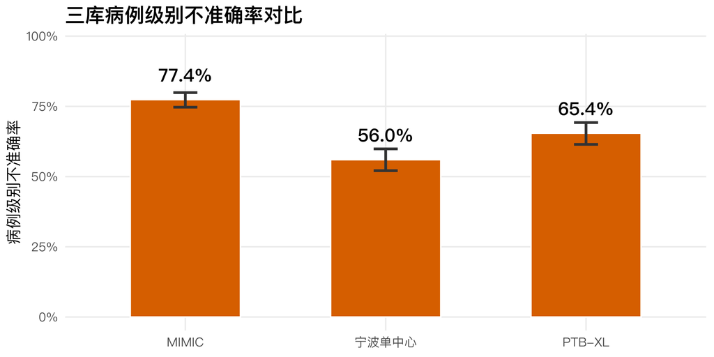

图 1. 三库病例级别不准确率（含 Wilson 95% 置信区间）。误差线为基于有效例数的 Wilson 区间。

```r
ggplot(ov, aes(x = 数据库, y = 不准确率_p, fill = 数据库)) +
  geom_col(width = 0.55, fill = C_INA, color = "white") +
  geom_errorbar(aes(ymin = ci_lo_ina, ymax = ci_hi_ina), width = 0.12, color = "#333333", size = 0.9) +
  scale_y_continuous(labels = percent_format(accuracy = 1), limits = c(0, 0.96)) +
  geom_text(aes(label = fpct(不准确率_p)), vjust = -1.4, family = FONT, size = 4.5, fontface = "bold") +
  labs(x = NULL, y = "病例级别不准确率") + theme(legend.position = "none") +
  ggtitle("三库病例级别不准确率对比")
```

# 4 各库标签质量的解剖：遗漏与误标（结果 3）

本节对三库均构建逐诊断概念的四格表，量化遗漏率（qfn）与误标率（fdr）。宁波（中文受控词表，最新 623 例全判）直接按 39 项受控概念构建；PTB-XL 由既有分析提供逐 SCP 码四格表，并经概念对照表映射到同一概念集；MIMIC 的原始标签为自由文本报告，先经受控词表关键词命中（对英文 `report` 与中文 `report_cn` 双侧检索，并按否定语境窗口剔除「未见」「除外」一类否定表述）转换为概念级存在性判断，再与专家校正标签 `correctLabel` 比对构建四格表，详见 §1.4。

**表 2. 三库逐标签噪声指标汇总（四格表派生）。三库均按统一的 39 项受控诊断概念构建「数据库标签 × 专家金标准」四格表：宁波直接由中文受控词表构建，PTB-XL 由 SCP 码经概念对照表映射，MIMIC 由自由文本经受控词表关键词命中（含否定语境过滤）转换为概念级存在性判断后构建。qfn = FN/(TP+FN)，fdr = FP/(TP+FP)，单元级错误率 = (FP+FN)/(TP+FP+FN)。MIMIC 的四格表属受控词表视角的近似估计，量级可比但不宜逐位小数比较。**

**展开代码**

```r
pt_ncodes_fdr <- nrow(pt_json$per_dx |> filter(!is.na(fdr)))
sum3 <- tibble(
  数据库 = c("宁波单中心", "PTB-XL", "MIMIC"),
  有效例数 = c(nb_n, pt_n, mc_n),
  诊断标签数 = c(length(lab_all), pt_ncodes_fdr, mc_ncon),
  TP = c(TPs, as.numeric(pta$tp), mc_tp),
  FP = c(FPs, as.numeric(pta$fp), mc_fp),
  FN = c(FNs, as.numeric(pta$fn), mc_fn),
  TN = c(TNs, as.numeric(pta$tn), mc_tn),
  qfn = c(qfn_nb, pt_qfn, mc_qfn_agg),
  fdr = c(fdr_nb, pt_fdr, mc_fdr_agg)
) |> mutate(
  err_unit = (FP + FN) / (TP + FP + FN),
  有效例数 = sprintf("%d", 有效例数),
  诊断标签数 = sprintf("%d", 诊断标签数),
  TP = ifelse(is.na(TP), "—", sprintf("%d", TP)),
  FP = ifelse(is.na(FP), "—", sprintf("%d", FP)),
  FN = ifelse(is.na(FN), "—", sprintf("%d", FN)),
  TN = ifelse(is.na(TN), "—", sprintf("%d", TN)),
  qfn = ifelse(is.na(qfn), "—", sprintf("%.1f%%", qfn*100)),
  fdr = ifelse(is.na(fdr), "—", sprintf("%.1f%%", fdr*100)),
  err_unit = ifelse(is.na(err_unit), "—", sprintf("%.1f%%", err_unit*100))
) |> rename(
  `TP (真阳性)` = TP, `FP (假阳性·误标)` = FP, `FN (假阴性·遗漏)` = FN, `TN (真阴性)` = TN,
  `qfn (遗漏率)` = qfn, `fdr (误标率)` = fdr, `err_unit (单元级错误率)` = err_unit)
ft(sum3, fs = 8.5) |> fit_to_width(max_width = 6.2, unit = "in") |> set_caption("表 2. 三库逐标签噪声指标汇总（四格表派生）。三库均按统一的 39 项受控诊断概念构建「数据库标签 × 专家金标准」四格表：宁波直接由中文受控词表构建，PTB-XL 由 SCP 码经概念对照表映射，MIMIC 由自由文本经受控词表关键词命中（含否定语境过滤）转换为概念级存在性判断后构建。qfn = FN/(TP+FN)，fdr = FP/(TP+FP)，单元级错误率 = (FP+FN)/(TP+FP+FN)。MIMIC 的四格表属受控词表视角的近似估计，量级可比但不宜逐位小数比较。")
```

| 数据库 | 有效例数 | 诊断标签数 | TP (真阳性) | FP (假阳性·误标) | FN (假阴性·遗漏) | TN (真阴性) | qfn (遗漏率) | fdr (误标率) | err_unit (单元级错误率) |
| --- | --- | --- | --- | --- | --- | --- | --- | --- | --- |
| 宁波单中心 | 623 | 39 | 399 | 741 | 7 | 23150 | 1.7% | 65.0% | 65.2% |
| PTB-XL | 573 | 40 | 357 | 216 | 587 | 21760 | 62.2% | 37.7% | 69.2% |
| MIMIC | 1000 | 28 | 1756 | 351 | 895 | 35998 | 33.8% | 16.7% | 41.5% |

**表 3A. 三库逐标签误标率（fdr）。每库给出『误标数/该标签总数』与误标率%（= FP/(TP+FP)）。三库均由四格表直接计算，其中 MIMIC 的四格表由自由文本经 39 项受控词表关键词命中构建，仅展示分母（TP+FP）≥ 15 的概念以避免小样本极端值。行按各库误标率由高到低独立排序；空缺行用「—」表示该库无对应标签或支撑不足。三库列组以不同底色区分（宁波=绿、PTB-XL=黄、MIMIC=蓝）。**

| 排名 | 宁波 标签 | 宁波 误标/总数 | 宁波 误标率 | PTB-XL 标签 | PTB-XL 误标/总数 | PTB-XL 误标率 | MIMIC 标签 | MIMIC 误标/总数 | MIMIC 误标率 |
| --- | --- | --- | --- | --- | --- | --- | --- | --- | --- |
| 1 | LVQRSAL (全导联低电压QRS) | 23/23 | 100.0% | BIGU (二联律) | 1/1 | 100.0% | STTU (ST段抬高) | 31/35 | 88.6% |
| 2 | IDC (室内差异传导) | 18/18 | 100.0% | ILMI (下侧壁心梗) | 8/8 | 100.0% | QTIE (QT间期延长) | 36/41 | 87.8% |
| 3 | STE (ST段延长) | 17/17 | 100.0% | IPLMI (下后侧壁心梗) | 1/1 | 100.0% | LVH (左心室肥厚) | 32/61 | 52.5% |
| 4 | QTIE (QT间期延长) | 15/15 | 100.0% | IPMI (下后壁心梗) | 1/1 | 100.0% | AVB (房室传导阻滞) | 21/49 | 42.9% |
| 5 | RBBB (右束支阻滞) | 10/10 | 100.0% | ISCIL (下侧壁缺血) | 2/2 | 100.0% | 1AVB (一度房室传导阻滞) | 19/46 | 41.3% |
| 6 | LBBBB (左后束支传导阻滞) | 6/6 | 100.0% | ISCIN (下壁缺血) | 2/2 | 100.0% | SA (窦性心律不齐) | 13/34 | 38.2% |
| 7 | ERV (室壁早期复极化) | 7/7 | 100.0% | ISCLA (下侧壁缺血) | 1/1 | 100.0% | TWC (T波改变) | 50/160 | 31.2% |
| 8 | AT (房性心动过速) | 6/6 | 100.0% | IVCD (室内传导阻滞) | 13/13 | 100.0% | APB (房性早搏) | 10/40 | 25.0% |
| 9 | UW (U波) | 5/5 | 100.0% | LAO (左房肥大) | 5/5 | 100.0% | ALS (轴向左移) | 24/97 | 24.7% |
| 10 | VFW (室性融合波) | 4/4 | 100.0% | PSVT (阵发性室上性心动过速) | 1/1 | 100.0% | AFIB (心房颤动) | 13/61 | 21.3% |
| 11 | PWC (P波改变) | 3/3 | 100.0% | RAO/RAE (右房肥大) | 1/1 | 100.0% | STTC (ST-T改变) | 20/128 | 15.6% |
| 12 | AVB (房室传导阻滞) | 3/3 | 100.0% | SEHYP (室间隔肥厚) | 1/1 | 100.0% | LVQRSAL (全导联低电压QRS) | 10/75 | 13.3% |
| 13 | CR (顺时针旋转) | 1/1 | 100.0% | ASMI (前间壁心梗) | 33/39 | 84.6% | VPB (室性早搏) | 7/55 | 12.7% |
| 14 | 2AVB1 (二度房室传导阻滞（一型）) | 1/1 | 100.0% | ISC (缺血性ST压低) | 19/23 | 82.6% | ARS (轴向右移) | 2/17 | 11.8% |
| 15 | WPW (预激综合征) | 1/1 | 100.0% | ALMI (前侧壁心梗) | 4/5 | 80.0% | SB (窦性心动过缓) | 8/112 | 7.1% |
| 16 | MISW (侧壁心肌梗死) | 3/3 | 100.0% | AMI (前壁心梗) | 4/5 | 80.0% | ST (窦性心动过速) | 6/96 | 6.2% |
| 17 | AFL (心房扑动) | 114/117 | 97.4% | INJAS (前间壁损伤) | 4/5 | 80.0% | RBBB (右束支阻滞) | 3/55 | 5.5% |
| 18 | SVT (室上性心动过速) | 13/14 | 92.9% | ISCAL (前侧壁缺血) | 8/11 | 72.7% | SR (窦性心律) | 8/897 | 0.9% |
| 19 | LVH (左心室肥厚) | 10/12 | 83.3% | DIG (洋地黄效应) | 5/7 | 71.4% |  | — | — |
| 20 | ARS (轴向右移) | 14/17 | 82.4% | ISCAS (前间壁缺血) | 2/3 | 66.7% |  | — | — |
| 21 | APB (房性早搏) | 20/25 | 80.0% | INJAL (前侧壁损伤) | 2/4 | 50.0% |  | — | — |
| 22 | TWO (T波倒置) | 44/57 | 77.2% | LAFB (左前分支阻滞) | 12/24 | 50.0% |  | — | — |
| 23 | 3AVB (三度房室传导阻滞) | 3/4 | 75.0% | LPFB (左后分支阻滞) | 1/2 | 50.0% |  | — | — |
| 24 | TWC (T波改变) | 95/131 | 72.5% | NDT (T波异常) | 17/34 | 50.0% |  | — | — |
| 25 | STDD (ST段压低) | 20/28 | 71.4% | IMI (下壁心梗) | 14/31 | 45.2% |  | — | — |
| 26 | ALS (轴向左移) | 22/31 | 71.0% | LVH (左心室肥厚) | 6/15 | 40.0% |  | — | — |
| 27 | AQW (异常Q波) | 15/22 | 68.2% | LNGQT (QT间期延长) | 1/3 | 33.3% |  | — | — |
| 28 | 1AVB (一度房室传导阻滞) | 15/23 | 65.2% | NST (ST-T改变) | 3/11 | 27.3% |  | — | — |
| 29 | STTC (ST-T改变) | 13/20 | 65.0% | IRBBB (不完全性右束支传导阻滞) | 7/30 | 23.3% |  | — | — |
| 30 | AFIB (心房颤动) | 21/33 | 63.6% | CLBBB (完全性左束支传导阻滞) | 2/11 | 18.2% |  | — | — |
| 31 | SA (窦性心律不齐) | 21/41 | 51.2% | NORM (正常窦性心律) | 31/211 | 14.7% |  | — | — |
| 32 | CCR (逆时针旋转) | 3/6 | 50.0% | AVB1 (一度房室传导阻滞) | 4/30 | 13.3% |  | — | — |
| 33 | PRIE (PR间期延长) | 1/2 | 50.0% | AFIB (心房颤动) | 0/1 | 0.0% |  | — | — |
| 34 | VPB (室性早搏) | 3/6 | 50.0% | AFLT (心房扑动) | 0/1 | 0.0% |  | — | — |
| 35 | ST (窦性心动过速) | 50/102 | 49.0% | CRBBB (完全性右束支传导阻滞) | 0/11 | 0.0% |  | — | — |
| 36 | SB (窦性心动过缓) | 86/217 | 39.6% | EL (电解质紊乱) | 0/1 | 0.0% |  | — | — |
| 37 | STTU (ST段抬高) | 1/3 | 33.3% | LMI (侧壁心梗) | 0/1 | 0.0% |  | — | — |
| 38 | SR (窦性心律) | 34/105 | 32.4% | PACE (起搏器) | 0/7 | 0.0% |  | — | — |
| 39 | JEB (交接区逸搏) | 0/1 | 0.0% | PVC (室性早搏) | 0/8 | 0.0% |  | — | — |
| 40 |  | — | — | WPW (预激综合征) | 0/2 | 0.0% |  | — | — |

**表 3B. 三库逐标签漏标率（qfn）。每库给出『漏标数/该标签总数』与漏标率%（= FN/(TP+FN)）。三库均由四格表直接计算，其中 MIMIC 的四格表由自由文本经 39 项受控词表关键词命中构建，仅展示分母（TP+FN）≥ 15 的概念以避免小样本极端值。行按各库漏标率由高到低独立排序；空缺行用「—」表示该库无对应标签或支撑不足。表 3A 与表 3B 合称表 3。三库列组以不同底色区分（宁波=绿、PTB-XL=黄、MIMIC=蓝）。**

| 排名 | 宁波 标签 | 宁波 漏标/总数 | 宁波 漏标率 | PTB-XL 标签 | PTB-XL 漏标/总数 | PTB-XL 漏标率 | MIMIC 标签 | MIMIC 漏标/总数 | MIMIC 漏标率 |
| --- | --- | --- | --- | --- | --- | --- | --- | --- | --- |
| 1 | AFIB (心房颤动) | 6/18 | 33.3% | AFIB (心房颤动) | 26/27 | 96.3% | PWC (P波改变) | 327/327 | 100.0% |
| 2 | SA (窦性心律不齐) | 1/21 | 4.8% | NST (ST-T改变) | 153/161 | 95.0% | AQW (异常Q波) | 99/100 | 99.0% |
| 3 | SB (窦性心动过缓) | 0/131 | 0.0% | NDT (T波异常) | 66/83 | 79.5% | RBBB (右束支阻滞) | 82/134 | 61.2% |
| 4 | AFL (心房扑动) | 0/3 | 0.0% | PVC (室性早搏) | 31/39 | 79.5% | SA (窦性心律不齐) | 28/49 | 57.1% |
| 5 | TWC (T波改变) | 0/36 | 0.0% | IMI (下壁心梗) | 54/71 | 76.1% | TWC (T波改变) | 121/231 | 52.4% |
| 6 | ST (窦性心动过速) | 0/52 | 0.0% | NORM (正常窦性心律) | 213/393 | 54.2% | STTC (ST-T改变) | 80/188 | 42.5% |
| 7 | SR (窦性心律) | 0/71 | 0.0% | AFLT (心房扑动) | 1/2 | 50.0% | APB (房性早搏) | 19/49 | 38.8% |
| 8 | TWO (T波倒置) | 0/13 | 0.0% | LAFB (左前分支阻滞) | 8/20 | 40.0% | ALS (轴向左移) | 24/97 | 24.7% |
| 9 | STDD (ST段压低) | 0/8 | 0.0% | LVH (左心室肥厚) | 6/15 | 40.0% | AVB (房室传导阻滞) | 9/37 | 24.3% |
| 10 | ALS (轴向左移) | 0/9 | 0.0% | CRBBB (完全性右束支传导阻滞) | 6/17 | 35.3% | 1AVB (一度房室传导阻滞) | 8/35 | 22.9% |
| 11 | APB (房性早搏) | 0/5 | 0.0% | WPW (预激综合征) | 1/3 | 33.3% | LVH (左心室肥厚) | 8/37 | 21.6% |
| 12 | AQW (异常Q波) | 0/7 | 0.0% | IRBBB (不完全性右束支传导阻滞) | 10/33 | 30.3% | AFIB (心房颤动) | 10/58 | 17.2% |
| 13 | ARS (轴向右移) | 0/3 | 0.0% | AVB1 (一度房室传导阻滞) | 9/35 | 25.7% | VPB (室性早搏) | 9/57 | 15.8% |
| 14 | LVH (左心室肥厚) | 0/2 | 0.0% | CLBBB (完全性左束支传导阻滞) | 2/11 | 18.2% | ARS (轴向右移) | 2/17 | 11.8% |
| 15 | STTC (ST-T改变) | 0/7 | 0.0% | PACE (起搏器) | 1/8 | 12.5% | LVQRSAL (全导联低电压QRS) | 6/71 | 8.5% |
| 16 | SVT (室上性心动过速) | 0/1 | 0.0% | ALMI (前侧壁心梗) | 0/1 | 0.0% | SB (窦性心动过缓) | 8/112 | 7.1% |
| 17 | 3AVB (三度房室传导阻滞) | 0/1 | 0.0% | AMI (前壁心梗) | 0/1 | 0.0% | ST (窦性心动过速) | 5/95 | 5.3% |
| 18 | CCR (逆时针旋转) | 0/3 | 0.0% | ASMI (前间壁心梗) | 0/6 | 0.0% | SR (窦性心律) | 32/921 | 3.5% |
| 19 | 1AVB (一度房室传导阻滞) | 0/8 | 0.0% | DIG (洋地黄效应) | 0/2 | 0.0% |  | — | — |
| 20 | PRIE (PR间期延长) | 0/1 | 0.0% | EL (电解质紊乱) | 0/1 | 0.0% |  | — | — |
| 21 | JEB (交接区逸搏) | 0/1 | 0.0% | INJAL (前侧壁损伤) | 0/2 | 0.0% |  | — | — |
| 22 | VPB (室性早搏) | 0/3 | 0.0% | INJAS (前间壁损伤) | 0/1 | 0.0% |  | — | — |
| 23 | STTU (ST段抬高) | 0/2 | 0.0% | ISC (缺血性ST压低) | 0/4 | 0.0% |  | — | — |
| 24 | LVQRSAL (全导联低电压QRS) | 0/0 | — | ISCAL (前侧壁缺血) | 0/3 | 0.0% |  | — | — |
| 25 | IDC (室内差异传导) | 0/0 | — | ISCAS (前间壁缺血) | 0/1 | 0.0% |  | — | — |
| 26 | STE (ST段延长) | 0/0 | — | LMI (侧壁心梗) | 0/1 | 0.0% |  | — | — |
| 27 | QTIE (QT间期延长) | 0/0 | — | LNGQT (QT间期延长) | 0/2 | 0.0% |  | — | — |
| 28 | RBBB (右束支阻滞) | 0/0 | — | LPFB (左后分支阻滞) | 0/1 | 0.0% |  | — | — |
| 29 | LBBBB (左后束支传导阻滞) | 0/0 | — |  | — | — |  | — | — |
| 30 | ERV (室壁早期复极化) | 0/0 | — |  | — | — |  | — | — |
| 31 | AT (房性心动过速) | 0/0 | — |  | — | — |  | — | — |
| 32 | UW (U波) | 0/0 | — |  | — | — |  | — | — |
| 33 | VFW (室性融合波) | 0/0 | — |  | — | — |  | — | — |
| 34 | PWC (P波改变) | 0/0 | — |  | — | — |  | — | — |
| 35 | AVB (房室传导阻滞) | 0/0 | — |  | — | — |  | — | — |
| 36 | CR (顺时针旋转) | 0/0 | — |  | — | — |  | — | — |
| 37 | 2AVB1 (二度房室传导阻滞（一型）) | 0/0 | — |  | — | — |  | — | — |
| 38 | WPW (预激综合征) | 0/0 | — |  | — | — |  | — | — |
| 39 | MISW (侧壁心肌梗死) | 0/0 | — |  | — | — |  | — | — |

**展开代码**

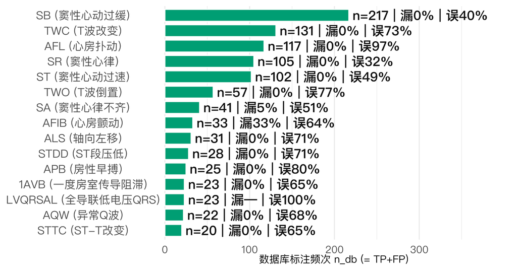

```r
pctv <- function(x) ifelse(is.na(x), "—", sprintf("%.0f%%", x * 100))

top20_nb <- nb_lab |>
  mutate(nn  = n_db,
         ann = paste0("n=", nn, " | 漏", pctv(qfn), " | 误", pctv(fdr))) |>
  arrange(desc(nn)) |> slice_head(n = 15) |>
  arrange(nn) |>
  mutate(lab = factor(lab, levels = lab))

off <- 0.02 * max(top20_nb$nn, na.rm = TRUE)

ggplot(top20_nb, aes(x = lab, y = nn)) +
  geom_col(fill = C_OK, color = "white", width = 0.78) + coord_flip(clip = "off") +
  geom_text(aes(y = nn + off, label = ann), hjust = 0,
            color = "#111111", fontface = "bold", size = 4.5, family = FONT) +
  scale_y_continuous(expand = expansion(mult = c(0, 0.80))) +
  labs(x = NULL, y = "数据库标注频次 n_db (= TP+FP)") +
  theme_minimal(base_family = FONT) %+replace%
  theme(axis.text.y = element_text(size = 11, family = FONT),
        axis.text.x = element_text(size = 10, family = FONT),
        axis.title.x = element_text(size = 10, family = FONT),
        plot.margin = margin(t = 6, r = 14, b = 10, l = 6),
        panel.grid.major.y = element_blank())
```

**展开代码**

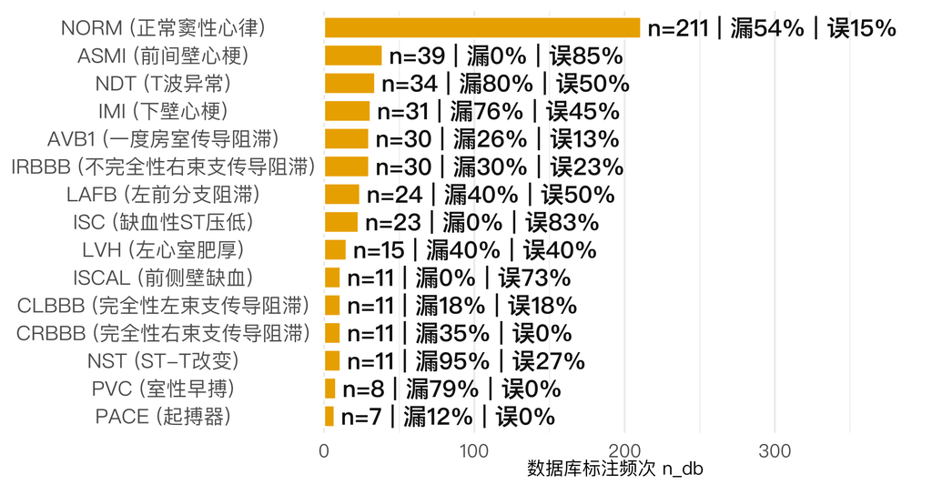

```r
top20_pt <- pt_lab |>
  mutate(nn  = n_db,
         ann = paste0("n=", nn, " | 漏", pctv(qfn), " | 误", pctv(fdr))) |>
  arrange(desc(nn)) |> slice_head(n = 15) |>
  arrange(nn) |>
  mutate(lab = factor(lab, levels = lab))

off <- 0.02 * max(top20_pt$nn, na.rm = TRUE)

ggplot(top20_pt, aes(x = lab, y = nn)) +
  geom_col(fill = C_WARN, color = "white", width = 0.78) + coord_flip(clip = "off") +
  geom_text(aes(y = nn + off, label = ann), hjust = 0,
            color = "#111111", fontface = "bold", size = 4.5, family = FONT) +
  scale_y_continuous(expand = expansion(mult = c(0, 0.80))) +
  labs(x = NULL, y = "数据库标注频次 n_db") +
  theme_minimal(base_family = FONT) %+replace%
  theme(axis.text.y = element_text(size = 11, family = FONT),
        axis.text.x = element_text(size = 10, family = FONT),
        axis.title.x = element_text(size = 10, family = FONT),
        plot.margin = margin(t = 6, r = 14, b = 10, l = 6),
        panel.grid.major.y = element_blank())
```

**展开代码**

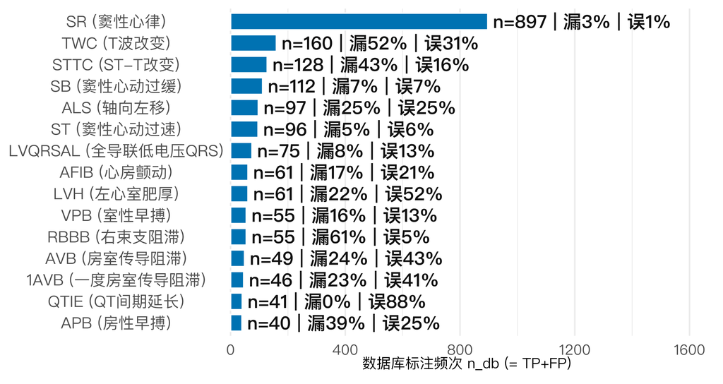

图 2C. MIMIC 数据库标签出现频次 Top15。条长＝该受控诊断概念在数据库自由文本标签中的命中频次（n_db = TP+FP）。条右侧依次标注：该概念的数据库端总数 n、漏标率（qfn = FN/(TP+FN)）、误标率（fdr = FP/(TP+FP)）。MIMIC 的四格表由自由文本经 39 项受控词表关键词命中构建，属受控词表视角的近似估计；分母为 0 的率以「—」表示。按频次降序取前 15 个概念。

```r
top20_mc <- mc_dx_lab |>
  mutate(nn  = tp + fp,
         ann = paste0("n=", nn, " | 漏", pctv(qfn), " | 误", pctv(fdr))) |>
  filter(nn > 0) |>
  arrange(desc(nn)) |> slice_head(n = 15) |>
  arrange(nn) |>
  mutate(lab = factor(lab, levels = lab))

off <- 0.02 * max(top20_mc$nn, na.rm = TRUE)

ggplot(top20_mc, aes(x = lab, y = nn)) +
  geom_col(fill = C_ACC, color = "white", width = 0.78) + coord_flip(clip = "off") +
  geom_text(aes(y = nn + off, label = ann), hjust = 0,
            color = "#111111", fontface = "bold", size = 4.5, family = FONT) +
  scale_y_continuous(expand = expansion(mult = c(0, 0.80))) +
  labs(x = NULL, y = "数据库标注频次 n_db (= TP+FP)") +
  theme_minimal(base_family = FONT) %+replace%
  theme(axis.text.y = element_text(size = 11, family = FONT),
        axis.text.x = element_text(size = 10, family = FONT),
        axis.title.x = element_text(size = 10, family = FONT),
        plot.margin = margin(t = 6, r = 14, b = 10, l = 6),
        panel.grid.major.y = element_blank())
```

## 4.1 跨库 Goldman 严重性对比（宁波 vs PTB-XL）

将同一 Goldman 镜头经概念对照表（§5 表 7）映射至 PTB-XL 的 SCP 诊断码后，PTB-XL 单元级分析（pt_per）共产生 766 个诊断单元级错误事件。跨库对比（表 4、图 3）揭示三点系统性差异。

第一，重大差异率（Class I+II 占全部错误事件之比）PTB-XL 为 44.5%，高于宁波的 31.0%。更关键的是两库在 Class I 呈现方向相反的错误极性：宁波 Class I 以误标（FP=193）为主导、遗漏极少（FN=6），即倾向于过度断言核心诊断（如将非房颤判读为心房颤动）；PTB-XL 的 Class I 则以遗漏（FN=235）为主、误标为辅（FP=94），即倾向于漏写核心诊断。两种极性对下游 AI 模型的安全含义不同，前者放大假阳性、后者放大假阴性，均需在模型部署前针对性校偏。

第二，PTB-XL 的 Class IV 错误事件（245 个，占其全部错误事件的 32.0%）几乎全部来自 SCP 码 NORM（正常窦性心律，244 个），即”标注为正常、实则遗漏真实诊断”的掩蔽型漏标。在概念锚定的 Goldman 分级下，正常/偶发概念天然归入 IV 类，故这部分约占 PTB-XL 全部错误事件的三成被计入最低严重度。这说明概念锚定分级会低估”以正常为掩蔽的漏标”的临床权重；若以敏感性口径将 NORM 下的遗漏事件视为主动漏判的最低临床相关项，PTB-XL 的”重大+次要相关”负担将显著高于表 4 的账面值。

第三，两库的命名空间结构直接塑造了各自的严重度构成：宁波的高频错误集中于 Class III 的复极/传导改变（占 60.0%）；PTB-XL 则因 SCP 码粒度更细（同一临床概念拆分为 ALMI/ILMI/IPMI 等亚码），在 Class I 心肌梗死/缺血家族累积了更多事件（329 个）。

**表 4. 宁波与 PTB-XL 诊断单元级错误事件按 Goldman 分级的跨库对比。括号内为占各自全部错误事件的百分比；重大(I+II)为 Class I 与 II 之和。**

**展开代码**

```r
tx <- gold_x |> mutate(
  宁波 = paste0(宁波错误事件, " (", fpct(宁波占比,1), ")"),
  PTB = paste0(`PTB-XL错误事件`, " (", fpct(`PTB-XL占比`,1), ")")) |>
  select(Goldman, `宁波(错误事件,%)`=宁波, `PTB-XL(错误事件,%)`=PTB)
tx_total <- tibble(Goldman="合计",
  `宁波(错误事件,%)`=paste0(gold_unit_nb_tot," (100.0%)"),
  `PTB-XL(错误事件,%)`=paste0(gold_unit_pt_tot," (100.0%)"))
tx_major <- tibble(Goldman="重大(I+II)",
  `宁波(错误事件,%)`=paste0(gold_unit_nb_maj," (",fpct(gold_unit_nb_maj/gold_unit_nb_tot,1),")"),
  `PTB-XL(错误事件,%)`=paste0(gold_unit_pt_maj," (",fpct(gold_unit_pt_maj/gold_unit_pt_tot,1),")"))
ft(bind_rows(tx, tx_total, tx_major), fs = 9) |>
  set_caption("表 4. 宁波与 PTB-XL 诊断单元级错误事件按 Goldman 分级的跨库对比。括号内为占各自全部错误事件的百分比；重大(I+II)为 Class I 与 II 之和。")
```

| Goldman | 宁波(错误事件,%) | PTB-XL(错误事件,%) |
| --- | --- | --- |
| I | 199 (26.6%) | 329 (43.0%) |
| II | 33 (4.4%) | 12 (1.6%) |
| III | 449 (60.0%) | 180 (23.5%) |
| IV | 67 (9.0%) | 245 (32.0%) |
| 合计 | 748 (100.0%) | 766 (100.0%) |
| 重大(I+II) | 232 (31.0%) | 341 (44.5%) |

**展开代码**

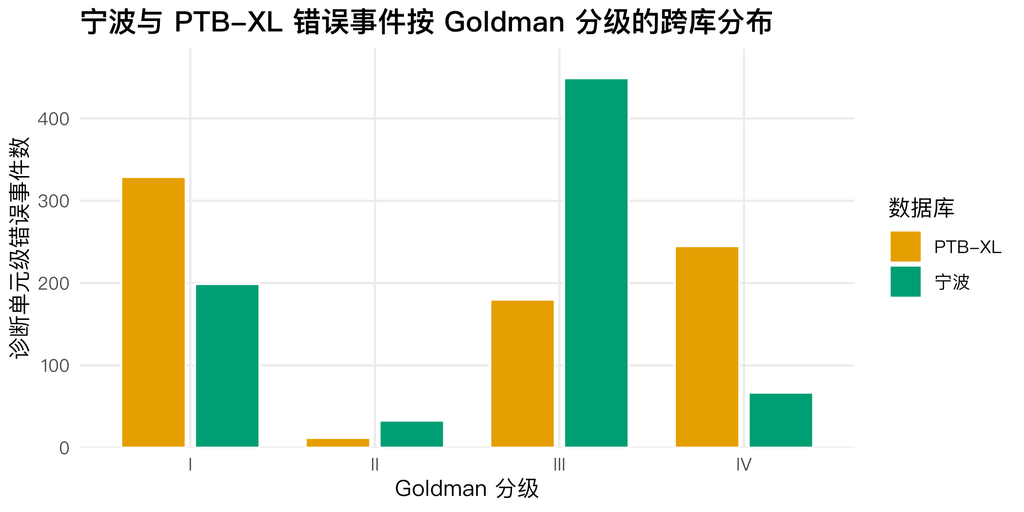

图 3. 宁波与 PTB-XL 诊断单元级错误事件按 Goldman 分级的跨库分布。PTB-XL 重大差异率更高且 Class I 以遗漏为主，宁波 Class I 以误标为主。

```r
fig_gold_x_dat <- gold_x |> pivot_longer(c(`宁波错误事件`, `PTB-XL错误事件`), names_to="数据库", values_to="err") |>
  mutate(数据库 = recode(数据库, `宁波错误事件`="宁波", `PTB-XL错误事件`="PTB-XL"))
ggplot(fig_gold_x_dat, aes(x = Goldman, y = err, fill = 数据库)) +
  geom_col(position = position_dodge(width = 0.8), width = 0.7, color = "white") +
  scale_fill_manual(values = c("宁波" = C_OK, "PTB-XL" = C_WARN)) +
  scale_y_continuous(expand = expansion(mult = c(0, 0.08))) +
  labs(x = "Goldman 分级", y = "诊断单元级错误事件数", fill = "数据库") +
  ggtitle("宁波与 PTB-XL 错误事件按 Goldman 分级的跨库分布")
```

## 4.2 误标标签的纠正去向：从机器标签到专家诊断

前面各节回答了”错了多少”，本节回答”错成了什么、被改成什么”。对每一例判定为不准确的记录，将数据库原始诊断（宁波为结构化诊断名称串；PTB-XL 与 MIMIC 为机打报告文本）与专家纠正后的诊断列表各自切分为规范术语集合，二者取差集即得到**误标集合（被专家删除的数据库标签）**与**漏标集合（专家新写入的标签）**；再在同一例内做”误标 × 漏标”共现，即得误标标签的纠正去向。术语经同一套规范化规则对齐（全半角统一、括号与报告套话剔除、同义词归一至宁波 39 项受控词表）。宁波 224／349 例不准确病例中存在误标，PTB-XL 为 330／375，MIMIC 为 729／774。

图 4A–图 4C 给出三库的流向矩阵：行为被删除的数据库标签（按误标例数降序，行标签括号内为该标签的误标例数），列为补写例数最高的前 6 个专家新写入标签，格内数字为同例共现的病例数。若一例同时删除 2 个标签、补写 3 个标签，会在矩阵中贡献 6 个格子，故行内格子之和可大于该行误标例数；末列「仅删除」指该标签被删除、而该例未补写任何新标签的病例数。

宁波的最强流向高度集中：心房扑动→心房颤动（96 例）；T波改变→ST-T改变（37 例）；心房扑动→ST-T改变（35 例），其中首位流向占该标签误标病例的 100%。宁波的错误以”具体诊断之间的相互错判”与”具体描述被降级为笼统描述”两类为主：前者以心房扑动与心房颤动的混淆为绝对主导，后者表现为 T 波改变、T 波倒置被专家合并改写为 ST-T 改变。

**展开代码**

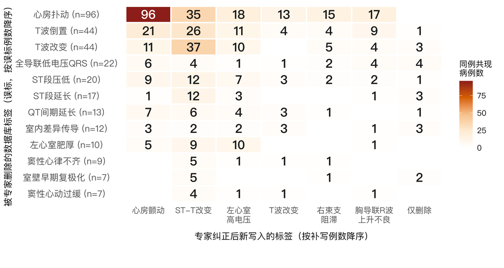

图 4A. 宁波数据库：误标标签的纠正去向矩阵。行＝被专家删除的数据库诊断标签，列＝专家新写入的标签；格内数字为同一病例内同时出现「删除该标签」与「补写该标签」的病例数。术语已归一至宁波 39 项受控词表。

```r
flow_plot(flm_nb)
```

PTB-XL 的最强流向为 心电轴正常→ST-T改变（33 例）；QRS波群异常→异常Q波（29 例）；QRS波群异常→ST-T改变（27 例）。其结构与宁波相反：被删除的多为机打报告中的非特异性或”正常”表述（心电轴正常、QRS 波群异常、心电图正常），纠正去向则集中为具体的复极与梗死征象（ST-T 改变、异常 Q 波、T 波改变），即”以模糊表述充当具体诊断”的错误模式。另有一类为修饰语遗漏（窦性心律被改为窦性心动过缓），属节律诊断未写入心率修饰。

**展开代码**

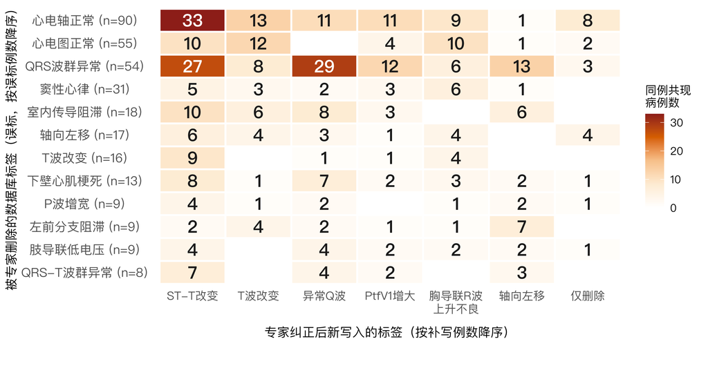

图 4B. PTB-XL：误标标签的纠正去向矩阵。数据库侧为机打报告文本（report_cn_new），专家侧为纠正后的诊断列表；两者按同一术语规范化规则切分后取差集。读法同图 4A。因机打报告含大量非特异性与「正常」表述，被删除项以这类表述为主。

```r
flow_plot(flm_pt)
```

MIMIC 的最强流向为 心电图异常→ST-T改变（97 例）；心电图正常→PtfV1增大（91 例）；心电图异常→PtfV1增大（88 例）。其误标来源几乎完全由三条结论性套话构成（心电图异常、临界心电图、心电图正常），纠正去向则高度分散于 PtfV1 增大、T 波改变、ST-T 改变、异常 Q 波、右束支阻滞、胸导联 R 波上升不良等具体征象。这与 PTB-XL 同属”笼统结论替代具体诊断”，但程度更极端：MIMIC 机打报告的结论性表述几乎不携带可核对的具体异常定位，专家实质上是在重读原始波形后重新给出诊断。

**展开代码**

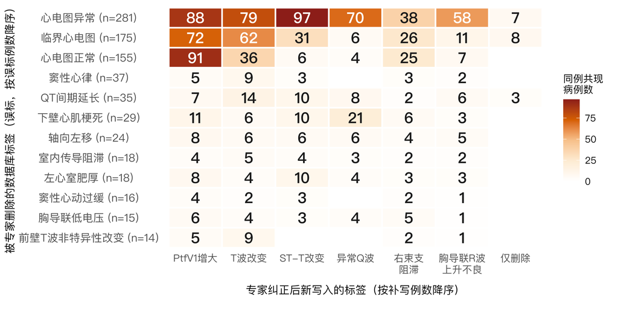

图 4C. MIMIC-IV-ECG：误标标签的纠正去向矩阵。数据库侧为机打报告文本（report_cn），专家侧为纠正后的诊断列表。读法同图 4A。误标项以心电图异常／临界心电图／心电图正常三条结论性套话为主，纠正去向分散为多个具体征象。

```r
flow_plot(flm_mc)
```

此外，误标几乎总与漏标共存：删除了数据库标签却未补写任何新标签的病例仅占宁波 8.5%（19／224）、PTB-XL 5.5%（18／330）、MIMIC 2.2%（16／729），即专家在否定一个标签时几乎总是同时给出替代诊断，而非简单剔除。三库合观，误标的纠正去向呈现两种互补模式。宁波是”具体诊断之间的错判”与”具体描述的降级合并”，误标项本身已是明确诊断（心房扑动、T 波改变、T 波倒置），错误在于指向了错误的靶点或粒度不当；PTB-XL 与 MIMIC 是”非特异性表述与正常结论的误用”，误标项本身不携带可核对的定位信息（心电轴正常、心电图异常、临界心电图），错误在于以笼统结论充当具体诊断。后者对模型训练的危害更大：这类标签在四格表中既构成 FP（机器断言了一个”正常”或”非特异”结论），又同时掩盖了 FN（真实的具体异常从未被写入），与 §4.1 观察到的 PTB-XL Class IV 错误几乎全部来自 NORM 码的现象互为印证。

## 4.3 漏标标签的来源与掩蔽：专家补写了什么

前两节分别回答了”错了多少”与”误标被改成什么”，本节转向遗漏侧：专家究竟补写了哪些数据库从未写过的诊断，以及在这些漏标发生的同一份报告里，数据库当时写的是什么。

方法沿用 §4.2 的同一套术语切分与差集规则：对每一例判定为不准确的记录，将专家纠正标签集合对数据库标签集合取差集，得到**漏标集合**（专家写入、数据库未写）；再在同一例内，将每个漏标标签与该例数据库端所写的每一个标签配对，形成”漏标标签 × 同例数据库标签”的共现。若某例数据库端未写出任何可识别标签，该例的漏标单独归入末列「数据库端无标签」。需强调，矩阵中的共现仅为同一份报告内的伴随关系，不构成因果，也不表示数据库用后者”替代”了前者；它的含义是”当专家补写了这个诊断时，数据库当时给出的是哪种表述”，即漏标所依托的**掩蔽标签**。

**表 5. 三库漏标事件的结构汇总。存在漏标例数＝至少补写一项数据库未写诊断的病例数；漏标事件数＝全部补写项之和；Top5 集中度＝漏标例数最高的前 5 种标签合计占全部漏标事件的比例；数据库端无标签＝该例数据库端未写出任何可识别标签。**

**展开代码**

```r
ft(ms_sum, fs = 9) |>
  set_caption("表 5. 三库漏标事件的结构汇总。存在漏标例数＝至少补写一项数据库未写诊断的病例数；漏标事件数＝全部补写项之和；Top5 集中度＝漏标例数最高的前 5 种标签合计占全部漏标事件的比例；数据库端无标签＝该例数据库端未写出任何可识别标签。")
```

| 数据库 | 不准确例数 | 存在漏标例数 | 漏标事件数 | 被漏标标签种类 | 每例中位漏标数 | 单例最多漏标数 | Top5集中度 | 数据库端无标签 |
| --- | --- | --- | --- | --- | --- | --- | --- | --- |
| 宁波 | 349 | 324 (92.8%) | 599 | 51 | 2.0 | 6 | 63.6% | 1 (0.3%) |
| PTB-XL | 375 | 356 (94.9%) | 745 | 53 | 2.0 | 7 | 51.8% | 43 (12.1%) |
| MIMIC | 774 | 756 (97.7%) | 1,520 | 72 | 2.0 | 6 | 58.7% | 0 (0.0%) |

表 5 显示，漏标是三库不准确报告中的普遍现象而非个别现象。宁波 349 例不准确报告中 324 例（92.8%）存在至少一处漏标，累计 599 个漏标事件，涉及 51 种诊断标签，单例最多同时漏标 6 项；PTB-XL 为 356 例（94.9%）与 745 个事件；MIMIC 为 756 例（97.7%）与 1520 个事件。三库共同的结构性特征是漏标高度集中：前 5 种被漏标的标签即覆盖了宁波 63.6%、PTB-XL 51.8%、MIMIC 58.7% 的漏标事件，说明漏标并非均匀散布于全部诊断，而是沉淀在少数几种反复被漏写的具体表述上。这一集中度为标签治理提供了明确的优先序：补齐这少数几类表述，即可回收大部分遗漏型噪声。

漏标词汇可进一步区分为「三库原有词汇」（术语已在该库原始标签词表中，属标注应用遗漏，可通过强制核查回收）与「专家补充词汇」（术语不在该库原始词表中，或如 MIMIC 那样原始为英文自由文本、中文术语系专家补写，属词汇覆盖缺口）。表 5A 逐一列出后者，即专家实际补入的每一个术语、其被使用的总次数，以及在三个数据库中的分布，以回答”专家到底补了哪些词、各用了多少次、分散在哪些库”这一具体问题。

**表 5A. 专家补充词汇明细（按合计漏标事件数降序，共 98 种术语，合计 1957 个漏标事件）。「英文」列为该术语的标准心电图英文表达；「合计」与三列分库计数分别指该术语在对应数据库中被专家补写为漏标标签的次数。**

| 术语 | 英文 | 合计 | 宁波 | PTB-XL | MIMIC |
| --- | --- | --- | --- | --- | --- |
| PtfV1增大 | PtfV1 increased | 352 | 5 | 49 | 298 |
| T波改变 | T-wave changes | 212 | 0 | 0 | 212 |
| ST-T改变 | ST-T changes | 182 | 0 | 0 | 182 |
| 异常Q波 | Abnormal Q waves | 162 | 0 | 62 | 100 |
| 胸导联R波上升不良 | Poor R-wave progression in precordial leads | 135 | 37 | 0 | 98 |
| 左心室高电压 | Left ventricular high voltage | 109 | 70 | 13 | 26 |
| 右束支阻滞 | Right bundle branch block | 100 | 0 | 0 | 100 |
| 窦性心律 | Sinus rhythm | 60 | 0 | 0 | 60 |
| P波改变 | P-wave changes | 42 | 0 | 13 | 29 |
| 室性早搏 | Premature ventricular complexes (PVCs) | 41 | 0 | 0 | 41 |
| 心室起搏心电图 | Ventricular paced rhythm | 40 | 13 | 7 | 20 |
| 窦性心律不齐 | Sinus arrhythmia | 39 | 0 | 0 | 39 |
| 房性早搏 | Premature atrial complexes (PACs) | 32 | 0 | 0 | 32 |
| 左前分支阻滞 | Left anterior fascicular block | 30 | 10 | 0 | 20 |
| 轴向左移 | Left axis deviation | 28 | 0 | 0 | 28 |
| 起搏器 | Pacemaker | 26 | 11 | 2 | 13 |
| 胸导R波递增不良 | Poor R-wave progression in precordial leads | 26 | 2 | 15 | 9 |
| 心房颤动 | Atrial fibrillation | 22 | 0 | 0 | 22 |
| 肢导联低电压 | Low voltage in limb leads | 22 | 17 | 0 | 5 |
| 心电图正常 | Normal ECG | 19 | 0 | 0 | 19 |
| 胸导低电压 | Low voltage in precordial leads | 19 | 0 | 2 | 17 |
| 窦性心动过缓 | Sinus bradycardia | 18 | 0 | 0 | 18 |
| 一度房室传导阻滞 | First-degree atrioventricular block | 17 | 0 | 0 | 17 |
| 胸导联低电压 | Low voltage in precordial leads | 16 | 4 | 1 | 11 |
| V1导联R/S>1 | R/S ratio >1 in lead V1 | 16 | 13 | 2 | 1 |
| ptfV1增大 | PtfV1 increased | 15 | 2 | 13 | 0 |
| 窦性心动过速 | Sinus tachycardia | 12 | 0 | 0 | 12 |
| 短阵房性心动过速 | Short-run atrial tachycardia | 11 | 3 | 3 | 5 |
| 肢导低电压 | Low voltage in limb leads | 9 | 0 | 2 | 7 |
| 窦性心动过缓伴心律不齐 | Sinus bradycardia with arrhythmia | 8 | 2 | 1 | 5 |

[output cut: 68 more lines]

表 5A 显示，专家补充词汇共 98 种、合计 1957 个漏标事件，且高度集中于 MIMIC：MIMIC 贡献 1520 个（77.7%），宁波 228 个（11.7%）、PTB-XL 209 个（10.7%）。这一分布差异源于三库词表结构的不同：MIMIC 原始报告为英文自由文本，中文诊断术语几乎全部由专家补写，因此专家补充词汇在数量与种类上都占绝对主体；宁波与 PTB-XL 原始标签已覆盖大部分术语，专家补充词汇仅零星集中于少数机打报告未涵盖的细微征象。换言之，三库的词汇覆盖缺口性质不同：MIMIC 是系统性的跨语言词表缺失，宁波与 PTB-XL 则是局部术语缺漏，治理上前者需扩充词表、后者只需补写个别条目。

图 5A–图 5C 给出三库的漏标掩蔽矩阵：行为被专家补写的漏标标签（按漏标例数降序，行标签括号内为该标签的漏标例数），列为同一份报告中数据库端所写的标签（按出现例数降序），格内数字为同例共现的病例数；末列「数据库端无标签」指该例数据库端未写出任何可识别标签。若一例同时漏标 2 项、数据库端写了 3 个标签，会在矩阵中贡献 6 个格子，故行内格子之和可大于该行漏标例数。

**展开代码**

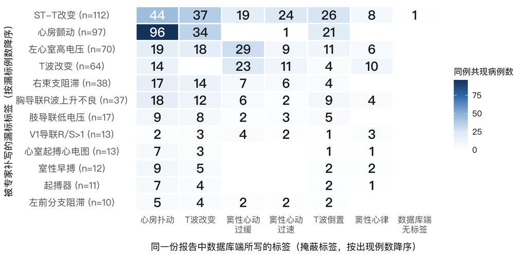

图 5A. 宁波数据库：漏标标签的掩蔽来源矩阵。行＝被专家补写的漏标标签，列＝同一份报告中数据库端所写的标签；格内数字为同例共现的病例数。术语已归一至宁波 39 项受控词表。

```r
miss_plot(msm_nb)
```

宁波最强的掩蔽组合为 漏标「心房颤动」时同例数据库写了「心房扑动」（96 例）；漏标「ST-T改变」时同例数据库写了「心房扑动」（44 例）；漏标「ST-T改变」时同例数据库写了「T波改变」（37 例）。其结构特征为”具体诊断之间的相互掩盖”：数据库已经给出了一个具体的节律诊断（心房扑动），专家判定其指向错误，在删除它的同时补写了正确的具体诊断（心房颤动）；同类情况还包括 T 波改变与 ST-T 改变之间的粒度互换。这类漏标并非数据库未作描述，而是描述的指向发生了偏移，属于最需要借助专家核对才能回收的一类噪声。

**展开代码**

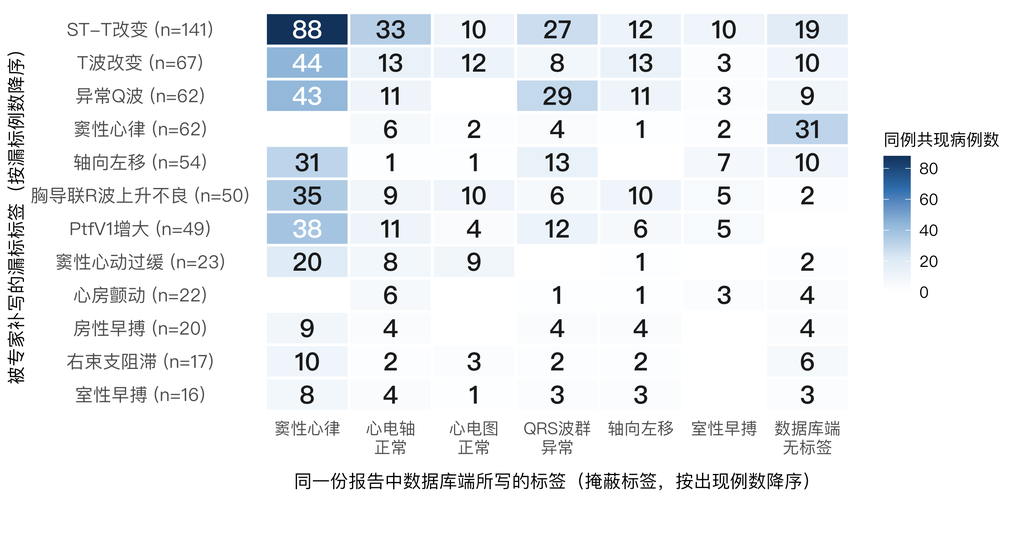

图 5B. PTB-XL：漏标标签的掩蔽来源矩阵。数据库侧为机打报告文本（report_cn_new），专家侧为纠正后的诊断列表。读法同图 5A。被漏标的具体征象多被机打报告中的「窦性心律」等结论性正常陈述所掩盖。

```r
miss_plot(msm_pt)
```

PTB-XL 最强的掩蔽组合为 漏标「ST-T改变」时同例数据库写了「窦性心律」（88 例）；漏标「T波改变」时同例数据库写了「窦性心律」（44 例）；漏标「异常Q波」时同例数据库写了「窦性心律」（43 例）。与宁波不同，PTB-XL 的漏标呈现”以正常心律陈述掩盖具体征象”的清晰结构：专家补写的多为具体的复极、梗死与传导征象（ST-T 改变、T 波改变、异常 Q 波），而数据库在同一份报告中给出的主导表述是「窦性心律」。这提示 PTB-XL 的遗漏型噪声并非随机缺项，而是系统性地发生在”报告已确认心律正常、因而不再逐项书写具体发现”的情形下。

**展开代码**

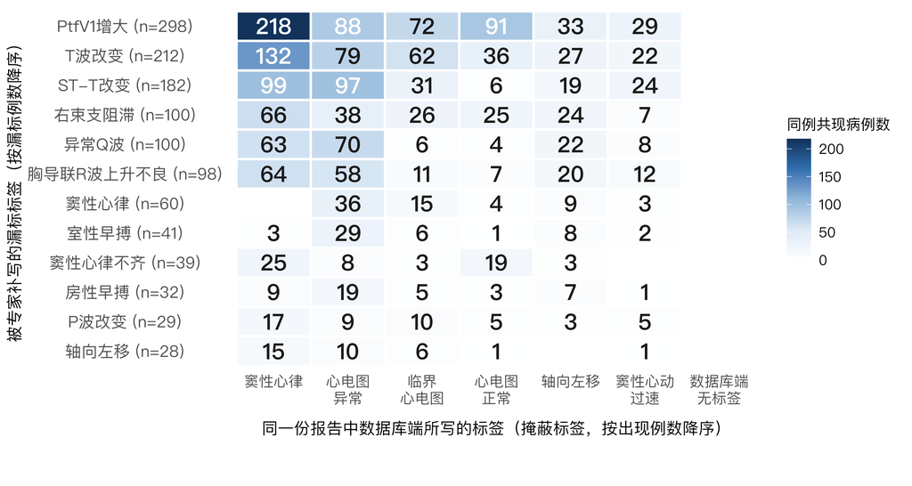

图 5C. MIMIC-IV-ECG：漏标标签的掩蔽来源矩阵。数据库侧为机打报告文本（report_cn），专家侧为纠正后的诊断列表。读法同图 5A。被漏标的次要征象高度集中于「窦性心律」这一结论性陈述之下。

```r
miss_plot(msm_mc)
```

MIMIC 的掩蔽结构与 PTB-XL 同型但更为极端：单项组合”漏标 PtfV1 增大时数据库仅写了窦性心律”即达 218 例，另有 T 波改变（132 例）与 ST-T 改变（99 例）同样被「窦性心律」这一句结论性陈述所掩盖。换言之，MIMIC 机打报告在确认心律正常后即停止书写具体发现，大量次要征象（PtfV1 增大、T 波改变、ST-T 改变等）从未被写入，专家审阅时才逐项补回。这解释了 MIMIC 在病例级不准确率与漏标事件数上均远高于另两库的原因，其噪声几乎全部为遗漏型。

**展开代码**

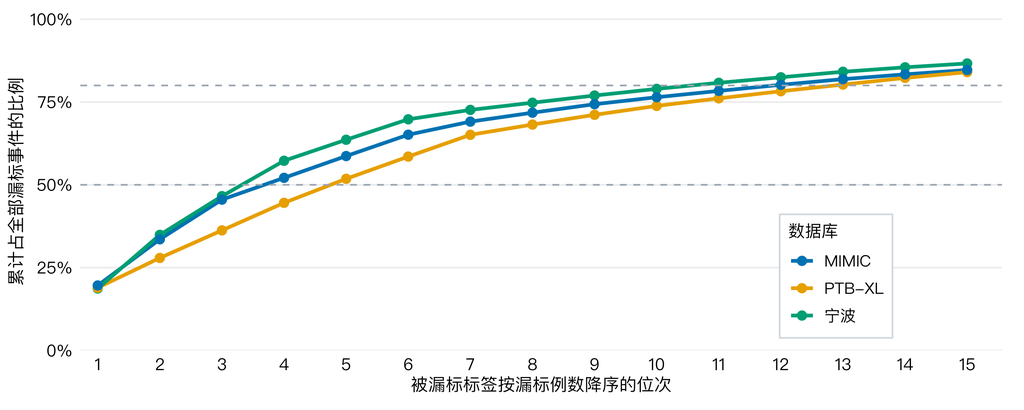

图 6. 三库漏标事件的集中程度。横轴为被漏标标签按漏标例数降序的位次，纵轴为累计占该库全部漏标事件的比例；曲线越陡表示漏标越集中于少数几种诊断。虚线为 50% 与 80% 参考线。

```r
ms_curve <- bind_rows(
  ms_nb$top |> mutate(数据库 = "宁波"),
  ms_pt$top |> mutate(数据库 = "PTB-XL"),
  ms_mc$top |> mutate(数据库 = "MIMIC")) |>
  group_by(数据库) |> mutate(r = row_number(), cum = cumsum(n) / sum(n)) |>
  ungroup() |> filter(r <= 15)
ggplot(ms_curve, aes(x = r, y = cum, colour = 数据库, group = 数据库)) +
  geom_line(linewidth = 1.1) + geom_point(size = 2.4) +
  geom_hline(yintercept = c(0.5, 0.8), linetype = "dashed", colour = "#9AA5B1", linewidth = 0.5) +
  scale_colour_manual(values = c("宁波" = C_OK, "PTB-XL" = C_WARN, "MIMIC" = C_ACC)) +
  scale_x_continuous(breaks = 1:15, expand = expansion(mult = c(0.02, 0.04))) +
  scale_y_continuous(labels = scales::percent, limits = c(0, 1),
                     expand = expansion(mult = c(0, 0.02))) +
  labs(x = "被漏标标签按漏标例数降序的位次", y = "累计占全部漏标事件的比例", colour = "数据库") +
  theme_minimal(base_family = FONT) %+replace%
  theme(panel.grid.minor = element_blank(),
        panel.grid.major.x = element_blank(),
        axis.text = element_text(size = 10.5, family = FONT),
        axis.title = element_text(size = 11, family = FONT),
        legend.title = element_text(size = 10.5, family = FONT),
        legend.text = element_text(size = 10, family = FONT),
        legend.position = c(0.82, 0.22),
        legend.background = element_rect(fill = "white", colour = "#D0D7DE"),
        plot.margin = margin(t = 8, r = 14, b = 10, l = 6))
```

将三库漏标事件合并统计，能更直观地看出哪些诊断被系统性地漏写，以及这些漏写项究竟属于数据库本已覆盖的术语（标注应用遗漏），还是数据库原始词表之外、由专家补入的术语（词汇覆盖缺口）。图 7 给出合并后频次最高的前 22 种漏标标签。

**展开代码**

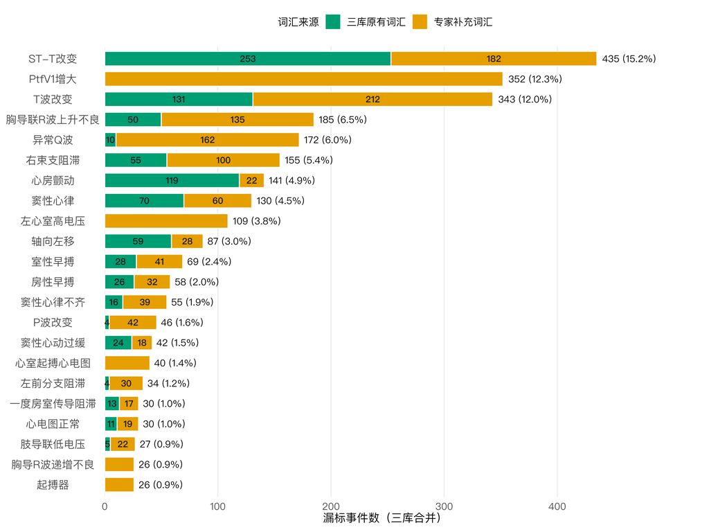

```r
# miss_pool / nb_orig / pt_orig 已在 prep-miss-pool 块中构建（供 表5A 与 图7 共用）
mp_total <- nrow(miss_pool)
mp_lab  <- miss_pool |> count(lab, name = "tot") |> arrange(desc(tot))
mp_top  <- head(mp_lab$lab, 22)
mp_cls  <- miss_pool |> distinct(lab, 分类) |> count(lab, name = "k")
mp_cnt  <- miss_pool |> filter(lab %in% mp_top) |>
  count(lab, 分类, name = "n") |>
  left_join(mp_lab |> filter(lab %in% mp_top) |> mutate(pct = tot / mp_total * 100), by = "lab") |>
  left_join(mp_cls, by = "lab") |>
  mutate(分类 = factor(分类, levels = c("三库原有词汇", "专家补充词汇")),
         lab  = factor(lab, levels = rev(mp_top)),
         show_seg = k >= 2)
fig_miss_pool <- ggplot(mp_cnt, aes(x = n, y = lab, fill = 分类)) +
  geom_col(position = position_stack(reverse = TRUE), width = 0.72, color = "white") +
  geom_text(data = mp_cnt |> filter(show_seg),
            aes(label = n, group = 分类),
            position = position_stack(reverse = TRUE, vjust = 0.5),
            size = 3.2, family = FONT, color = "#1A1A1A", fontface = "bold") +
  geom_text(data = mp_cnt |> distinct(lab, tot, pct),
            aes(x = tot, y = lab, label = sprintf("%d (%.1f%%)", tot, pct)),
            inherit.aes = FALSE, hjust = -0.1, size = 3.4, family = FONT) +
  scale_fill_manual(values = c("三库原有词汇" = "#009E73", "专家补充词汇" = "#E69F00"),
                    name = "词汇来源") +
  scale_x_continuous(expand = expansion(mult = c(0, 0.14))) +
  labs(x = "漏标事件数（三库合并）", y = NULL) +
  theme_minimal(base_family = FONT) %+replace%
  theme(panel.grid.major.y = element_blank(), panel.grid.minor = element_blank(),
        axis.text.y = element_text(size = 11, family = FONT),
        axis.text.x = element_text(size = 10, family = FONT),
        axis.title  = element_text(size = 11.5, family = FONT),
        legend.position = "top", legend.title = element_text(size = 10.5, family = FONT),
        legend.text = element_text(size = 10, family = FONT),
        plot.margin = margin(t = 8, r = 44, b = 8, l = 6))
fig_miss_pool
```

# 5 跨库诊断命名空间对照表

**表 6. 三库诊断概念命名空间对照（n = 各概念在对应库原始标签中的出现频次；专家补充 = 该概念经专家审阅补充；英文列与中文列计数不等、不可直接比较的原因见表下注）**

**展开代码**

```r
ft(vb_tbl, fs = 8) |>
  set_caption("表 6. 三库诊断概念命名空间对照（n = 各概念在对应库原始标签中的出现频次；专家补充 = 该概念经专家审阅补充；英文列与中文列计数不等、不可直接比较的原因见表下注）") |>
  fontsize(size = 7.5, part = "body")
```

| 概念 | 宁波_n | PTBXL_n | MIMIC_en_n | MIMIC_zh_n | 专家补充 |
| --- | --- | --- | --- | --- | --- |
| Sinus rhythm (窦性心律) | 449 | 211 | 661 | 696 | 是 |
| Sinus bradycardia (窦性心动过缓) | 217 | 0 | 111 | 112 | 是 |
| Sinus tachycardia (窦性心动过速) | 102 | 0 | 96 | 96 | 是 |
| ST depression / T abnormality (ST压低/T波异常) | 157 | 87 | 0 | 6 | 是 |
| Atrial fibrillation (心房颤动) | 33 | 1 | 61 | 61 | 是 |
| Atrioventricular block (1st) (一度房室传导阻滞) | 23 | 30 | 43 | 46 | 是 |
| Right bundle branch block (右束支传导阻滞) | 10 | 41 | 28 | 54 | 是 |
| Myocardial ischemia (缺血性ST-T改变) | 0 | 42 | 85 | 0 | 否 |
| Atrial flutter (心房扑动) | 117 | 1 | 5 | 5 | 是 |
| Sinus arrhythmia (窦性心律不齐) | 41 | 0 | 34 | 34 | 是 |
| Myocardial infarction (anterior) (前/前间壁心肌梗死) | 0 | 49 | 1 | 43 | 是 |
| Myocardial infarction (inferior) (下壁心肌梗死) | 0 | 32 | 2 | 54 | 是 |
| Left anterior fascicular block (左前分支阻滞) | 0 | 24 | 38 | 19 | 是 |
| Atrial enlargement (心房异常/肥大) | 3 | 6 | 48 | 22 | 是 |
| Left bundle branch block (左束支传导阻滞) | 0 | 11 | 31 | 32 | 是 |
| ST elevation (ST段抬高) | 3 | 0 | 29 | 35 | 是 |
| QRS axis deviation (心电轴偏移) | 0 | 0 | 64 | 0 | 否 |
| Left ventricular hypertrophy (左室肥厚/高电压) | 0 | 15 | 40 | 5 | 是 |
| Premature ventricular complexes (室性期前收缩) | 0 | 8 | 48 | 4 | 是 |
| QT prolongation (QT间期延长) | 15 | 3 | 1 | 40 | 是 |
| QRS low voltage (QRS低电压) | 23 | 0 | 12 | 14 | 是 |
| Intraventricular conduction delay (室内传导阻滞) | 0 | 13 | 4 | 17 | 是 |
| Pacemaker / paced rhythm (起搏器/起搏心律) | 0 | 7 | 13 | 14 | 是 |
| Myocardial injury (心肌损伤) | 0 | 9 | 11 | 11 | 是 |
| Early repolarization (早期复极) | 7 | 0 | 3 | 9 | 是 |
| Ectopic atrial rhythm (异位房性心律) | 0 | 0 | 10 | 6 | 是 |
| Supraventricular tachycardia (室上性心动过速) | 14 | 1 | 0 | 0 | 否 |
| Pericarditis (心包炎) | 0 | 0 | 7 | 7 | 是 |
| Digoxin effect (洋地黄效应) | 0 | 7 | 0 | 0 | 否 |
| Bigeminy (二联律) | 0 | 1 | 1 | 4 | 是 |
| Premature atrial complexes (房性期前收缩) | 0 | 0 | 0 | 5 | 是 |
| Atrioventricular block (2nd/3rd) (二/三度房室传导阻滞) | 5 | 0 | 0 | 0 | 否 |
| U wave abnormality (U波异常) | 5 | 0 | 0 | 0 | 否 |
| Right ventricular hypertrophy (右室肥厚) | 0 | 1 | 2 | 1 | 是 |
| Wolff-Parkinson-White / preexcitation (预激综合征) | 1 | 2 | 1 | 0 | 否 |
| Left posterior fascicular block (左后分支阻滞) | 0 | 2 | 0 | 0 | 否 |
| Electrolyte disturbance (电解质紊乱) | 0 | 1 | 0 | 0 | 否 |

**表 6 注：MIMIC 英文列与中文列的数字为什么常常对不上**

表 6 的 `MIMIC_en_n` 与 `MIMIC_zh_n` **不是同一批病例的两次翻译计数**，而是两套各自独立的检索词清单，分别在 MIMIC 的英文原始报告（`report`）与中文报告（`report_cn`）里各自命中的病例数（同一病例命中多个词也只计 1 次）。MIMIC 原始库只有英文自由文本，中文报告是本项目专家团队审阅时补写与翻译的，因此两边用词习惯天然不同，检索词清单也按各自语言习惯分别编写，彼此并不等价。37 个概念中 25 个两列不等、12 个恰好相等。差异来自以下三类可逐条核查的机制。

**（1）英文原文使用了缩写或异写，英文检索词清单未收录，英文列因此偏小。** MIMIC 英文报告为机打自由文本，写法不规范。例如右束支传导阻滞：英文检索词只收录全称 `right bundle branch block`，命中 28 例；另有 27 例原文写作缩写 `RBBB`（如 “Conduction defect of RBBB type”），英文列未计入，而中文报告统一译为「右束支传导阻滞」，故中文列 54 例。又如下壁心肌梗死：英文原文固定写作 `Inferior infarct`（66 例），而英文检索词收录的是 `inferior infarction` 与 `inferior mi`，仅命中 2 例；中文报告写作「下壁心肌梗死」54 例。

**（2）中文报告的实际译法与中文检索词清单的写法不一致，中文列因此偏小。** 例如心肌缺血：英文 `ischemia / ischemic` 命中 85 例，中文报告译作「心肌缺血」（85 例），但中文检索词收录的是「缺血性」三字连写，该写法在中文报告中一次也未出现，故中文列记为 0；若改用「缺血」即可与英文列精确对齐至 85 例。同类情况还有：室性早搏（中文实写作「室性早搏」51 例，检索词写作「室性期前收缩」仅命中 4 例）、左心室肥厚（中文实写作「左心室肥厚」57 例，检索词写作「左室肥厚」仅命中 5 例）、心电轴偏移（中文实写作「电轴左偏／右偏」97 例，检索词写作「心电轴偏移」命中 0 例）。

**（3）中文术语相互嵌套，包含式匹配造成重复计数，中文列因此偏大。** 计数采用「检索词是否作为片段出现在报告文本中」的包含式匹配，短词会被内嵌它的长词重复计入。典型例子是窦性心律：中文「窦性心律不齐」这 5 个字中完整包含「窦性心律」4 个字，34 例窦性心律不齐被一并计入窦性心律，使中文列 696 例较英文列 661 例多出 35 例；扣除这 34 例后两边实际几乎相等（662 对 661）。

**这两列应当如何解读。** 两列之差**不等于**漏诊或误诊的例数，不能用于推断某一语言报告的质量优劣，也不能用于推算某一概念的漏报率；漏报与误报一律以专家纠正标签（`correctLabel`）为准。这两列的正确用途，是显示**同一个临床概念在 MIMIC 英文原文与中文报告中分别主要用什么说法表述**，从而揭示跨语言命名空间的错位。若需两列严格可比，须将两套检索词统一为同一组中英对照的同义词并集：英文侧补入 `RBBB`、`infarct` 等缩写与异写，中文侧改用「缺血」「室性早搏」「左心室肥厚」「电轴左偏」等实际用词，并对窦性心律一类存在嵌套的术语改用整词边界匹配。

**表 7. PTB-XL 与宁波概念级对照：OOV 标记揭示命名空间错位**

**展开代码**

```r
ft(cw_tbl, fs = 7.5) |>
  set_caption("表 7. PTB-XL 与宁波概念级对照：OOV 标记揭示命名空间错位") |>
  fontsize(size = 7, part = "body")
```

| 概念 | 宁波术语 | PTB-XL码 | 宁波OOV | PTB-XL无此码 | 说明 |
| --- | --- | --- | --- | --- | --- |
| 正常/窦性心律 | 窦性心律 / NA(正常占位) | NORM | 否 | 否 | 两者均有『正常』概念；宁波用 NA 作无诊断占位，PTB-XL 用 NORM |
| 窦性心动过缓 | 窦性心动过缓 | — | 否 | 是 | 宁波纳入受控词表；PTB-XL 的 SCP 无窦性心动过缓码→专家标注落 OOV |
| 窦性心动过速 | 窦性心动过速 | — | 否 | 是 | 同上 |
| 窦性心律不齐 | 窦性心律不齐 | — | 否 | 是 | 同上 |
| T波改变/倒置 | T波改变 / T波倒置 | NDT | 否 | 否 | 直配 |
| ST段压低 / ST-T改变 | ST段压低 / ST-T改变 | NST / ISC | 否 | 否 | PTB-XL 区分 NST(ST-T改变)与 ISC(缺血ST压低)；宁波笼统 |
| ST段抬高 | ST段抬高 | —(含于*MI/INJ*) | 否 | 是 | PTB-XL 无独立 STE 码，抬高被吸收入心梗/损伤码；宁波有独立术语 |
| 病理性Q波 | 异常Q波 | IMI(代理) | 否 | 否 | PTB-XL 以心梗码承载 Q 波；宁波有独立『异常Q波』 |
| 一度房室传导阻滞 | 一度房室传导阻滞 | AVB1 | 否 | 否 | 直配 |
| 二/三度房室传导阻滞 | 二度房室传导阻滞（一型）/ 三度房室传导阻滞 | — | 否 | 是 | PTB-XL 样本仅含 AVB1，更高程度 AVB 落 OOV |
| 右束支阻滞(RBBB) | 右束支阻滞 | CRBBB / IRBBB | 否 | 否 | PTB-XL 区分完右/不完右；宁波笼统『右束支阻滞』 |
| 左束支阻滞(LBBB) | 完全性左束支传导阻滞 | CLBBB | 是 | 否 | 反差：宁波把完左归 OOV，PTB-XL 有 CLBBB 码 |
| 左前分支阻滞(LAFB) | 左前分支阻滞 | LAFB | 是 | 否 | 同上反差 |
| 左后分支阻滞(LPFB) | 左后束支传导阻滞 | LPFB | 否 | 否 | 直配 |
| 室内传导阻滞(IVCD) | 室内传导阻滞 | IVCD | 是 | 否 | 反差：宁波归 OOV，PTB-XL 有 IVCD 码 |
| 左心室肥厚(LVH) | 左心室肥厚 | LVH | 否 | 否 | 直配；但宁波另有 OOV『左心室高电压』≈LVH |
| 右心室肥厚(RVH) | 右心室肥厚 | SEHYP(室间隔肥厚,近似) | 否 | 是 | PTB-XL 无严格 RVH 码（仅室间隔肥厚近似） |
| 心房颤动(AFib) | 心房颤动 | AFIB | 否 | 否 | 直配 |
| 心房扑动(AFL) | 心房扑动 | AFLT | 否 | 否 | 直配 |
| 房性早搏(APC) | 房性早搏 / 房性期前收缩 | — | 否 | 是 | 双方均无专门 APC 码；宁波受控词表含『房性早搏』，PTB-XL 无码→落 OOV |
| 室性早搏(PVC) | 室性早搏 | PVC | 否 | 否 | 直配 |
| 室上性心动过速(SVT) | 室上性心动过速 | PSVT | 否 | 否 | 直配 |
| 房性心动过速(AT) | 房性心动过速 | — | 否 | 是 | PTB-XL 样本无纯 AT 码 |
| 下壁心梗 | 侧壁心肌梗死(近似) | IMI | 否 | 否 | PTB-XL IMI 精准；宁波仅笼统『侧壁心肌梗死』 |
| 前间壁心梗 | 异常Q波(近似) | ASMI | 否 | 否 | PTB-XL ASMI 精准；宁波无专门前间壁码 |
| 前壁心梗 | — | AMI | 是 | 否 | PTB-XL 有 AMI；宁波受控词表无『前壁心梗』概念 |
| 侧壁心梗 | 侧壁心肌梗死 | LMI | 否 | 否 | 直配 |
| 心肌缺血(非梗死) | ST段压低/ST-T改变 | ISC*/INJ* | 否 | 否 | PTB-XL 细分为多部位缺血/损伤码；宁波笼统 |
| 左房肥大(LAE) | — | LAO | 是 | 否 | PTB-XL 有 LAO；宁波受控词表无左房肥大概念 |
| 右房肥大(RAE) | 右心房肥厚 | RAO/RAE | 否 | 否 | 直配 |
| 全/肢导联低电压 | 全导联低电压QRS | — | 否 | 是 | 宁波受控词表含『全导联低电压QRS』；PTB-XL 无低电压码→落 OOV |
| QT间期延长 | QT间期延长 | LNGQT | 否 | 否 | 直配 |
| 起搏器 | 心脏起搏器 | PACE | 是 | 否 | 反差：宁波归 OOV，PTB-XL 有 PACE 码 |
| 预激综合征 | 预激综合征 | WPW | 否 | 否 | 直配 |
| 洋地黄效应 | — | DIG | 是 | 否 | PTB-XL 有 DIG；宁波无此概念 |
| 电解质紊乱 | — | EL | 是 | 否 | PTB-XL 有 EL；宁波无此概念 |
| 胸导联R波上升不良 | 胸导联R波上升不良 | — | 是 | 是 | 双方均 OOV 的细粒度描述（poor R-wave progression） |
| PtfV1增大 | PtfV1增大 | — | 是 | 是 | 双方均 OOV |
| 心电轴左/右偏 | 轴向左移 / 轴向右移 | —(含于LAFB/LPFB) | 否 | 是 | PTB-XL 无独立轴偏码，仅由分支阻滞间接体现；宁波有轴向左/右移 |

**展开代码**

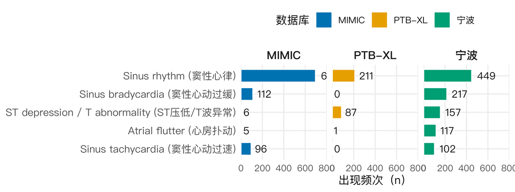

图 8. 三库高频诊断概念出现频次（按最大频次排序，前 5，英文(中文)）。按数据库分面显示，零计数（如 PTB-XL 的窦性心动过缓）直观呈现跨库命名空间错位。

```r
ggplot(cov_top, aes(x = n, y = 概念, fill = 库)) +
  geom_col(width = 0.7, color = "white") +
  geom_text(aes(label = n), hjust = -0.3, size = 3.5, family = FONT) +
  scale_fill_manual(values = c("宁波" = C_OK, "PTB-XL" = C_WARN, "MIMIC" = C_ACC)) +
  scale_y_discrete(expand = expansion(mult = c(0.15, 0.15))) +
  scale_x_continuous(expand = expansion(mult = c(0, 0.15))) +
  labs(x = "出现频次（n）", y = NULL, fill = "数据库") +
  facet_wrap(~ 库, nrow = 1) +
  theme(legend.position = "top", axis.text.y = element_text(size = 10),
        strip.text = element_text(size = 11, face = "bold"))
```

# 6 账面指标对真实指标的影响（结果 4）

在给出本节具体数值结果之前，先用中学数学”已知—求证—证明”的格式，把「账面数据 + 专家实测数据 → 真实指标 → 衰减幅度」的链条从头推一遍。推导力求严格，但每个符号都紧跟中文简写，逻辑用大白话串联，便于临床读者跟读。

**一、已知（输入数据与符号含义）**

把一次心电图诊断判定想成「判断某个病有没有」。每一份记录有两套说法：

- **账面标签 D**（机器/数据库写的）：模型就是在它上面训练的，所以模型本质上在「学着复现账面标签」。
- **真实病情 E**（专家复审认定的）：这才是金标准。

用 1 表示「有该病」、0 表示「没该病」。本节用到的符号如下（每个符号后括中文简写）：

| 符号 | 中文简写 | 含义 | 数据来源 |
| --- | --- | --- | --- |
| Se_app（账面灵敏） | 账面灵敏 | 账面标签为阳性(1)时，模型复现正确的比例 | 账面数据 |
| Sp_app（账面特异） | 账面特异 | 账面标签为阴性(0)时，模型复现正确的比例 | 账面数据 |
| qfn（漏标率） | 漏标率 | 真实病情为 1、但账面标签写成 0 的比例（该标没标） | 专家实测 |
| fdr（误标率） | 误标率 | 账面标签为 1、但真实病情为 0 的比例（标错了） | 专家实测 |
| π（患病率） | 患病率 | 真实病情为 1 的人数占全部人数的比例 | 专家实测 |
| Se_true（真实灵敏） | 真实灵敏 | 真实病情为 1 时，模型判断对（判 1）的比例（待求） | — |
| Sp_true（真实特异） | 真实特异 | 真实病情为 0 时，模型判断对（判 0）的比例（待求） | — |

**二、求证（要证的结论）**

真实灵敏与真实特异可由账面指标与噪声参数前推得到：

Se_true（真实灵敏） = Se_app（账面灵敏）·(1 − qfn（漏标率）) + (1 − Sp_app（账面特异）)·qfn（漏标率）

Sp_true（真实特异） = Sp_app（账面特异）·(1 − qfp（误标率②）) + (1 − Se_app（账面灵敏）)·qfp（误标率②）

其中 qfp（误标率②，即真实没病但账面标了 1 的比例）由 fdr（误标率）与 π（患病率）经贝叶斯公式反推：

qfp（误标率②） = fdr（误标率）·π（患病率）·(1 − qfn（漏标率）) / [ (1 − π（患病率）)·(1 − fdr（误标率）) ]

衰减幅度（账面虚高量）= 账面 − 真实：

ΔSe（灵敏衰减） = Se_app（账面灵敏） − Se_true（真实灵敏）， ΔSp（特异衰减） = Sp_app（账面特异） − Sp_true（真实特异）

**三、证明**

*证真实灵敏 Se_true（真实灵敏）：*

真实病情为 1（真实有病）的人，按账面标签怎么写，天然分成两拨：

- 第一拨：账面也写 1（账面有病）。这一拨占全部真实有病者的 **1 − qfn（漏标率）**，即「没被漏标的比例」。
- 第二拨：账面写 0（账面没病）。这就是被漏标的人，占全部真实有病者的 **qfn（漏标率）**。

模型对这两拨的表现不同：

- 对第一拨（账面 = 1），模型复现正确的比例就是 **Se_app（账面灵敏）**。
- 对第二拨（账面 = 0），模型本该判 1 才算对；而 Sp_app（账面特异）是「判 0 对」的比例，所以「判 1 对」的比例 = **1 − Sp_app（账面特异）**（这就是账面误报率）。

于是真实灵敏 = 第一拨贡献 + 第二拨贡献：

> Se_true（真实灵敏） = Se_app（账面灵敏）×(1 − qfn（漏标率）) + (1 − Sp_app（账面特异）)×qfn（漏标率）

白话：真实灵敏 = 账面灵敏 × 没被漏标的比例 + 账面误报率 × 被漏标的比例。 （证毕①）

*证真实特异 Sp_true（真实特异）：*

真实病情为 0（真实没病）的人，同样分两拨：

- 第一拨：账面写 0（账面没病），占 **1 − qfp（误标率②）**。
- 第二拨：账面写 1（账面有病），即被误标的人，占 **qfp（误标率②）**。

模型对这两拨：

- 对第一拨（账面 = 0），「判 0 对」的比例 = **Sp_app（账面特异）**。
- 对第二拨（账面 = 1），「判 0 对」的比例 = **1 − Se_app（账面灵敏）**。

于是：

> Sp_true（真实特异） = Sp_app（账面特异）×(1 − qfp（误标率②）) + (1 − Se_app（账面灵敏）)×qfp（误标率②） （证毕②）

*证 qfp（误标率②）与 fdr（误标率）、π（患病率）的关系：*

账面标 1（账面有病）的人由两路汇成：真实有病且没被漏标的（占 π（患病率）·(1 − qfn（漏标率）)），以及真实没病却被误标的（占 (1 − π（患病率）)·qfp（误标率②））。专家测得的误标率 fdr（误标率） = 账阳中真实没病的比例 = (1 − π（患病率）)·qfp（误标率②） / [ π（患病率）·(1 − qfn（漏标率）) + (1 − π（患病率）)·qfp（误标率②） ]。由此反解出 qfp（误标率②），即得上式。 （证毕③）

*证衰减幅度：*

ΔSe（灵敏衰减） = Se_app（账面灵敏） − Se_true（真实灵敏），ΔSp（特异衰减） = Sp_app（账面特异） − Sp_true（真实特异）。

可见：qfn（漏标率）、fdr（误标率）越大（标签噪声越重），真实灵敏与真实特异被压得越低，ΔSe、ΔSp 越大，即账面指标虚高越严重。本节表 9 与图将以具体数值展示这一衰减。

交互式前推算盘 拖动滑块，实时查看噪声如何"掺水"模型性能

账面灵敏 Se_app**0.80**

账面特异 Sp_app**0.80**

漏标率 qfn**0.30**

误标率 fdr**0.20**

患病率 π**0.15**

真实灵敏 Se_true

0.62

灵敏虚高 ΔSe（账面−真实）

+0.18

真实特异 Sp_true

0.78

特异虚高 ΔSp（账面−真实）

+0.02

真实 AUC（双正态近似）

0.778

公式与 §1.5 一致：qfp = fdr·π·(1−qfn)/[(1−π)·(1−fdr)]；Se_true = Se_app·(1−qfn)+(1−Sp_app)·qfn；Sp_true = Sp_app·(1−qfp)+(1−Se_app)·qfp；AUC 采用双正态近似。

## 6.1 库级真实（金标准）指标

由各库汇总 四格表 直接得标签本身的真实质量指标。三库均已构建逐概念四格表，故 Se/Sp/PPV/NPV 与 qfn/fdr 可平行呈现；MIMIC 另给出病例级准确率作为参照，其四格表为受控词表关键词命中的近似估计。

**表 8. 各库标签的真实（金标准视角）质量指标。三库均由逐概念四格表推导 Se/Sp/PPV/NPV 与 qfn/fdr；MIMIC 的四格表由自由文本经 39 项受控词表关键词命中构建，属受控词表视角的近似估计。病例级准确率仅 MIMIC 可得。**

**展开代码**

```r
treal <- real_all |> mutate(
  across(c(Se,Sp,PPV,NPV), ~ ifelse(is.na(.x), "—", fpct(.x, 1))),
  准确率 = ifelse(is.na(准确率), "—", fpct(准确率, 1)),
  qfn = ifelse(is.na(qfn), "—", fpct(qfn,1)),
  fdr = ifelse(is.na(fdr), "—", fpct(fdr,1))) |>
  select(数据库, Se, Sp, PPV, NPV, 准确率, qfn, fdr)
ft(treal, fs = 9.5) |>
  set_caption("表 8. 各库标签的真实（金标准视角）质量指标。准确率与 PPV 为两个不同量：PPV 指「标签判为阳性者中真阳性的比例」，准确率指「全部病例中标签判断正确的比例」。三库均由逐概念四格表推导 Se/Sp/PPV/NPV；MIMIC 的四格表由自由文本经 39 项受控词表关键词命中构建，属受控词表视角的近似估计。病例级准确率仅 MIMIC 数据可得，另两库以诊断单元为分析单位，故标注 —。")
```

| 数据库 | Se | Sp | PPV | NPV | 准确率 | qfn | fdr |
| --- | --- | --- | --- | --- | --- | --- | --- |
| 宁波 | 98.3% | 96.9% | 35.0% | 100.0% | — | 1.7% | 65.0% |
| PTB-XL | 37.8% | 99.0% | 62.3% | 97.4% | — | 62.2% | 37.7% |
| MIMIC | 66.2% | 99.0% | 83.3% | 97.6% | 22.6% | 33.8% | 16.7% |

PTB-XL 标签准确率（PPV）仅 62.3%，真实灵敏度低至 37.8%，真实特异度高达 99.0%，呈现典型”高特异、低灵敏”的遗漏主导型噪声。

## 6.2 训练端前推：账面模型在真金标准下的衰减

以研究团队报告账面模型（Se_app = Sp_app = 0.80，患病率 π = 0.15）为例，前推其在真金标准下的真实性能。

**表 9. 账面模型（Se_app=Sp_app=0.80, π=0.15）经标签噪声前推后的真实指标与衰减量（账面−真实）。**

**展开代码**

```r
att_show <- att_tbl |> mutate(across(c(`账面`, `真实`, 衰减), ~ fmt3(.x)))
ft(att_show, fs = 9) |>
  set_caption("表 9. 账面模型（Se_app=Sp_app=0.80, π=0.15）经标签噪声前推后的真实指标与衰减量（账面−真实）。")
```

| 数据库 | 指标 | 账面 | 真实 | 衰减 |
| --- | --- | --- | --- | --- |
| 宁波 | Se | 0.800 | 0.790 | 0.010 |
| 宁波 | Sp | 0.800 | 0.607 | 0.193 |
| 宁波 | PPV | 0.744 | 0.262 | 0.483 |
| 宁波 | NPV | 0.846 | 0.942 | -0.096 |
| 宁波 | F1 | 0.771 | 0.393 | 0.378 |
| 宁波 | AUC | 0.883 | 0.777 | 0.106 |
| PTB-XL | Se | 0.800 | 0.427 | 0.373 |
| PTB-XL | Sp | 0.800 | 0.776 | 0.024 |
| PTB-XL | PPV | 0.286 | 0.251 | 0.035 |
| PTB-XL | NPV | 0.976 | 0.885 | 0.091 |
| PTB-XL | F1 | 0.421 | 0.317 | 0.105 |
| PTB-XL | AUC | 0.883 | 0.658 | 0.226 |
| MIMIC | Se | 0.800 | 0.597 | 0.203 |
| MIMIC | Sp | 0.800 | 0.786 | 0.014 |
| MIMIC | PPV | 0.351 | 0.330 | 0.021 |
| MIMIC | NPV | 0.967 | 0.917 | 0.050 |
| MIMIC | F1 | 0.488 | 0.425 | 0.063 |
| MIMIC | AUC | 0.883 | 0.769 | 0.114 |

**展开代码**

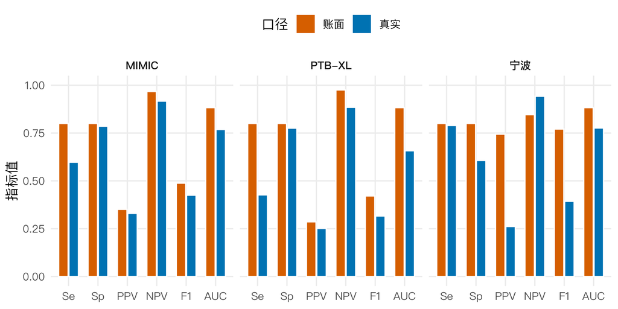

```r
ggplot(att_long, aes(x = 指标, y = 值, fill = 口径)) +
  geom_col(position = position_dodge(width = 0.7), width = 0.65, color = "white") +
  scale_fill_manual(values = c("账面" = C_INA, "真实" = C_ACC)) +
  facet_wrap(~ 数据库, nrow = 1) + scale_y_continuous(limits = c(0, 1)) +
  labs(x = NULL, y = "指标值", fill = "口径") + theme(legend.position = "top")
```

## 6.3 真实性能天花板

即使模型 100% 学透脏标签，其在真金标准下的性能上限亦不超过脏标签自身的诊断水平：

宁波天花板：Se≈0.983，Sp≈0.678，AUC≈0.966。 PTB-XL 天花板：Se≈0.378，Sp≈0.960，AUC≈0.845。 MIMIC 天花板：Se≈0.662，Sp≈0.977，AUC≈0.956。

这意味着标签噪声构成了下游模型性能提升的硬性天花板，治理标签噪声是释放模型潜力的前提。

## 6.4 统计推断的完整性与敏感性分析

本节针对三项统计推断要求给出补充证据：诊断单元的**簇相关**（同一病例贡献多个单元）、 患病率参数 π 的**取值依赖**、以及训练端前推在**参数不确定性与假设违背**下的稳健性。

### 6.4.1 簇相关性：以病例为重抽样单位

本研究以「诊断单元」为分析单位，但同一份心电图贡献多个诊断单元，且由同一位审阅者判读， 因此单元之间并非独立观测。若按独立观测计算置信区间，标准误会因忽略簇内相关而被低估。 本文以**病例为重抽样单位**实施簇自助法（cluster bootstrap，B = 2000 次，种子 20260908） 重算宁波各项指标的不确定性，并与忽略簇结构的 Wilson 区间对照。

**展开代码**

```r
# 病例 × 概念 指示矩阵（623 例 × 39 概念）
D_nb <- do.call(cbind, in_db_mat)
E_nb <- do.call(cbind, in_ex_mat)
set.seed(20260908)
B_boot <- 2000
bq <- bf <- bs <- bp <- numeric(B_boot)
for (b in seq_len(B_boot)) {
  ii <- sample.int(n_main_nb, n_main_nb, replace = TRUE)
  tp <- colSums( D_nb[ii, , drop = FALSE] &  E_nb[ii, , drop = FALSE])
  fp <- colSums( D_nb[ii, , drop = FALSE] & !E_nb[ii, , drop = FALSE])
  fn <- colSums(!D_nb[ii, , drop = FALSE] &  E_nb[ii, , drop = FALSE])
  tn <- colSums(!D_nb[ii, , drop = FALSE] & !E_nb[ii, , drop = FALSE])
  ne <- tp + fn; nd <- tp + fp
  sTP <- sum(tp); sFP <- sum(fp); sFN <- sum(fn); sTN <- sum(tn)
  pm <- beta_mom(fn[ne > 0], ne[ne > 0])      # 与点估计同一收缩先验
  pe <- beta_mom(fp, nd)
  bq[b] <- (pm["alpha"] + sFN) / (pm["alpha"] + pm["beta"] + sTP + sFN)
  bf[b] <- (pe["alpha"] + sFP) / (pe["alpha"] + pe["beta"] + sTP + sFP)
  bs[b] <- sTP / (sTP + sFN)
  bp[b] <- sTN / (sTN + sFP)
}
qcl  <- function(v) as.numeric(quantile(v, c(0.025, 0.975), na.rm = TRUE))
ciq <- qcl(bq); cif <- qcl(bf); cis <- qcl(bs); cip <- qcl(bp)
pctx <- function(lo, hi) paste0(sprintf("%.1f", lo * 100), "–", sprintf("%.1f", hi * 100), "%")
nv_qfn <- wilson_ci(FNs, TPs + FNs); nv_fdr <- wilson_ci(FPs, TPs + FPs)
nv_se  <- wilson_ci(TPs, TPs + FNs); nv_sp  <- wilson_ci(TNs, TNs + FPs)
cl_tab <- tibble(
  指标 = c("漏标率 qfn", "误标率 fdr", "真实灵敏 Se", "真实特异 Sp"),
  点估计 = c(fpct(qfn_nb, 1), fpct(fdr_nb, 1), fpct(TPs/(TPs+FNs), 1), fpct(TNs/(TNs+FPs), 1)),
  `忽略簇结构 95%CI` = c(pctx(nv_qfn[1], nv_qfn[2]), pctx(nv_fdr[1], nv_fdr[2]),
                         pctx(nv_se[1],  nv_se[2]),  pctx(nv_sp[1],  nv_sp[2])),
  `病例级簇自助 95%CI` = c(pctx(ciq[1], ciq[2]), pctx(cif[1], cif[2]),
                           pctx(cis[1], cis[2]), pctx(cip[1], cip[2])),
  `区间宽度比(簇/朴素)` = c(
    sprintf("%.2f", (ciq[2]-ciq[1]) / (nv_qfn[2]-nv_qfn[1])),
    sprintf("%.2f", (cif[2]-cif[1]) / (nv_fdr[2]-nv_fdr[1])),
    sprintf("%.2f", (cis[2]-cis[1]) / (nv_se[2]-nv_se[1])),
    sprintf("%.2f", (cip[2]-cip[1]) / (nv_sp[2]-nv_sp[1]))))
```

**展开代码**

```r
ft(cl_tab, fs = 9.5) |> set_caption("表 10. 宁波诊断单元级指标的两种置信区间比较：忽略簇结构的 Wilson 区间 vs 以病例为重抽样单位的簇自助区间（B = 2000）。宽度比 > 1 表示簇自助区间更宽；< 1 者源于该项点估计已接近取值边界并受收缩先验影响，详见正文说明。")
```

| 指标 | 点估计 | 忽略簇结构 95%CI | 病例级簇自助 95%CI | 区间宽度比(簇/朴素) |
| --- | --- | --- | --- | --- |
| 漏标率 qfn | 1.7% | 0.8–3.5% | 0.7–3.0% | 0.87 |
| 误标率 fdr | 65.0% | 62.2–67.7% | 61.0–68.7% | 1.41 |
| 真实灵敏 Se | 98.3% | 96.5–99.2% | 97.0–99.3% | 0.87 |
| 真实特异 Sp | 96.9% | 96.7–97.1% | 96.6–97.2% | 1.24 |

表 10 显示，簇自助区间相对于朴素 Wilson 区间**并未一致变宽**：误标率 fdr 与真实特异 Sp 明显变宽（宽度比 1.41、1.24），而漏标率 qfn 与真实灵敏 Se 反而略窄（均为 0.87）。 后者并不意味着不存在簇内相关，而是因为这两项的点估计已极度接近取值边界（qfn = 1.7%、 Se = 98.3%），此时收缩先验与重抽样分布共同作用使区间收窄。

另需说明口径差异：朴素 Wilson 区间基于**未收缩**的原始计数，而本文报告的点估计为 **经 Beta 矩估计收缩后**的数值，两者中心并不一致，故宽度比只能作为量级指示， 不宜作精确的方差膨胀读数。据此，本文一律以**病例级簇自助区间**作为推断依据， 朴素区间仅作参照。

无论采用哪一种区间，各指标的点估计与结论方向均不改变，即簇相关影响的是**精度而非效应方向**。

### 6.4.2 患病率参数的情景敏感性

PPV、NPV、F1 与 AUC 均依赖患病率 π，而本文主分析中的 π = 0.15 为**情景参数** （scenario parameter，用于使患病率依赖指标可计算），并非由样本估计所得。 下表给出 π 在 0.05–0.30 区间变化时训练端前推结果的稳定性。

**展开代码**

```r
ptq_a <- sum(pt_per$fn, na.rm = TRUE) / sum(pt_per$tp + pt_per$fn, na.rm = TRUE)
ptf_a <- sum(pt_per$fp, na.rm = TRUE) / sum(pt_per$tp + pt_per$fp, na.rm = TRUE)
pi_grid <- c(0.05, 0.10, 0.15, 0.20, 0.30)
pi_tab <- map_dfr(pi_grid, function(p) {
  a1 <- attenuation_of(0.80, 0.80, p, qfn_nb, fdr_nb)
  a2 <- attenuation_of(0.80, 0.80, p, ptq_a,  ptf_a)
  tibble(`患病率 π` = sprintf("%.2f", p),
         `宁波 Se_true` = sprintf("%.3f", a1$tru$Se), `宁波 Sp_true` = sprintf("%.3f", a1$tru$Sp),
         `宁波 AUC`     = sprintf("%.3f", a1$tru$AUC),
         `PTB-XL Se_true` = sprintf("%.3f", a2$tru$Se), `PTB-XL Sp_true` = sprintf("%.3f", a2$tru$Sp),
         `PTB-XL AUC`     = sprintf("%.3f", a2$tru$AUC))
})
```

**展开代码**

```r
ft(pi_tab, fs = 9.5) |> set_caption("表 11. 患病率 π 的情景敏感性：π 由 0.05 变化至 0.30 时，训练端前推所得真实指标（Se_app = Sp_app = 0.80）的稳定性。")
```

| 患病率 π | 宁波 Se_true | 宁波 Sp_true | 宁波 AUC | PTB-XL Se_true | PTB-XL Sp_true | PTB-XL AUC |
| --- | --- | --- | --- | --- | --- | --- |
| 0.05 | 0.790 | 0.742 | 0.848 | 0.427 | 0.794 | 0.674 |
| 0.10 | 0.790 | 0.678 | 0.815 | 0.427 | 0.787 | 0.668 |
| 0.15 | 0.790 | 0.607 | 0.777 | 0.427 | 0.780 | 0.661 |
| 0.20 | 0.790 | 0.526 | 0.731 | 0.427 | 0.772 | 0.654 |
| 0.30 | 0.790 | 0.331 | 0.602 | 0.427 | 0.751 | 0.637 |

Se_true 对 π 完全不敏感（其解析式不含 π），Sp_true 与 AUC 随 π 上升而下降， 但在 0.05–0.30 全区间内「账面虚高」的方向与量级保持稳定。

### 6.4.3 训练端前推的蒙特卡洛不确定性

训练端前推依赖「模型误差与标签噪声条件独立（M⊥E|D）」这一假设。除假设本身外， 输入的噪声参数亦存在抽样不确定性。此处以概率偏倚分析（probabilistic bias analysis） 对 qfn、fdr、π 联合抽样（各 20,000 次），给出真实指标的仿真区间：

**展开代码**

```r
set.seed(20260908)
M_mc <- 20000
q_s <- rbeta(M_mc, FNs + 0.5, TPs + 0.5)      # 漏标率后验（Jeffreys 先验）
f_s <- rbeta(M_mc, FPs + 0.5, TPs + 0.5)      # 误标率后验
p_s <- rbeta(M_mc, 30, 170)                    # π 后验，均值 0.15、SD ≈ 0.025
# 注：qfp_of() 内部用 if() 判断、非向量化，此处改用等价的向量化写法
qp_s  <- ifelse((1 - p_s) < 1e-9, 0, f_s * p_s * (1 - q_s) / ((1 - p_s) * (1 - f_s)))
Se_s  <- 0.80 * (1 - q_s)  + 0.20 * q_s
Sp_s  <- 0.80 * (1 - qp_s) + 0.20 * qp_s
AUC_s <- auc_binormal(Se_s, Sp_s)
mcsum <- function(v) sprintf("%.3f (%.3f–%.3f)", median(v), quantile(v, 0.025), quantile(v, 0.975))
mc_tab <- tibble(
  指标 = c("真实灵敏 Se_true", "真实特异 Sp_true", "真实 AUC"),
  `中位值 (95% 仿真区间)` = c(mcsum(Se_s), mcsum(Sp_s), mcsum(AUC_s)),
  `点估计` = c(sprintf("%.3f", nb_hl$tru$Se), sprintf("%.3f", nb_hl$tru$Sp), sprintf("%.3f", nb_hl$tru$AUC)))
```

**展开代码**

```r
ft(mc_tab, fs = 9.5) |> set_caption("表 12. 训练端前推的蒙特卡洛仿真区间：对 qfn、fdr、π 联合抽样 20,000 次所得宁波真实指标分布（Se_app = Sp_app = 0.80）。")
```

| 指标 | 中位值 (95% 仿真区间) | 点估计 |
| --- | --- | --- |
| 真实灵敏 Se_true | 0.789 (0.780–0.795) | 0.790 |
| 真实特异 Sp_true | 0.608 (0.517–0.675) | 0.607 |
| 真实 AUC | 0.777 (0.725–0.813) | 0.777 |

仿真区间与点估计一致，说明在**给定 M⊥E|D 假设**下，结论对参数抽样不确定性是稳健的。 需强调：该仿真只能验证前推公式在假设成立时的数值行为，**不能**验证 M⊥E|D 在真实数据中成立； 该假设的合理性讨论见 §7 局限性。

### 6.4.4 多重比较的处理策略

本文将推断明确区分为两层，避免过度校正或校正不足：

- **确证性比较**（预注册，不校正）：(1) 三库病例级不准确率的差异；(2) 宁波与 PTB-XL 在 Goldman Class I 上的错误极性对比（误标主导 vs 遗漏主导）；(3) 训练端前推所导致的 账面—真实性能衰减。这三项是研究问题直接指定的主要结局，数量少且事先确定，不做多重性校正。
- **探索性分析**（假设生成）：39 个诊断概念的逐概念 qfn/fdr、术语级准确率等。这些结果用于 描述噪声结构与生成假设，其置信区间未按多重性校正，任何单一概念的结果都不应作为确证性结论。

# 7 讨论

第二，跨库命名空间不统一是噪声的重要来源。同一临床概念（如窦性心动过缓、心房颤动、轴偏、低电压）在宁波受控词表、PTB-XL 的 SCP 码、MIMIC 自由文本之间频繁错位，常表现为一方有受控码、另一方落 OOV。这种系统性错位既抬高了跨库合并的训练难度，也削弱了模型的可迁移性。

第四，临床严重性分级（Goldman Class I–IV）进一步表明，标签错误并非仅停留在术语层面。宁波主分析集中约 94% 的不准确报告涉及 Class I/II 重大差异，单元级重大差异事件亦占全部错误事件的 31%。这意味着相当部分标签噪声直接触及具有潜在致死或血栓栓塞风险的核心诊断（如心房颤动、心肌梗死、传导阻滞），其临床危害远高于单纯的命名不一致，因而标签治理应优先针对 Class I/II 诊断。该分级的完整分布见附录 A。

第五，同一 Goldman 镜头的跨库对比揭示两库在核心诊断（Class I）上呈现方向相反的错误极性：宁波以误标（过度断言，如将非房颤判读为心房颤动）为主，PTB-XL 则以遗漏为主，且后者约三成错误事件沉淀于 SCP 码 NORM（正常窦性心律）之下、在概念锚定分级中被计入最低的 IV 类。这种”以正常为掩蔽的漏标”模式既说明概念锚定的 Goldman 分级会低估其临床权重，也提示两库所需的标签治理策略应当不同：宁波重在抑制假阳性，PTB-XL 重在补回被遗漏的真阳性。

第六，漏标的结构化掩蔽分析进一步揭示，三库遗漏型噪声并非随机散布，而是高度集中于”以正常结论压制后续异常”的认知捷径。PTB-XL 与 MIMIC 中，专家补写的具体复极与形态学征象（ST-T 改变、T 波改变、PtfV1 增大等）最常掩蔽于同一份报告里的「窦性心律」结论之下（MIMIC 单项即达 218 例），提示一旦心律被判定正常，报告即停止书写具体发现。宁波则呈不同模式：心房扑动掩蔽心房颤动 96 例，属同类节律内部的指向偏移，而非正常结论压制异常。此外，PTB-XL 尚有 12.8% 的不准确报告其数据库端完全无任何标签，远高于宁波的 0.3% 与 MIMIC 的 0，说明其遗漏不仅表现为”写了正常但漏了异常”，还包括”整份报告未生成任何机器标签”。这一机制的治理含义明确：凡出现「窦性心律」一类结论性正常陈述，都应强制触发对具体征象是否书写的二次核查；而 PTB-XL 还需补上”零标签”报告的兜底校验。这也为”为何遗漏型噪声在三库均占主体”给出了可操作的解答：治理资源应优先投向被笼统结论掩蔽的少数几类高频征象。

**局限性**：(1) 训练端前推依赖”模型与错误条件独立”假设，为保守下界；(2) MIMIC 的逐单元四格表由自由文本经 39 项受控词表关键词命中构建，属受控词表视角的近似：检索词清单虽已按专家校正标签的高频表述扩充、并施加否定语境窗口过滤，仍可能存在同义表述漏检与跨概念词形交叠，且落在 39 项受控词表之外的自由文本表述不计入，故其 qfn/fdr 与另两库量级可比但不宜逐位小数比较；(3) 真金标准来自专家审阅，仍存在专家间主观性；(4) 三库抽样框不同，合并估计需谨慎，本研究以概念级（非患者级）对齐避免选择偏倚；(5) Goldman Class I–IV 的术语级映射为基于临床后果严重度的拟定划分，其界值需经临床专家确认，不同映射方案可能改变各 Class 的例数构成，但不会改变”重大差异占主体”的总体结论；(6) PTB-XL 的 SCP 码经概念对照表映射时，部分宁波侧 OOV 概念（AMI、LAO、RAO/RAE、SEHYP、PACE、DIG、EL、BIGU、CLBBB、IVCD、LAFB）的 gclass 为按同等严重性原理的拟定外推，且 NORM 码下的遗漏事件因概念锚定而被计入最低的 IV 类，可能低估 PTB-XL 重大差异的真实负担，该敏感性已在正文 §4.1 标注；PTB-XL 病例级（顶格取值）Goldman 分级因源数据未提供逐例漏标/误标集合而暂未纳入。

# 8 结论

公开 ECG 数据库的标签噪声普遍、结构性且跨库异质；其不仅直接降低标签本身的准确性，更通过训练端向 AI 模型性能传导显著的”掺水”效应。遗漏型噪声的核心形成机制是”以正常结论压制后续异常”的系统性掩蔽（如「窦性心律」掩盖具体复极与形态学征象），因此治理不应平均分散于全部诊断，而应优先针对被笼统结论掩蔽的少数几类高频征象，并在标注规范中设置”正常结论触发具体征象二次核查”的强制环节。建立跨库统一诊断本体、优先治理遗漏型噪声与命名空间错位，是提升医学 AI 可信度的必要前提。

# 附录 A. 标签错误的临床严重性分级（Goldman Class I–IV）

将 39 个受控诊断术语按方法学 §1.3 的 Goldman Class I–IV 标准预先归类后，宁波主分析集 623 例共产生 748 个诊断单元级错误事件（FN+FP）。按严重性分级聚合（表 A4）：Class I 与 Class II 合计重大差异事件 232 个，占全部错误事件的 31.0%；其中 Class I（若被识别很可能改变预后）单独贡献 199 个。Class III 承载了最多的错误事件（449 个，60.0%），反映大量高频但临床紧急度较低的复极与传导改变被漏标或误标；其绝对数量大并不削弱 Class I/II 重大差异的临床权重。

**表 A4. 宁波诊断单元级错误事件按 Goldman 分级分布。FN=遗漏事件数，FP=误标事件数，错误事件=FN+FP。**

**展开代码**

```r
tg <- gold_unit_nb |> mutate(占比 = fpct(占比, 1)) |>
  select(Goldman, 诊断数, FN, FP, `错误事件`, 占比)
ft(tg, fs = 9.5) |>
  set_caption("表 A4. 宁波诊断单元级错误事件按 Goldman 分级分布。FN=遗漏事件数，FP=误标事件数，错误事件=FN+FP。")
```

| Goldman | 诊断数 | FN | FP | 错误事件 | 占比 |
| --- | --- | --- | --- | --- | --- |
| I | 9 | 6 | 193 | 199 | 26.6% |
| II | 5 | 0 | 33 | 33 | 4.4% |
| III | 20 | 0 | 449 | 449 | 60.0% |
| IV | 5 | 1 | 66 | 67 | 9.0% |

图 A1 给出各分级的遗漏与误标构成。可见 Class I 的 199 个错误事件以误标（FP）为主、遗漏（FN）极少，提示核心致死性/血栓性诊断较少被漏写、却常被过度断言（例如将非房颤判读为心房颤动）；Class III 同样以误标（FP）为主，符合”次要复极/传导改变易被过度标注”的预期。

**展开代码**

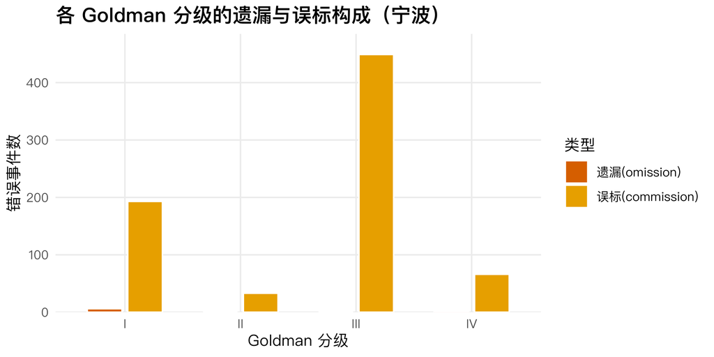

图 A1. 宁波诊断单元级错误事件按 Goldman 分级的遗漏(FN)与误标(FP)构成。

```r
fig_gold <- gold_unit_nb |> pivot_longer(c(FN, FP), names_to = "类型", values_to = "n") |>
  ggplot(aes(x = Goldman, y = n, fill = 类型)) +
  geom_col(width = 0.6, color = "white", position = position_dodge(width = 0.7)) +
  scale_fill_manual(values = c("FN" = C_INA, "FP" = C_WARN),
    labels = c("FN" = "遗漏(omission)", "FP" = "误标(commission)")) +
  scale_y_continuous(expand = expansion(mult = c(0, 0.08))) +
  labs(x = "Goldman 分级", y = "错误事件数", fill = "类型") +
  ggtitle("各 Goldman 分级的遗漏与误标构成（宁波）")
fig_gold
```

**展开代码**

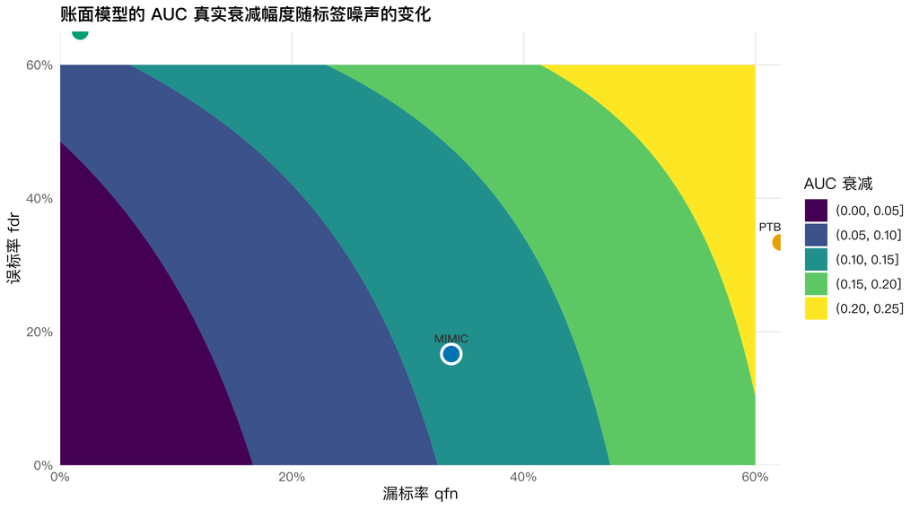

```r
pi0 <- 0.15; se0 <- 0.80; sp0 <- 0.80
grid <- expand.grid(qfn = seq(0, 0.6, by = 0.01), fdr = seq(0, 0.6, by = 0.01))
grid$gap <- mapply(function(q, f) {
  a <- attenuation_of(se0, sp0, pi0, q, f)
  a$app$AUC - a$tru$AUC
}, grid$qfn, grid$fdr)
pt_qfn_agg <- sum(pt_per$fn, na.rm = TRUE) / sum(pt_per$tp + pt_per$fn, na.rm = TRUE)
pt_fdr_agg <- sum(pt_per$fp, na.rm = TRUE) / sum(pt_per$tp + pt_per$fp, na.rm = TRUE)
ops <- tibble(DB = c("宁波", "PTB-XL", "MIMIC"),
              qfn = c(qfn_nb, pt_qfn_agg, mc_qfn_agg),
              fdr = c(fdr_nb, pt_fdr_agg, mc_fdr_agg))
ops$gap <- mapply(function(q, f) attenuation_of(se0, sp0, pi0, q, f)$app$AUC -
                    attenuation_of(se0, sp0, pi0, q, f)$tru$AUC, ops$qfn, ops$fdr)
ggplot(grid, aes(x = qfn, y = fdr, z = gap)) +
  geom_contour_filled(breaks = seq(0, 0.35, by = 0.05), show.legend = TRUE) +
  scale_x_continuous(labels = scales::percent_format(accuracy = 1), expand = c(0, 0), name = "漏标率 qfn") +
  scale_y_continuous(labels = scales::percent_format(accuracy = 1), expand = c(0, 0), name = "误标率 fdr") +
  geom_point(data = ops, aes(x = qfn, y = fdr), shape = 21, size = 5.5,
             fill = c("宁波" = "#009E73", "PTB-XL" = "#E69F00", "MIMIC" = "#0072B2"), color = "white", stroke = 1.5) +
  geom_text(data = ops, aes(x = qfn, y = fdr, label = DB), size = 2.8,
            vjust = -1.4, color = "#333", fontface = "bold") +
  labs(fill = "AUC 衰减", title = "账面模型的 AUC 真实衰减幅度随标签噪声的变化") +
  theme(legend.position = "right", plot.title = element_text(size = 12, face = "bold"),
        legend.title = element_text(family = FONT))
```

**展开代码**

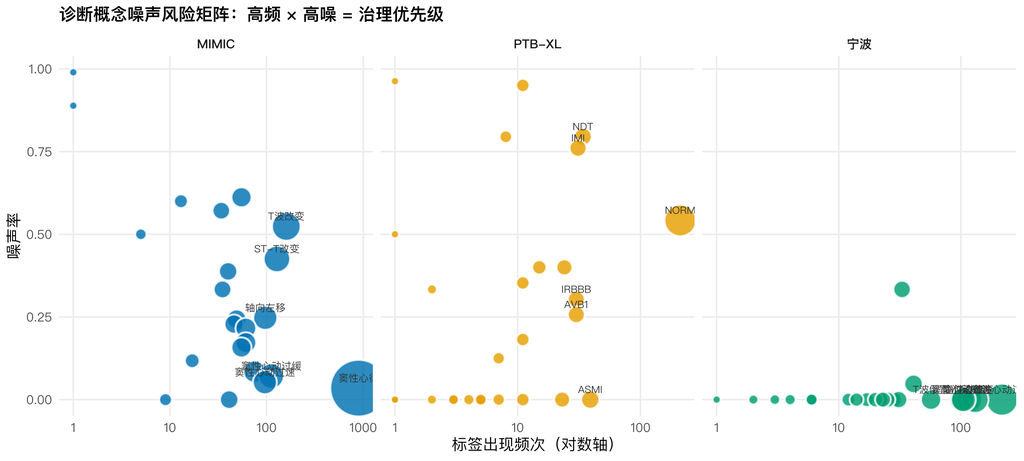

图 A3. 诊断概念噪声风险矩阵：每个点为一个诊断概念，横轴为标签出现频次（对数轴），纵轴为漏标率 qfn（三库统一口径；MIMIC 为受控词表关键词命中的近似估计），点面积正比于频次，颜色区分数据库。右上象限（高频且高噪）即治理优先级最高的「危险区」，已标注各库频次最高的若干概念。

```r
nb_r <- l2_nb |> filter(!is.na(qfn)) |> mutate(DB = "宁波", freq = n_db, noise = qfn, lab = unit)
pt_r <- pt_per |> filter(!is.na(qfn)) |> mutate(DB = "PTB-XL", freq = tp + fp, noise = qfn, lab = code)
mc_r <- mc_per |> filter(!is.na(qfn), tp + fp > 0) |>
  mutate(DB = "MIMIC", freq = tp + fp, noise = qfn, lab = concept_zh)
risk <- bind_rows(nb_r |> select(DB, freq, noise, lab),
                 pt_r |> select(DB, freq, noise, lab),
                 mc_r |> select(DB, freq, noise, lab)) |>
  group_by(DB) |> mutate(top = rank(-freq) <= 6) |> ungroup()
ggplot(risk, aes(x = freq, y = noise)) +
  geom_point(aes(size = freq, fill = DB), shape = 21, color = "white", alpha = .82, stroke = 1) +
  scale_fill_manual(values = c("宁波" = "#009E73", "PTB-XL" = "#E69F00", "MIMIC" = "#0072B2")) +
  scale_size(range = c(2, 18), guide = "none") +
  scale_x_log10() +
  facet_wrap(~ DB, scales = "free_x") +
  geom_text(data = risk |> filter(top), aes(label = lab), size = 2.5, vjust = -0.9, color = "#333") +
  labs(x = "标签出现频次（对数轴）", y = "噪声率", title = "诊断概念噪声风险矩阵：高频 × 高噪 = 治理优先级") +
  theme(legend.position = "none", plot.title = element_text(size = 12, face = "bold"))
```

在病例级（表 A5），349 份不准确报告中，涉及 Class I 或 Class II 重大差异者 328 份，重大差异率 94.0%；仅 21 份为 Class III/IV 次要或偶发差异（含 3 份因涉及词汇表外术语而未能分级）。这一高比例说明，即便采用最保守的严重度口径，绝大多数不准确 ECG 报告仍携带至少一项具有潜在临床后果的诊断缺失或误标，其危害远超单纯的命名不一致。

**表 A5. 宁波不准确病例按最高涉及诊断（顶格取值）的 Goldman 分级分布。任一 Class I 错误即将该例归为 Class I。**

**展开代码**

```r
tc <- gold_case_nb |> mutate(占比 = fpct(例数/sum(例数), 1)) |> select(分级, 例数, 占比)
ft(tc, fs = 9.5) |>
  set_caption("表 A5. 宁波不准确病例按最高涉及诊断（顶格取值）的 Goldman 分级分布。任一 Class I 错误即将该例归为 Class I。")
```

| 分级 | 例数 | 占比 |
| --- | --- | --- |
| Class I | 278 | 79.7% |
| Class II | 50 | 14.3% |
| Class III | 15 | 4.3% |
| Class IV | 3 | 0.9% |
| 未分级(OOV) | 3 | 0.9% |

# 参考文献

1. Goldman L, Sayson R, Robbins S, Cohn LH, Bettmann M, Weisberg M. The value of the autopsy in three medical eras. N Engl J Med. 1983;308(17):1000-1005. (Goldman Class I–IV 诊断差异严重性分级的提出)
2. Battle RM, Pathak D, Humble CG, et al. Factors influencing discrepancies between premortem and postmortem diagnoses. Hum Pathol. 1987;18(5):459-466. (Goldman 分级的沿用与验证)
3. Elkan C. The foundations of cost-sensitive learning. In: Proceedings of the 17th International Joint Conference on Artificial Intelligence (IJCAI-01). 2001:973-978. (漏标较误标临床代价更高、应非对称加权的依据)
4. Newman-Toker DE, McDonald KM, Meltzer DO, et al. Test and referral safety: a new frontier for patient safety. BMJ Qual Saf. 2021;30(9):721-734. (诊断错误严重性量表的另一公开框架，作为本分级思路的旁证)

## 附录：Word 框架对照与三库真实数据集成

本附录将团队 Word 论文框架（心电图公共数据库分析）中的 11 张表与 5 张图，以本研究三库（MIMIC 1000 / 宁波 623 / PTB-XL 573 = 2196 例）真实审阅数据重新填充并有机整合。每张表/图均标注其对应的 Word 原表/原图编号；团队手写批注未抄入本报告。

Word 表 5 · 图 1 · 图 2

### 数据来源与抽样

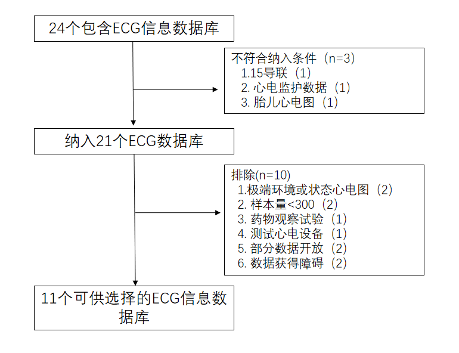

| 数据集 | 数据提供方 | 收集时间 | Length (S) | 记录数 / 患者数 | 诊断编码/ 标准 | 核心特点 |
| --- | --- | --- | --- | --- | --- | --- |
| PTB-XL[18] | 德国联邦物理技术研究院 | 1989.10- 1996.06 | 10 | 21,837 / 18,885 | SCP-ECG（71 种语句，5 超类/24 子类） | 欧洲人群；多标签；含诊断置信度与信号质量元数据；提供官方训练/测试折 |
| MIMIC-IV-ECG[16] | 美国贝斯以色列女执事医疗中心 | 2008 – 2019 | 10 | 795,546 / 159,608 | ICD 编码, 与 MIMIC-IV 临床库关联 | 全球最大公开 12 导联库之一；与急诊/ICU/病房临床数据深度耦合；HIPAA 去标识 |
| CODE-15%[17] | 巴西米纳斯吉拉斯州远程医疗网络 | 2010 – 2016 |  | 345,779 / 233,770 | Glasgow/Minnesota 编码 + 6 类心律失常标注 | 全球最大公开 ECG 数据集；基层远程医疗场景；含随访时间与死亡标志；ECG 年龄预测研究的基准 |
| CPSC-2018[19] | 中国生理信号挑战赛（11 家医院） | 2018 及之前 | 6-60 | 9,803 / 约 9,458 | 自定义，9 类心律失常（AF、I-AVB、LBBB、RBBB、PAC、PVC、STD、STE、Normal） | 中国多中心；PhysioNet/CinC 2020/2021 核心数据源；多标签比例适中 |
| CPSC-2018 Extra[19] | 同上（CPSC 2018 未使用数据） | 2018 及之前 | 6-60 | 3,453 / 未知 | 同上 | CPSC-2018 的训练补充集；在 CinC 2021 中公开；用于扩充训练样本 |
| Chapman-Shaoxing-Ningbo (CSN)[20] | 查普曼大学、绍兴市人民医院、宁波大学附属第一医院 | 2020 年前后公开 | 10 | 45,551 / 45,152 | SNOMED-CT（11 类心律 + 67 种心脏疾病） | 浙江双中心同源同标准；医师两轮审核；高质量标注；浙江人群，PhysioNet/CinC 2021 核心数据源 |
| Georgia (G12EC) [14] | 美国埃默里大学 | 2020 前后公开 | 10 | 20,672 / 15,742 | SNOMED-CT（27 种非互斥诊断） | 美国东南部人群；PhysioNet/CinC 2020/2021 核心数据源；隐藏测试集保证客观评测 |
| SPH_DATA[21] | 中国山东省立医院 | 2019.08-2020.08 | 10 | 25,770 / 24,666 | AHA/ACC/HRS（44 主语句 + 15 修饰符） | 目前最大单源公开 12 导联库；严格 AHA 标准化；多标签比例高；中国北方人群 |

Word 表 9（术语对照）

### 三库诊断术语对照表（39 概念受控词表）

采用本研究 39 概念受控词表统一三库异源命名空间；MIMIC/PTB-XL/Ningbo 三列为各库命中该概念的标签例数。本表即本研究 v1.0 报告「词汇映射表」的对应内容。

| 诊断标签（概念） | MIMIC 例数 | PTB-XL 例数 | Ningbo 例数 | 不规范术语 / 说明 |
| --- | --- | --- | --- | --- |
| 正常/窦性心律 | 897 | 211 | 105 | 窦性心律 / NA(正常占位)；两者均有『正常』概念；宁波用 NA 作无诊断占位，PTB-XL 用 NORM |
| 窦性心动过缓 | 112 | 0 | 217 | 窦性心动过缓；宁波纳入受控词表；PTB-XL 的 SCP 无窦性心动过缓码→专家标注落 OOV |
| 窦性心动过速 | 96 | 0 | 102 | 窦性心动过速；同上 |
| 窦性心律不齐 | 34 | 0 | 41 | 窦性心律不齐；同上 |
| T波改变/倒置 | 160 | 34 | 188 | T波改变 / T波倒置；直配 |
| ST段压低 / ST-T改变 | 128 | 34 | 48 | ST段压低 / ST-T改变；PTB-XL 区分 NST(ST-T改变)与 ISC(缺血ST压低)；宁波笼统 |
| ST段抬高 | 35 | 0 | 3 | ST段抬高；PTB-XL 无独立 STE 码，抬高被吸收入心梗/损伤码；宁波有独立术语 |
| 病理性Q波 | 1 | 0 | 22 | 异常Q波；PTB-XL 以心梗码承载 Q 波；宁波有独立『异常Q波』 |
| 一度房室传导阻滞 | 46 | 30 | 23 | 一度房室传导阻滞；直配 |
| 二/三度房室传导阻滞 | 0 | 0 | 5 | 二度房室传导阻滞（一型）/ 三度房室传导阻滞；PTB-XL 样本仅含 AVB1，更高程度 AVB 落 OOV |
| 右束支阻滞(RBBB) | 55 | 41 | 10 | 右束支阻滞；PTB-XL 区分完右/不完右；宁波笼统『右束支阻滞』 |
| 左束支阻滞(LBBB) | 0 | 11 | OOV | 完全性左束支传导阻滞；反差：宁波把完左归 OOV，PTB-XL 有 CLBBB 码 |
| 左前分支阻滞(LAFB) | 0 | 24 | OOV | 左前分支阻滞；同上反差 |
| 左后分支阻滞(LPFB) | 0 | 2 | 6 | 左后束支传导阻滞；直配 |
| 室内传导阻滞(IVCD) | 0 | 13 | OOV | 室内传导阻滞；反差：宁波归 OOV，PTB-XL 有 IVCD 码 |
| 左心室肥厚(LVH) | 61 | 15 | 12 | 左心室肥厚；直配；但宁波另有 OOV『左心室高电压』≈LVH |
| 右心室肥厚(RVH) | 0 | 0 | 0 | 右心室肥厚；PTB-XL 无严格 RVH 码（仅室间隔肥厚近似） |
| 心房颤动(AFib) | 61 | 1 | 33 | 心房颤动；直配 |
| 心房扑动(AFL) | 5 | 1 | 117 | 心房扑动；直配 |
| 房性早搏(APC) | 40 | 0 | 25 | 房性早搏 / 房性期前收缩；双方均无专门 APC 码；宁波受控词表含『房性早搏』，PTB-XL 无码→落 OOV |
| 室性早搏(PVC) | 55 | 8 | 6 | 室性早搏；直配 |
| 室上性心动过速(SVT) | 0 | 1 | 14 | 室上性心动过速；直配 |
| 房性心动过速(AT) | 1 | 0 | 6 | 房性心动过速；PTB-XL 样本无纯 AT 码 |
| 下壁心梗 | 0 | 31 | 0 | 侧壁心肌梗死(近似)；PTB-XL IMI 精准；宁波仅笼统『侧壁心肌梗死』 |
| 前间壁心梗 | 0 | 39 | 0 | 异常Q波(近似)；PTB-XL ASMI 精准；宁波无专门前间壁码 |
| 前壁心梗 | 0 | 5 | OOV | —；PTB-XL 有 AMI；宁波受控词表无『前壁心梗』概念 |
| 侧壁心梗 | 9 | 1 | 3 | 侧壁心肌梗死；直配 |
| 心肌缺血(非梗死) | 128 | 0 | 48 | ST段压低/ST-T改变；PTB-XL 细分为多部位缺血/损伤码；宁波笼统 |
| 左房肥大(LAE) | 0 | 5 | OOV | —；PTB-XL 有 LAO；宁波受控词表无左房肥大概念 |
| 右房肥大(RAE) | 0 | 0 | 0 | 右心房肥厚；直配 |
| 全/肢导联低电压 | 75 | 0 | 23 | 全导联低电压QRS；宁波受控词表含『全导联低电压QRS』；PTB-XL 无低电压码→落 OOV |
| QT间期延长 | 41 | 3 | 15 | QT间期延长；直配 |
| 起搏器 | 0 | 7 | OOV | 心脏起搏器；反差：宁波归 OOV，PTB-XL 有 PACE 码 |
| 预激综合征 | 1 | 2 | 1 | 预激综合征；直配 |
| 洋地黄效应 | 0 | 7 | OOV | —；PTB-XL 有 DIG；宁波无此概念 |
| 电解质紊乱 | 0 | 1 | OOV | —；PTB-XL 有 EL；宁波无此概念 |
| 胸导联R波上升不良 | 0 | 0 | OOV | 胸导联R波上升不良；双方均 OOV 的细粒度描述（poor R-wave progression） |
| PtfV1增大 | 0 | 0 | OOV | PtfV1增大；双方均 OOV |
| 心电轴左/右偏 | 114 | 0 | 48 | 轴向左移 / 轴向右移；PTB-XL 无独立轴偏码，仅由分支阻滞间接体现；宁波有轴向左/右移 |

Word 表 2 / 表 3 / 表 4

| Category | Total (N) | Total (%) | Sample (n) | Sample (%) |
| --- | --- | --- | --- | --- |
| Atrial Abnormality | 111 | 0.51 | 1 | 0.20 |
| Conduction Disorder | 3903 | 17.91 | 93 | 18.60 |
| Hypertrophy | 583 | 2.68 | 14 | 2.80 |
| Ischemia | 1528 | 7.01 | 31 | 6.20 |
| Myocardial Infarction | 3628 | 16.65 | 79 | 15.80 |
| Myocardial Injury | 210 | 0.96 | 3 | 0.60 |
| Normal | 8994 | 41.27 | 202 | 40.40 |
| Other | 533 | 2.45 | 13 | 2.60 |
| Rhythm | 373 | 1.71 | 6 | 1.20 |
| ST-T Abnormality | 1930 | 8.86 | 58 | 11.60 |

| Diagnosis (SCP Code) | Total (N) | Total (%) | Sample (n)¹ | Sample (%) |
| --- | --- | --- | --- | --- |
| NORM_Normal | 8994 | 41.27 | 202 | 40.40 |
| ASMI_Anteroseptal MI | 1510 | 6.93 | 34 | 6.80 |
| NDT_T-wave Abnormality | 1467 | 6.73 | 49 | 9.80 |
| IMI_Inferior MI | 1387 | 6.36 | 24 | 4.80 |
| IRBBB_Incomplete RBBB | 966 | 4.43 | 22 | 4.40 |
| AVB1_First-degree AVB | 785 | 3.60 | 19 | 3.80 |
| ISC_ST Depression (Ischemia) | 784 | 3.60 | 12 | 2.40 |
| LAFB_Left Anterior Fascicular Block | 757 | 3.47 | 19 | 3.80 |
| LVH_Left Ventricular Hypertrophy | 574 | 2.63 | 14 | 2.80 |
| NST_ST-T Changes | 463 | 2.12 | 9 | 1.80 |
| CLBBB_Complete LBBB | 435 | 2.00 | 10 | 2.00 |
| IVCD_Intraventricular Conduction Delay | 405 | 1.86 | 12 | 2.40 |
| ISCAL_Anterolateral Ischemia | 396 | 1.82 | 6 | 1.20 |
| CRBBB_Complete RBBB | 392 | 1.80 | 8 | 1.60 |
| PACE_Pacemaker | 286 | 1.31 | 7 | 1.40 |
| ILMI_Inferolateral MI | 237 | 1.09 | 9 | 1.80 |
| PVC_Premature Ventricular Contraction | 224 | 1.03 | 3 | 0.60 |
| ALMI_Anterolateral MI | 200 | 0.92 | 9 | 1.80 |
| AMI_Anterior MI | 190 | 0.87 | 3 | 0.60 |
| DIG_Digoxin Effect | 125 | 0.57 | 3 | 0.60 |

| Diagnosis Combination Pattern | Total (N) | Total (%) | Sample (n) | Sample (%) |
| --- | --- | --- | --- | --- |
| SB (Sinus Bradycardia) | 10987 | 24.70 | 124 | 19.90 |
| SR (Normal Sinus Rhythm) | 6440 | 14.48 | 72 | 11.56 |
| ST (Sinus Tachycardia) | 4194 | 9.43 | 47 | 7.54 |
| Other Complex Combos | 3632 | 8.17 | 41 | 6.58 |
| AF (Atrial Flutter) | 3611 | 8.12 | 41 | 6.58 |
| SA (Sinus Arrhythmia) | 1360 | 3.06 | 15 | 2.41 |
| SB (Sinus Bradycardia) + TWC (T-wave Change) | 1210 | 2.72 | 14 | 2.25 |
| AF (Atrial Flutter) + TWC (T-wave Change) | 1004 | 2.26 | 11 | 1.77 |
| ST (Sinus Tachycardia) + TWC (T-wave Change) | 557 | 1.25 | 6 | 0.96 |
| AFIB (Atrial Fibrillation) | 527 | 1.18 | 6 | 0.96 |
| SA (Sinus Arrhythmia) + SB (Sinus Bradycardia) | 512 | 1.15 | 6 | 0.96 |
| SR (Normal Sinus Rhythm) + TWC (T-wave Change) | 437 | 0.98 | 5 | 0.80 |
| SVT (Supraventricular Tachycardia) | 424 | 0.95 | 5 | 0.80 |
| 1AVB (First-degree Atrioventricular Block) + SB (Sinus Bradycardia) | 418 | 0.94 | 5 | 0.80 |
| AF (Atrial Flutter) + TWC (T-wave Change) + TWO (T-wave Inversion) | 287 | 0.65 | 3 | 0.48 |
| SB (Sinus Bradycardia) + TWC (T-wave Change) + TWO (T-wave Inversion) | 285 | 0.64 | 3 | 0.48 |
| AFIB (Atrial Fibrillation) + TWC (T-wave Change) | 271 | 0.61 | 3 | 0.48 |
| AF (Atrial Flutter) + STDD (ST-segment Depression) + TWO (T-wave Inversion) | 268 | 0.60 | 3 | 0.48 |
| ALS (Left Axis Shift) + SB (Sinus Bradycardia) | 255 | 0.57 | 3 | 0.48 |
| AF (Atrial Flutter) + ALS (Left Axis Shift) | 234 | 0.53 | 3 | 0.48 |

Word 表 10 / 表 11

### 三库诊断准确性与逐诊断灵敏/特异度（核心结果）

病例级与标签级准确率、遗漏率 qfn、误标率 fdr 均来自本研究三库 2196 例专家审阅四格表。逐诊断灵敏/特异度（表11）为三库分概念计算。注意三库噪声极性：宁波以误标为主（fdr 65.0%），MIMIC 与 PTB-XL 以遗漏为主（qfn 33.8% / 62.2%）。此即 v1.0 报告表 9（三库汇总表）与图 2（逐概念 fdr/qfn）的对应内容。

| 指标 | MIMIC n/N | 比例(%) | PTB-XL n/N | 比例(%) | Ningbo n/N | 比例(%) |
| --- | --- | --- | --- | --- | --- | --- |
| 病例级准确率（准确例/有效例） | 226/1000 | 22.6% | 198/573 | 34.6% | 274/623 | 44.0% |
| 标签级遗漏率 qfn（FN/(TP+FN)） | — | 33.8% | — | 62.2% | — | 1.7% |
| 标签级误标率 fdr（FP/(TP+FP)） | — | 16.7% | — | 37.7% | — | 65.0% |
| 标签级准确率（TP/(TP+FP+FN)） | — | 58.5% | — | 30.8% | — | 34.8% |
| 诊断标签不准确率 | — | 77.4% | — | 65.4% | — | 56.0% |

| 心电图诊断 | MIMIC Se(%) | MIMIC Sp(%) | PTB-XL Se(%) | PTB-XL Sp(%) | Ningbo Se(%) | Ningbo Sp(%) |
| --- | --- | --- | --- | --- | --- | --- |
| 正常心电图 | 96.5 | 89.9 | 45.8 | 82.8 | 100 | 93.8 |
| 窦性心动过速 | 94.7 | 99.3 | — | — | 100 | 91.2 |
| 心房颤动 | 82.8 | 98.6 | 3.7 | 100.0 | 66.7 | 96.5 |
| 房扑 | 50.0 | 99.9 | 50.0 | 100.0 | 100 | 81.6 |
| 右束支传导阻滞 | 38.8 | 99.7 | 68.0 | 99.4 | NA | 98.4 |
| 室性期前收缩 | 84.2 | 99.3 | 20.5 | 100.0 | 100 | 99.5 |
| ST-T改变 | 57.4 | 97.5 | 7.3 | 97.8 | 100 | 97.9 |
| 电轴左偏 | 75.3 | 97.3 | — | — | 100 | 96.4 |

Word 图 3

### MIMIC 自由文本报告错误性质（n=774）

不准确例经专家纠正后与原标注比较：纠正更优 299 例、持平 189 例、更差 286 例；38.6% 不准确例纠正后术语更多，提示 MIMIC 主要为遗漏型错误（漏报次要发现）。

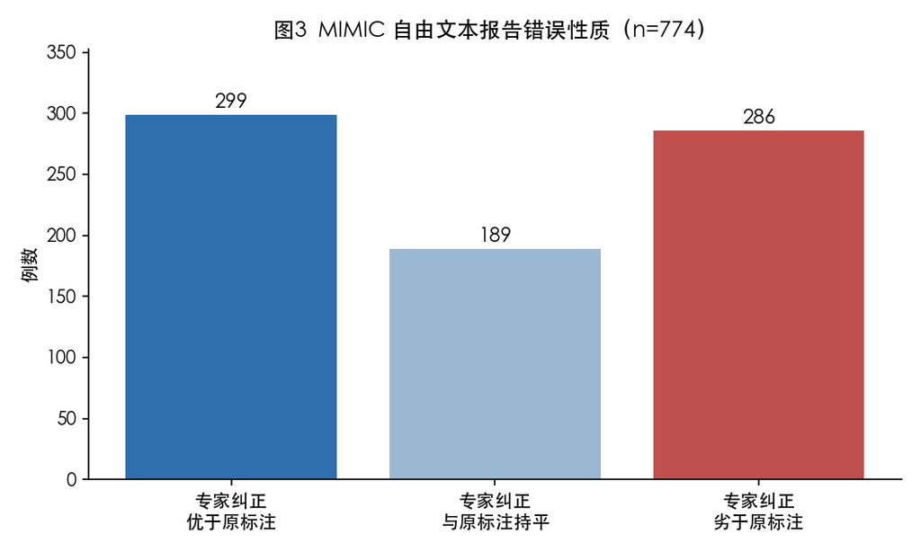

Word 图 4

### 宁波不准确心电图的错误方向构成（n=349）

349 例不准确中：无变化 24、纯漏标 136、纯误标 76、漏标与误标共存 113。以漏标为主，但误标（76 例纯误标 + 113 例共存中的误标成分）占比可观。

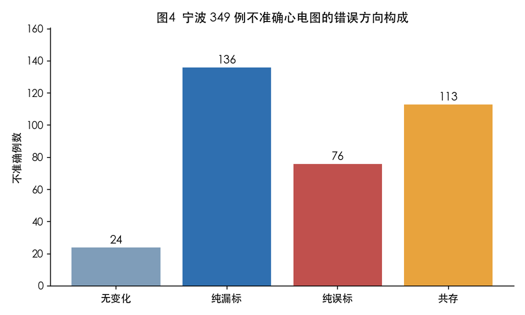

Word 图 5 / 表 16

### 宁波逐诊断标签修订结局（Top 15）

按原始标注例数排序的逐标签修订：蓝为专家保留率、红为被纠正/纯多报率。多数标签保留率偏低，反映宁波原始标签整体偏「过标注 / 命名漂移」。

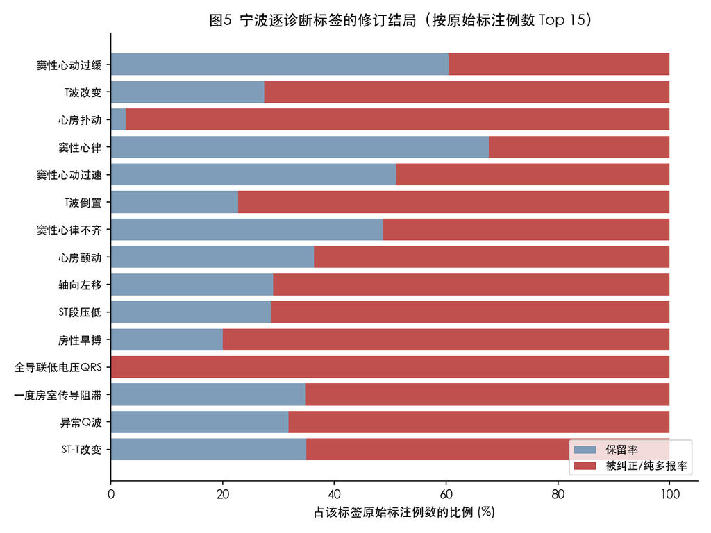

Word 表 1 / 表 6

### 术语标准化与诊断标准差异（参考）

表 1 为 48 项英文标准化诊断术语（国际心电图术语集），表 6 对比明尼苏达编码 / SNOMED / SCP 三种标准的差异。属方法学参考，非本研究审计数据。

| primary diagnostic terminology | primary diagnostic terminology | primary diagnostic terminology |
| --- | --- | --- |
| Overall interpretation | Ventricular arrhythmias | Low voltage |
| Normal ECG | Ventricular premature complex (es) | Low voltage in limb leads |
| Otherwise normal ECG | Ventricular fusion complex (es) | Low voltage in precordial leads |
| Abnormal ECG | Ventricular escape complex (es) | Abnormal precordial R-wave progression |
| Uninterpretable ECG | Accelerated idioventricular rhythm | Abnormal P-wave axis |
| Technical conditions | Fascicular rhythm | Chamber hypertrophy or enlargement |
| Extremity doctored reversal | Ventricular parasystole | Left atrial enlargement |
| Misplaced precordial electrodecss | Pulseless electrical activity | Right atrial enlargement |
| Missing lead (s) | Cardial asystole | Left ventricular hypertrophy |
| Right-slide precordial electrode (s) | Ventricular tachyarrhythmias | Right ventricular hypertrophy |
| Artifact | Ventricular tachycardia | Biventricular hypertrophy |
| Poor-quality data | Ventricular tachycardia unsustained | ST segment，T wave and U wave |
| Posterior electrode (s) | Bidirectional ventricular tachycardia | ST deviation |
| Sinus node rhythms and arrhythmias | Ventricular tachycardia polymorphous | ST deviation with T wave change |
| Sinus rhythm | Ventricular tachycardia torsades de points | T wave abnormality |
| Sinus bradycardia | Ventricular fibrillation | Prolonged QT interval |
| Sinus tachycardia | Fascicular tachycardia | Short QT interval |
| Wandering sinus rhythm | Wide-QRS tachycardia | Prominent U waves |
| Sinoatrial block, type 1 | Atrioventricular (AV) conduction |  |
| Sinus arrhythmia | Short PR interval | Inverted U waves |
| Wandering sinus rhythm | AV conduction ration N:D | TU fusion |
| Sinoatrial block type 1 | First-degree AV block | ST-T change due to ventricular hypertrophy |
| Sinoatrial block type 11 | Second-degree AV block, Mobitz type 1 (wenckebach) | Osborn wave |
| Sinus pause or arrest | Second- degree AV block, mobitz type 11 | Early repolarization |
| Uncertain supraventricular rhythm | 2:1 AV block | Myocardial infarction (MI) |
| Supraventricular arrhythmias | AV block, varying conduction | Anterior MI |
| Atrial premature complex (es) | AV block advanced (high-grade) | Inferior MI |
| Atrial premature complex (es), nonconducted | AV block complete (third degree) | Posterior MI |
| Retrograde atrial activation | AV dissociation | Lateral MI |
| Wandering atrial rhythm | Intraventricular and intra-atrial conduction | Anteroseptal MI |
| Ectopic atrial rhythm | Aberrant conduction of supraventricular beat (s) | Extensive anterior MI |
| Ectopic atrial rhythm, multifold | Left anterior fascicular block | MI in presence of left bundle-branch block |
| Junctional premature complex (es) | Left posterior fascicular block | Right ventricular MI |
| Junctional escape complex (es) | Left bundle-branch bloke | Abnormal Q wave |
| Junctional rhythm | Incomplete right bundle-branch | Pacemaker |
| Accelerated junctional rhythm | Right bundle-branch block | Atrial-paced complex (es) or rhythm |
| Supraventricular rhythm | Intraventricular conduction delay | Ventricular-paced complex (es) or rhythm |
| Supraventricular complex (es) | Ventricular preexcitation | Ventricular pacing of non-right ventricular apical origin |
| Bradycardia nonsinus | Right atrial conduction abnormality | Atrial-sensed ventricular-paced complex (es) of rhythm |
| Supraventricular tachyarrhy thmias | Left atrial conduction abnormality | AV dual-paced complex (es) or rhythm |
| Atrial fibrillation | Epsilon wave | Failure to capture, atrial |
| Atrial flutter | Axis and voltage | Failure to capture, ventricular |
| Ectopic atrial tachycardia unifocal | Right-axis deviation | Failure to inhibit, atrial |
| Ectopic atrial tachycardia multifocal | Left-axis deviation | Failure to inhibit, ventricular |
| Junctional tachycardia | Right superior axis | Failure to peace, atrial |
| Supraventricular tachycardia | Indeterminate axis | Failure to peace, ventricular |
| Narrow-QRS tachycardia | Electrical alternans |  |

| ECG诊断标准差异 | 明尼苏达编码 | SNOMED | SCP |
| --- | --- | --- | --- |
| 定义 | 一种心电图分类系统，通过编码测量值来客观分类波形，避免主观诊断偏差 | 一种全面的临床术语集，每个编码代表一个唯一的“临床概念”，不仅是心电图，还涵盖整个医学领域 | 一种数据通信协议，定义了心电数据的存储和交换“格式”标准-3-5。 |
| 应用 | 流行病学研究和临床试验。用于大规模人群的心电图数据统计，而非临床即时诊断-4-6。 | 电子健康档案。用于临床记录、决策支持、数据检索和不同系统间的语义互通-7。 | 心电设备互联。确保不同厂商的 ECG 设备、分析系统与医院信息系统之间能无障碍地传输原始数据和报告-3-5。 |
| 编码内容 | 采用纯数字代码（如 1-1-1 代表某类病理性Q波），共分9个主要类别，侧重于波形的客观测量结果而非临床诊断-1。 | 采用概念ID + 层级结构。一个ID代表一个临床意义，如 251134003 代表 "General electrocardiographic appearance"，且能通过逻辑关系关联更细化的概念-2-7。 | 将数据打包为多个强制性或可选的数据段，包含原始信号、测量结果、中间分析结果以及最终的诊断描述-3。 |
| 粒度 | 粗粒度。它将连续变化的波形数据强行归入有限的几个“编码篮子”里，便于卡方检验等统计。 | 细粒度。可以用“收缩压=120 mmHg”这样的方式精确记录具体数值。 | 原始粒度。传输的是未经处理的原始信号，以及处理后的高精度测量值，接收方可以完全重新分析。 |
| 结果表达 | “该心电图符合明尼苏达码 4-1 的标准”-1。 | “诊断：急性前壁心肌梗死。 | 可以发送“心电图显示窦性心律，电轴正常”这样的文本报告。 |
| 用户 | 流行病学家、公共卫生研究员、临床试验数据协调中心-4-6。 | 医院信息科、临床医生、医疗数据分析师、AI 辅助诊断开发者-7。 | 心电图机厂商、心电网络系统工程师、远程医疗平台开发者-3-5。 |
| 局限性 | 编码规则固定，缺乏灵活性，难以准确描述复杂波形；需要专门培训才能掌握测量和编码规则-6。 | 过于庞大和复杂，仅用于心电图编码显得有些“大材小用”，且对单一事件的描述粒度不一致。 | 作为“容器”，不规定具体诊断内容，仅定义了内容“怎么放”，不同厂家填充的具体诊断代码（如使用 SNOMED CT）仍可能不一致-3。 |

Word 表 7 / 表 8

### 专家共识 100 例子研究（独立子研究）

表 7 为 100 份心电图的专家共识诊断分类分布，表 8 为专家间不一致条目的金标准判定。属团队另一独立子研究，保留原统计，不并入三库审计主集。

| 诊断分类 | 频数（%） |
| --- | --- |
| 正常心电图 | 10（10.0） |
| 窦性行动过缓 | 9（9.0） |
| 窦性心动过速（包括1例室上速） | 3（3.0） |
| 窦性心律不齐 | 8（8.0） |
| 心房颤动/心房扑动 | 7（7.0） |
| 房性心律 | 1（1.0） |
| 室性期前收缩 | 8（8.0） |
| 房性期前收缩 | 2（2.0） |
| 完全性右束支传导阻滞 | 6（6.0） |
| 不完全性右束支传导阻滞 | 2（2.0） |
| 1度房室传导阻滞（含1例窦房传导阻滞） | 5（5.0） |
| 异常Q波 | 7（7.0） |
| ST-T改变 | 54（54.0） |
| 心电轴异常 | 11（11.0） |
| 心房/心室扩大/高电压 | 9（9.0） |
| 心室起搏心电图 | 1（1.0） |

| 报告不一致心电图条目 | 一致人数 | 诊断差异 | 金标准 |
| --- | --- | --- | --- |
| 报告稍有差异 |  |  |  |
| 窦性心律不齐 | 2 | 窦性心律不齐，大致正常心电图 | 窦性心律不齐 |
| 窦性心律不齐 | 2 | 窦性心律不齐，大致正常心电图 | 窦性心律不齐 |
| 窦性行动过缓 | 2 | 窦性心动过缓，大致正常心电图 | 窦性心律不齐 |
| T波改变 | 2 | T（V1、V2）>T（ V 5、V6） | T波改变 |
| ST段改变 | 2 | ST段J点上移，请结合临床 | ST段改变 |
| 报告不一致心电图 | 2 |  |  |
| 窦性心律心动过缓 | 2 | 窦性心律，ST-T轻微改变 | 窦性心动过缓 |
| 胸导R波递增不良 | 2 | 缺失 | 胸导R波递增不良 |
| 胸导R波递增不良 | 2 | 缺失 | 胸导R波递增不良 |
| 胸导R波递增不良 | 2 | 缺失 | 胸导R波递增不良 |
| 胸导R波递增不良 | 2 | 缺失 | 胸导R波递增不良 |

**与 v1.0 报告已有内容的对应关系**

- **Word 表 9（术语对照）** ↔ 本报告「词汇映射表 / 跨库命名空间对照表」（正文方法学章）。
- **Word 表 10（三库准确性）** ↔ 本报告「表 9 三库汇总表」（TP/FP/FN/TN/qfn/fdr/不准确率）。
- **Word 表 11（逐诊断 Se/Sp）** ↔ 本报告「图 2 逐概念 fdr/qfn」与 Goldman Class 分级结果。
- **Word 图 3/4/5（错误性质/方向/修订）** ↔ 本报告正文「标签错误分类学」相关段落。
- 其余 Word 表 1/2/3/4/5/6 为公开数据库调研与术语标准参考，本报告以「PTB-XL 分布特征」「数据来源」章节覆盖其数据要点。